# chromosomix against reference implementations

Twenty-seven analyses on public data, each run by chromosomix and by the package it reproduces

**Rendered** 30 October 2026, 09:16 UTC · **chromosomix** 0.18.0, release v0.18.0, at [`b1f1a7a`](https://github.com/js2264/chromosomix/commit/b1f1a7a32b15903eac99ca53b75d79aae4f3d03f)  
**By** GitHub Actions, [Notebooks run 13](https://github.com/js2264/chromosomix/actions/runs/41030621424), for its release  
**On** AMD EPYC 9V45 96-Core Processor, 4 cores, 15.6 GB, Linux 7.0.0-1017-azure (x86_64); Python 3.13.17, Quarto 1.10.19

Every command of §§ 1–19 and 24–27 below, run again and timed: [the timings](https://chromosomix.app/timings/). Beside this page: `commands.json`, every command as it ran; `summary.tsv`, every verdict; and `validation.txt`, every number its figures draw.

Each analysis is run on the same public file twice: by **`chromosomix`**, the command-line form of the app’s Analysis panel (the same code), and by the **reference package** it reproduces, called as its authors intend. The two outputs are matched bin by bin or call by call. Every command is printed as it ran, from `notebooks/work/validation/`, and written to `commands.json` there, from which [`timing.qmd`](https://chromosomix.app/timings/) runs each again and times it — those of §§ 20–23 aside, which are compared here and not timed.

Every number a figure draws is one line of **`validation.txt`**, beside `commands.json`: a tidy table, one row per mark — a point, a vertex of a line, a hexagon of a density and its count, a cell of a picture, a bar, a band or a line across a panel, a named tick, a text — with the figure’s label and the panel’s letter, the panel’s axes, what the mark stands for (`series`, as the legend names it) and where it is drawn. It is read off each figure as it is shown, so any figure below can be drawn again from it alone. A density is the hexagons it draws, not the millions of values behind it, which are the outputs of the commands printed above it; a symmetric map’s numbers are written once, its upper triangle; and the metaplot’s heatmaps, tens of thousands of transcripts in a few hundred pixels, draw each line as the mean of 100, which is what is written.

| § | Analysis | Data | Reference |
| --- | --- | --- | --- |
| 1 | Diamond insulation | mouse Hi-C, 10 kb | `cooltools.insulation` |
| 2 | Directionality index | mouse Hi-C, 50 kb | `domaincaller` |
| 3 | Compartments | mouse Hi-C, 100 kb | `cooltools.eigs_cis` |
| 4 | P(s) | yeast Micro-C, 800 bp; mouse Hi-C, 10 kb | `cooltools.expected_cis` |
| 5 | Peak calling | mouse ATAC-seq, two replicates, chr19 | yapc 0.1 with IDR 2.0.3 |
| 6 | Loops | yeast Micro-C, 800 bp | chromosight 1.6.3 |
| 7 | Reproducibility | chicken Hi-C, three maps, 100 kb | hicrep 0.2.6 |
| 8 | 3D model | yeast Micro-C, 12.8 kb | pastis (GitHub `6888ac2`) |
| 9 | Coverage | mouse Hi-C, 10 kb | `cooltools.coverage` |
| 10 | Virtual 4C | mouse Hi-C, 10 kb | `cooltools.virtual4c` |
| 11 | Aggregate peak analysis | mouse Hi-C, 10 kb | coolpuppy |
| 12 | APA, chromosight’s score | mouse Hi-C, 10 kb | `chromosight quantify` |
| 13 | Boost-HiC | mouse Hi-C, 100 kb | Boost-HiC (GitHub `a615aff`) |
| 14 | Metaplot | mouse ATAC-seq, one and two replicates, RefSeq TSS | deepTools `computeMatrix`, `plotProfile`, `plotHeatmap` |
| 15 | Interval overlap | ATAC-seq peaks and promoters, chr19 | bedtools `jaccard`, `intersect`, `shuffle` |
| 16 | Base composition | mm10, 10 kb | `bioframe.frac_gc`, Biopython `GC_skew` |
| 17 | Motif search | mm10, chr19 | `seqkit locate` |
| 18 | Track correlation | mouse ATAC-seq, two replicates, and insulation, chr19, 100 bp to 10 kb | pyBigWig and SciPy; deepTools `multiBigwigSummary`, `plotCorrelation` |
| 19 | Loop calling | mouse Hi-C, 10 kb | `cooltools.dots` |
| 20 | Cis and trans per sequence | chicken Hi-C, 100 kb | `cooltools.expected_cis`, `expected_trans` |
| 21 | Saddle | mouse Hi-C, 100 kb, § 3’s E1 | `cooltools.saddle` |
| 22 | Fraction of signal in features | mouse ATAC-seq, two replicates, chr19; peaks and promoters | pyBigWig and NumPy |
| 23 | Signal by group | mouse ATAC-seq, two replicates, chr19; § 3’s compartments | pyBigWig, NumPy and SciPy |
| 24 | CTCF sites in GM12878 (Fig. 2): insulation at four scales, peaks, APA between consecutive peaks, metaplot | GM12878 Hi-C, 10 kb; CTCF ChIP-seq of two labs and ATAC-seq; chr19 | `cooltools.insulation`; yapc 0.1 with IDR 2.0.3; coolpuppy; deepTools `computeMatrix`, `plotProfile`, `plotHeatmap` |
| 25 | Pairs statistics | yeast Hi-C contact list, 17.6 million pairs | `pairtools stats` 1.1.2 |
| 26 | Restriction sites | yeast reference (R64-1-1), DpnII, 5 kb bins | `bioframe.digest` |
| 27 | Pairs QC | § 25’s contact list against § 26’s sites, 5 kb | `pairtools restrict` and `pairtools stats` 1.1.2, `cooltools.coverage` |

**To render.** `npm run build:cli` at the repository root builds this checkout’s `chromosomix`. yapc needs an environment of its own (numpy < 1.24; the recipe is in the yapc section of `scripts/make_analysis_golden.py`); Boost-HiC is a checkout, beside the repository or named in `BOOSTHIC_DIR`; bedtools and seqkit are programs on the `PATH` (conda, or the system’s packages); the other references share one environment, with SciPy before 1.18, which dropped an argument pastis passes:

```bash
python -m venv refs && . refs/bin/activate
pip install jupyter matplotlib cooler cooltools bioframe pyfaidx pyBigWig 'pandas<3' 'scipy<1.18' \
    chromosight==1.6.3 hicrep==0.2.6 domaincaller==0.1.0 coolpuppy deeptools biopython \
    scikit-learn scikit-image h5py \
    'git+https://github.com/hiclib/pastis@6888ac25ded72ce3e559987b8a31b3f8ed2935ed'
git clone https://github.com/LeopoldC/Boost-HiC ../Boost-HiC
uv venv -p 3.12 pairtools-env && uv pip install -p pairtools-env -r notebooks/requirements-pairtools.txt
QUARTO_PYTHON=refs/bin/python YAPC_PYTHON=yapc-env/bin/python PAIRTOOLS_PYTHON=pairtools-env/bin/python \
    quarto render notebooks/validation.qmd
```

`notebooks/requirements.txt` is that environment at the versions this page was last rendered with, every package pinned, and `requirements-yapc.txt` yapc’s. `.github/workflows/notebooks.yml` installs both and renders this page and the timings on every release, publishing them at https://chromosomix.app/validation/ and https://chromosomix.app/timings/; the block under the title says which render this is.

The data (9.8 GB) are fetched once into `notebooks/work/validation/data/`. Outputs are kept beside them, so a second render reads rather than recomputes (`REDO`).

```python
from pathlib import Path
import os

#: Run a step again even where its outputs are already on disk.
REDO = False
#: Processes for the reference packages that take them: one a core, at most four. Four on two cores are no
#: faster than two, and on a runner of 8 GB they held more memory than it had.
THREADS = min(4, os.cpu_count() or 1)
#: yapc 0.1's interpreter, relative to the repository or absolute.
YAPC_PYTHON = os.environ.get('YAPC_PYTHON', 'yapc-env/bin/python')
#: pairtools 1.1.2's interpreter: an environment of its own, on Python 3.12 or older, since pairtools
#: imports the `pipes` module 3.13 removed.
PAIRTOOLS_PYTHON = os.environ.get('PAIRTOOLS_PYTHON', 'pairtools-env/bin/python')
#: A checkout of LeopoldC/Boost-HiC, relative to the repository or absolute.
BOOSTHIC_DIR = os.environ.get('BOOSTHIC_DIR', '../Boost-HiC')

HERE = Path.cwd().resolve()
REPO = HERE.parent if HERE.name == 'notebooks' else HERE
CLI = REPO / 'dist-cli' / 'chromosomix.mjs'
WORK = REPO / 'notebooks' / 'work' / 'validation'
DATA = WORK / 'data'
SCRIPTS = REPO / 'notebooks' / 'scripts'
#: Every command of this notebook, as timing.qmd runs it again.
MANIFEST = WORK / 'commands.json'
YAPC_PYTHON = Path(YAPC_PYTHON) if Path(YAPC_PYTHON).is_absolute() else REPO / YAPC_PYTHON
PAIRTOOLS_PYTHON = Path(PAIRTOOLS_PYTHON) if Path(PAIRTOOLS_PYTHON).is_absolute() else REPO / PAIRTOOLS_PYTHON
#: The `pairtools` program beside that interpreter.
PAIRTOOLS = str(PAIRTOOLS_PYTHON.parent / 'pairtools')
BOOSTHIC_DIR = Path(BOOSTHIC_DIR) if Path(BOOSTHIC_DIR).is_absolute() else (REPO / BOOSTHIC_DIR).resolve()
```

```python
import hashlib
import html
import json
import re
import shlex
import shutil
import subprocess
import sys
import time
import urllib.parse
import urllib.request
import warnings
from importlib.metadata import version

import cooler
import matplotlib.pyplot as plt
import numpy as np
import pandas as pd
import pyBigWig
from matplotlib.axis import Axis
from matplotlib.collections import PathCollection, PolyCollection
from matplotlib.colors import LinearSegmentedColormap, LogNorm
from matplotlib.image import AxesImage
from matplotlib.legend import Legend
from matplotlib.lines import Line2D
from matplotlib.patches import Rectangle, StepPatch
from matplotlib.spines import Spine
from matplotlib.text import Text
from matplotlib.ticker import FixedLocator
from scipy import stats

warnings.filterwarnings('ignore')
if not CLI.exists():
    raise FileNotFoundError(f'{CLI} is not there: run `npm run build:cli` at the repository root.')
if not (BOOSTHIC_DIR / 'HiCutils.py').exists():
    raise FileNotFoundError(f'{BOOSTHIC_DIR} holds no Boost-HiC: clone LeopoldC/Boost-HiC there, or set BOOSTHIC_DIR.')
DATA.mkdir(parents=True, exist_ok=True)
PYTHON = sys.executable


def tool(name):
    """A program on the PATH, or beside this interpreter where pip put it."""
    return shutil.which(name) or str(Path(PYTHON).parent / name)


CHROMOSIGHT, COMPUTEMATRIX, PLOTPROFILE = tool('chromosight'), tool('computeMatrix'), tool('plotProfile')
PLOTHEATMAP = tool('plotHeatmap')
MULTIBIGWIGSUMMARY, PLOTCORRELATION = tool('multiBigwigSummary'), tool('plotCorrelation')
BEDTOOLS, SEQKIT = tool('bedtools'), tool('seqkit')
#: What a reference's command runs with besides this process's environment.
YAPC_ENV = {'PATH': f'{YAPC_PYTHON.parent}{os.pathsep}{os.environ["PATH"]}'}
BOOSTHIC_ENV = {'BOOSTHIC_DIR': str(BOOSTHIC_DIR)}
# pairtools imports matplotlib, through bioframe, and its environment has no matplotlib-inline, the backend
# the kernel names in MPLBACKEND for every process it starts: it is given the one every matplotlib has.
PAIRTOOLS_ENV = {'MPLBACKEND': 'agg'}


def fetch(url, name=None, md5=None):
    """A public file, fetched once into work/validation/data, and held to `md5` where there is one: a
    file of that name from anywhere else is refused rather than compared."""
    path = DATA / (name or urllib.parse.unquote(url.rsplit('/', 1)[-1]))
    if not path.exists():
        print('fetching', url)
        part = path.with_name(path.name + '.part')
        with urllib.request.urlopen(url) as response, open(part, 'wb') as out:
            shutil.copyfileobj(response, out, 1 << 22)
        part.rename(path)
    if md5 is not None:
        digest = hashlib.md5()
        with open(path, 'rb') as handle:
            for block in iter(lambda: handle.read(1 << 22), b''):
                digest.update(block)
        if digest.hexdigest() != md5:
            raise ValueError(f'{path} is not {url}: its MD5 is {digest.hexdigest()}, not {md5}. '
                             'Delete it, and it is fetched again.')
    return path


def rel(path):
    """A path as the commands give it: a file of this repository relative to work/validation/, where
    they run; any other as it is."""
    path = Path(path)
    return os.path.relpath(path, WORK) if path.is_relative_to(REPO) else str(path)


def arg(value):
    return rel(value) if isinstance(value, Path) else str(value)


def typed(argv):
    """A command as a reader would type it: each tool by its installed name."""
    names = {PYTHON: 'python', str(YAPC_PYTHON): 'yapc-env/bin/python', PAIRTOOLS: 'pairtools',
             CHROMOSIGHT: 'chromosight',
             COMPUTEMATRIX: 'computeMatrix', PLOTPROFILE: 'plotProfile', SEQKIT: 'seqkit',
             MULTIBIGWIGSUMMARY: 'multiBigwigSummary', PLOTCORRELATION: 'plotCorrelation',
             PLOTHEATMAP: 'plotHeatmap'}
    if argv[:2] == ['node', str(CLI)]:
        argv = ['chromosomix', *argv[2:]]
    return shlex.join([names.get(a, a) for a in argv])


#: Every chromosomix command and every reference command, by name: for the summary and the timing.
APP, REFS, NOTES = {}, {}, {}
#: Where a reference writes, in its command; it may be the start of a longer argument.
OUT = '<out>'
#: What each reference last ran, by name: its command and its scripts' content.
STAMPS = WORK / '.stamps'


def mr(task, *args, out, name, analysis, label='', group=None, bench=True):
    """One chromosomix command into `out`, skipped when `out` holds what this same command wrote at
    this same commit of chromosomix — a pileup cached from an older build is the older build's.

    `group` pairs it with the reference commands it is timed against; its label by default."""
    out = Path(out)
    argv = ['node', str(CLI), task, *[arg(a) for a in args]]
    full = argv + ['--out', rel(out)]
    APP[name] = dict(analysis=analysis, tool='chromosomix', label=label, group=label if group is None else group,
                     argv=argv, bench=bench, threads=1, shown=typed(full))
    print('$', typed(full))
    stamp = f'{typed(full)}\n# chromosomix {APP_VERSION}\n'
    held = (out / '.command').read_text() if (out / '.command').exists() else ''
    if REDO or not held.startswith(stamp):
        out.mkdir(parents=True, exist_ok=True)
        start = time.time()
        run = subprocess.run(full, capture_output=True, text=True, cwd=WORK)
        if run.returncode:
            raise RuntimeError(run.stderr[-4000:])
        notes = [line.strip()[len('note: '):] for line in re.split(r'[\r\n]', run.stderr)
                 if line.strip().startswith('note:')]
        (out / '.notes').write_text('\n'.join(notes))
        (out / '.command').write_text(f'{stamp}# {time.time() - start:.1f} s\n')
    NOTES[name] = (out / '.notes').read_text().splitlines()
    return out


def script(name):
    """A reference's script, in notebooks/scripts/: run, printed and timed."""
    path = SCRIPTS / f'{name}.py'
    if not path.exists():
        raise FileNotFoundError(f'{path} is not there.')
    return path
```

```python
def environment(extra):
    """This process's environment with a command's own additions, or None for it as it is."""
    return None if extra is None else dict(os.environ, **extra)


def reference(name, analysis, tool_, argv, out, made=None, env=None, label='', group=None, threads=1,
              bench=True):
    """A reference command, run once for the comparison (skipped when its output is on disk).

    `argv` holds OUT where the command writes, so the timing can send it elsewhere; `env` is what it
    needs besides this environment, and `threads` the processes it was given."""
    argv = [a if isinstance(a, str) and OUT in a else arg(a) for a in argv]
    out = Path(out)
    real = [a.replace(OUT, rel(out)) for a in argv]
    REFS[name] = dict(analysis=analysis, tool=tool_, label=label, group=label if group is None else group,
                      argv=argv, out=out, env=env, bench=bench, threads=threads, shown=typed(real),
                      scripts=[a for a in argv if a.endswith('.py')])
    print('$', typed(real))
    # Run again when the command or a script it runs has changed since it ran, which its stamp says;
    # a result from before there were stamps is kept unless one of its scripts is newer than it.
    target, ran = Path(made or out), STAMPS / f'{name}.command'
    scripts = [(WORK / s).resolve() for s in REFS[name]['scripts']]
    stamp = f"{typed(real)}\n# scripts {hashlib.sha256(b''.join(s.read_bytes() for s in scripts)).hexdigest()[:16]}\n"
    if ran.exists():
        stale = ran.read_text() != stamp
    else:
        stale = target.exists() and any(s.stat().st_mtime > target.stat().st_mtime for s in scripts)
    if REDO or stale or not target.exists():
        out.parent.mkdir(parents=True, exist_ok=True)
        run = subprocess.run(real, capture_output=True, text=True, cwd=WORK, env=environment(env))
        if run.returncode:
            raise RuntimeError(run.stderr[-4000:])
    STAMPS.mkdir(parents=True, exist_ok=True)
    ran.write_text(stamp)
    return out


def table(path):
    """A table chromosomix wrote: its '#' lines are provenance, not data."""
    return pd.read_csv(path, sep='\t', comment='#')


def track_name(name):
    """A bigWig as chromosomix names it in a table it writes, as the app names the track's row: its file's
    name less the `.bw` (`src/annotations/names.ts`). A reference that names it by its file is read
    through this, so that the two meet."""
    return str(name).strip("'").removesuffix('.bw')


def one(folder, pattern):
    """The one file of `folder` matching `pattern`."""
    hits = sorted(Path(folder).glob(pattern))
    if len(hits) != 1:
        raise FileNotFoundError(f'{len(hits)} files match {pattern} in {folder}')
    return hits[0]


def cached(path, compute):
    """A result of this notebook's own, computed once and kept: a table as TSV, an array as NPY."""
    path = Path(path)
    if path.exists() and not REDO:
        return pd.read_csv(path, sep='\t') if path.suffix == '.tsv' else np.load(path)
    value = compute()
    path.parent.mkdir(parents=True, exist_ok=True)
    if path.suffix == '.tsv':
        value.to_csv(path, sep='\t', index=False)
    else:
        np.save(path, value)
    return value


def show(frame, precision=4, **formats):
    """A table without row numbers: the columns named in `formats` their way, the others to `precision`."""
    return frame.style.hide(axis='index').format(formats or None, precision=precision)


def measures(values):
    """Named numbers as a two-column table."""
    return pd.DataFrame(list(values.items()), columns=['measure', 'value']).style.hide(axis='index')


def pearson(a, b):
    ok = np.isfinite(a) & np.isfinite(b)
    return stats.pearsonr(a[ok], b[ok])[0]


def relative_difference(a, b):
    """|a − b| over the larger of the two, cell by cell."""
    return np.abs(a - b) / np.maximum(np.maximum(np.abs(a), np.abs(b)), 1e-300)


def rounded(decimals):
    """How far rounding to `decimals` places moves a number: half the last place, and a hair over it for the
    float the difference is taken in."""
    return 0.5 * 10.0 ** -decimals * (1 + 1e-6)


#: The edges a figure counts differences between two tools in: four to a decade, from 10⁻⁹ to 1.
DIFFERENCE_EDGES = np.logspace(-9, 0, 37)


def differences(values):
    """How many of `values` fall between each two of `DIFFERENCE_EDGES`, as `ax.stairs` draws them: the
    first counts every one below 10⁻⁹, an exact 0 among them. A figure of tens of thousands of cells
    draws, and writes to validation.txt, three dozen counts rather than a point a cell."""
    counts, _ = np.histogram(np.clip(values, DIFFERENCE_EDGES[0], DIFFERENCE_EDGES[-1]), DIFFERENCE_EDGES)
    return counts, DIFFERENCE_EDGES


# Blue is chromosomix, orange the reference.
APP_COLOUR, REF = '#2a78d6', '#eb6834'
INK, INK2, GRID, SURFACE, MISSING = '#0b0b0b', '#52514e', '#e7e6e2', '#fcfcfb', '#efeeea'
DENSITY = LinearSegmentedColormap.from_list(
    'density', ['#cde2fb', '#86b6ef', '#3987e5', '#1c5cab', '#0d366b'])
plt.rcParams.update({
    'figure.facecolor': SURFACE, 'axes.facecolor': SURFACE, 'savefig.facecolor': SURFACE,
    'axes.edgecolor': INK2, 'axes.labelcolor': INK, 'xtick.color': INK2, 'ytick.color': INK2,
    'text.color': INK, 'axes.spines.top': False, 'axes.spines.right': False,
    'axes.grid': True, 'grid.color': GRID, 'grid.linewidth': 0.6, 'axes.axisbelow': True,
    'lines.linewidth': 2, 'font.size': 9, 'axes.titlesize': 10, 'axes.titleweight': 'bold',
    'axes.titlelocation': 'left', 'legend.frameon': False, 'figure.dpi': 110,
})


def identity(ax, lo, hi):
    ax.plot([lo, hi], [lo, hi], color=INK2, lw=1, ls=(0, (4, 3)), zorder=3, gid='identity')


def agreement(ax, x, y, xlabel, ylabel, title, scale='linear'):
    """Every pair of values as a density, against the identity line."""
    ok = np.isfinite(x) & np.isfinite(y)
    if scale == 'log':
        ok &= (x > 0) & (y > 0)
    x, y = x[ok], y[ok]
    ax.hexbin(x, y, gridsize=70, cmap=DENSITY, mincnt=1, bins='log', linewidths=0,
              xscale=scale, yscale=scale)
    identity(ax, min(x.min(), y.min()), max(x.max(), y.max()))
    ax.set(xlabel=xlabel, ylabel=ylabel, title=title)
    ax.text(0.03, 0.97, f'{ok.sum():,} values\nPearson r = {stats.pearsonr(x, y)[0]:.4f}',
            transform=ax.transAxes, va='top', fontsize=8, color=INK2)
```

```python
def square(ax, matrix, title, cmap=DENSITY, norm=None, label=''):
    """A pileup or a map as an image, its colour scale beside it; the scale is returned."""
    image = ax.imshow(matrix, cmap=cmap, norm=norm, interpolation='nearest')
    ax.set(title=title, xticks=[], yticks=[])
    ax.grid(False)
    return plt.colorbar(image, ax=ax, shrink=0.8, label=label)


TEXT = {}
SUMMARY = []


def commands(lines):
    return '<pre>' + html.escape('\n'.join(lines)) + '</pre>'


def record(task, data, reference_, agreement_, verdict, apps, refs):
    """One row of the summary, with the commands as they ran."""
    SUMMARY.append({'§': len(SUMMARY) + 1, 'Analysis': task, 'Data': data,
                    'chromosomix command': commands([f'$ {APP[name]["shown"]}' for name in apps]),
                    'Reference': reference_,
                    'Reference command': commands([f'$ {REFS[name]["shown"]}' for name in refs]),
                    'Agreement': agreement_, 'Verdict': verdict})


#: Every number each figure draws, by the figure's label on this page: the rows of validation.txt.
DRAWN = {}
#: validation.txt's columns, in order: the figure and its panel, the panel's axes, what is drawn, where,
#: and what it says.
DRAWN_COLUMNS = ['figure', 'panel', 'x_axis', 'y_axis', 'series', 'mark', 'x', 'x_end', 'y', 'value', 'text']


def words(text):
    """A label or a text on one line, as a cell of a table holds it."""
    return ' '.join(str(text).split())


def floats(values):
    """Values as floats, NaN where a masked array hides one: a copy, never the figure's own array."""
    return np.ma.filled(np.ma.array(values, dtype=float, copy=True), np.nan)


def marks(ax):
    """What one panel draws, a frame for each thing drawn: see `drawn`."""
    # A histogram is one thing drawn as many bars, and named once: on its first bar, for the legend.
    held = {}
    for container in ax.containers:
        given = [n for n in (container.get_label(), *(bar.get_label() for bar in container)) if n and n[0] != '_']
        held.update(dict.fromkeys(container, given[0] if given else ''))
    texts = set(ax.texts)

    def name(artist):
        given = artist.get_gid() or held.get(artist) or artist.get_label() or ''
        return '' if given.startswith('_') else words(given)

    def frame(mark, series, **columns):
        arrays = {k: v for k, v in columns.items() if np.ndim(v)}
        out = pd.DataFrame(arrays) if arrays else pd.DataFrame(index=[0])
        return out.assign(mark=mark, series=series, **{k: v for k, v in columns.items() if not np.ndim(v)})

    def unread(artist):
        return TypeError(f'validation.txt cannot read the {type(artist).__name__} a figure draws: teach marks() to, '
                         'or the table is no longer every number the figures draw.')

    out = []
    for artist in ax.get_children():
        if isinstance(artist, Line2D):
            x, y = floats(artist.get_xdata()), floats(artist.get_ydata())
            where = artist.get_transform()
            if where == ax.transData:
                out.append(frame('line', name(artist), x=x, y=y))
            elif where == ax.get_yaxis_transform():
                out.append(frame('rule', name(artist), y=y[0]))
            elif where == ax.get_xaxis_transform():
                out.append(frame('rule', name(artist), x=x[0]))
            else:
                raise unread(artist)
        elif isinstance(artist, PolyCollection) and artist.get_array() is not None:
            # hexbin's centres are in log10 along a log axis.
            centre = floats(artist.get_offsets())
            for k, scale in enumerate((ax.get_xscale(), ax.get_yscale())):
                if scale == 'log':
                    centre[:, k] = 10 ** centre[:, k]
            out.append(frame('hexagon', name(artist), x=centre[:, 0], y=centre[:, 1],
                             value=floats(artist.get_array())))
        elif isinstance(artist, PathCollection):
            at = floats(artist.get_offsets()).reshape(-1, 2)
            out.append(frame('point', name(artist), x=at[:, 0], y=at[:, 1]))
        elif isinstance(artist, AxesImage):
            values = floats(artist.get_array())
            i, j = np.indices(values.shape)
            keep = np.ones(values.shape, bool)
            if values.shape[0] == values.shape[1] and np.array_equal(values, values.T, equal_nan=True):
                keep &= i <= j
            if artist.cmap.get_bad()[3] == 0:
                keep &= np.isfinite(values)
            left, right, bottom, top = artist.get_extent()
            first, last = (top, bottom) if artist.origin == 'upper' else (bottom, top)
            out.append(frame('cell', name(artist), x=left + (j[keep] + 0.5) * (right - left) / values.shape[1],
                             y=first + (i[keep] + 0.5) * (last - first) / values.shape[0], value=values[keep]))
        elif isinstance(artist, StepPatch):
            steps, edges, _ = artist.get_data()
            out.append(frame('step', name(artist), x=floats(edges[:-1]), x_end=floats(edges[1:]),
                             y=floats(steps)))
        elif isinstance(artist, Rectangle) and artist is not ax.patch:
            where, x = artist.get_data_transform(), artist.get_x()
            if where == ax.transData:
                out.append(frame('bar', name(artist), x=x, x_end=x + artist.get_width(),
                                 y=artist.get_y() + artist.get_height()))
            elif where == ax.get_xaxis_transform():
                out.append(frame('band', name(artist), x=x, x_end=x + artist.get_width()))
            else:
                raise unread(artist)
        elif artist in texts:
            out.append(frame('text', name(artist), text=words(artist.get_text())))
        # What is left draws no number — the axes themselves, their titles, the legend, the background —
        # or draws numbers this does not know how to read, which is not to be passed over in silence.
        elif not isinstance(artist, (Axis, Legend, Spine, Text)) and artist is not ax.patch:
            raise unread(artist)
    # Ticks placed by hand are the ones that name something: a chromosome, a pileup, a track.
    for axis, key in ((ax.xaxis, 'x'), (ax.yaxis, 'y')):
        if isinstance(axis.get_major_locator(), FixedLocator):
            at = axis.get_ticklocs()
            out.append(frame('tick', '', **{key: floats(at)},
                             text=[words(t) for t in axis.get_major_formatter().format_ticks(at)]))
    return out
```

```python
def drawn(label):
    """Show the figure just drawn, and keep every number it draws under `label`, its label on this page:
    validation.txt, a row a mark, panel by panel in the order drawn.

    A mark is a `point`; a vertex of a `line`, in order, a gap where it has no y; a `hexagon` of a
    density, at its centre, its count the value; a `cell` of a picture, at its centre, its number the
    value — a symmetric map's upper triangle only, as it draws each of those numbers twice, and no cell it
    leaves transparent; a `bar` or a `step`, from x to x_end, y high; a `band` from x to x_end, and a
    `rule` at x or at y, across the panel; a `tick` naming a place on an axis; and a `text` written in
    the panel. Its series is what it stands for: the legend's name for it, or the name the code gives it
    (`gid`)."""
    frames = []
    for ax in plt.gcf().axes:
        if ax.get_label() == '<colorbar>':
            continue
        title = ax.get_title('left') or ax.get_title()
        letter = re.match(r'([a-z]) {2}', title)
        frames += [part.assign(figure=label, panel=letter.group(1) if letter else words(title),
                               x_axis=words(ax.get_xlabel()), y_axis=words(ax.get_ylabel())) for part in marks(ax)]
    DRAWN[label] = pd.concat(frames, ignore_index=True).reindex(columns=DRAWN_COLUMNS)
    plt.show()
```

## Data and versions

Every file is public, read by its accession and fetched from the URL listed. 4DN files come from the 4DN Data Portal’s open-data bucket on AWS; the mm10 sequence, used to phase compartments by GC content and read for composition and motifs, and the RefSeq genes, for the metaplot’s TSS and the promoters, are UCSC’s as distributed by Illumina iGenomes; the yeast Micro-C map is GEO’s GSE151553, fetched from GEO; § 24’s ChIP-seq and ATAC-seq of GM12878 are ENCODE’s, from its open-data bucket, and its map is 4DN’s, of which only what § 24 reads is fetched, by range; the yeast Hi-C contact list of § 25 is the one the chromosomix demo keeps on its bucket, as pairtools wrote it; and the yeast reference of §§ 26 and 27 is Ensembl’s R64-1-1, whose sequences are the contact list’s, by name and by length. Seven are also held to an MD5, and a file of any of those names that does not match is refused rather than compared: the yeast map, 4DN’s insulation score for § 18, to the MD5 4DN publishes for it, ENCODE’s three tracks, to theirs, the contact list, and the yeast reference, which also matches the checksum Ensembl publishes beside it.

```python
FOURDN = 'https://4dn-open-data-public.s3.amazonaws.com/fourfront-webprod/wfoutput'
IGENOMES = 'https://ngi-igenomes.s3.amazonaws.com/igenomes/Mus_musculus/UCSC/mm10'
GEO = 'https://ftp.ncbi.nlm.nih.gov/geo/series'
ENCODE = 'https://encode-public.s3.amazonaws.com'
DATASETS = [
    dict(data='Mouse Hi-C (mm10)', accession='4DNFIOZ1TRUS', source='4DN',
         url=f'{FOURDN}/727b405d-c9f5-4b13-ae58-1dbf29d19a8f/4DNFIOZ1TRUS.mcool'),
    dict(data='Yeast Micro-C, G2/M (Costantino et al. 2020)', accession='GSE151553', source='GEO',
         url=f'{GEO}/GSE151nnn/GSE151553/suppl/GSE151553_A364_merged.mcool', md5='319a04a8d7e41d9eb88e2378ea3ea373'),
    dict(data='Chicken Hi-C (galGal5)', accession='4DNFIH8L6WON', source='4DN',
         url=f'{FOURDN}/4e321fa9-1abe-48e6-9920-bcf88ee3b8ce/4DNFIH8L6WON.mcool'),
    dict(data='Chicken Hi-C (galGal5)', accession='4DNFITBCUX56', source='4DN',
         url=f'{FOURDN}/f96ea651-4950-41c4-b172-06f33577347d/4DNFITBCUX56.mcool'),
    dict(data='Chicken Hi-C (galGal5)', accession='4DNFIIML46E5', source='4DN',
         url=f'{FOURDN}/4bc15ed0-155b-4a16-b433-130c1daf4a0f/4DNFIIML46E5.mcool'),
    dict(data='Mouse ATAC-seq (mm10), replicate 1', accession='4DNFIIY4QW2D', source='4DN',
         url=f'{FOURDN}/7fb6d419-a8de-4bc8-9c17-f68f814496a2/4DNFIIY4QW2D.bw'),
    dict(data='Mouse ATAC-seq (mm10), replicate 2', accession='4DNFITBRHVZE', source='4DN',
         url=f'{FOURDN}/e567a80e-c7d2-41ff-b12d-67047906c076/4DNFITBRHVZE.bw'),
    dict(data='Mouse ES-cell Hi-C, insulation score (mm10; Bonev et al. 2017)', accession='4DNFIUJ5CJVN', source='4DN',
         url=f'{FOURDN}/dfe47343-08e7-48aa-ac1e-7cfbef055ded/4DNFIUJ5CJVN.bw', md5='66c3c8c6e8351aaff6eeab4767a72b66'),
    dict(data='Mouse genome sequence (Illumina iGenomes copy)', accession='mm10', source='UCSC', name='mm10.fa',
         url=f'{IGENOMES}/Sequence/WholeGenomeFasta/genome.fa'),
    dict(data='Mouse RefSeq genes (Illumina iGenomes copy)', accession='refGene', source='UCSC mm10',
         name='mm10.genes.gtf', url=f'{IGENOMES}/Annotation/Genes/genes.gtf'),
    dict(data='GM12878 CTCF ChIP-seq, fold change over control (GRCh38; Bernstein lab, ENCSR000AKB)',
         accession='ENCFF734CUT', source='ENCODE', md5='b68aeffbebeae3d03e734b51f43c0cb8',
         url=f'{ENCODE}/2020/10/01/a42c46dc-c33f-4906-8469-ba93e2cf30d3/ENCFF734CUT.bigWig'),
    dict(data='GM12878 CTCF ChIP-seq, fold change over control (GRCh38; Stamatoyannopoulos lab, ENCSR000DRZ)',
         accession='ENCFF644EEX', source='ENCODE', md5='0404a4c8f2ea76f528bb5306d2431a11',
         url=f'{ENCODE}/2020/09/26/03eeca15-17a9-47ac-aa63-08d471c2e25d/ENCFF644EEX.bigWig'),
    dict(data='GM12878 ATAC-seq, fold change over control (GRCh38; ENCSR095QNB)', accession='ENCFF487LOB',
         source='ENCODE', md5='f95a4eeec1156e2e1dc392ab988ae28a',
         url=f'{ENCODE}/2021/02/24/4c49a77a-edb2-4766-8328-d44ebe7446eb/ENCFF487LOB.bigWig'),
    dict(data='Yeast Hi-C contact list, as pairtools wrote it', accession='CH128', source='chromosomix demo',
         url='https://rsglab-data.s3.eu-west-3.amazonaws.com/demo/yeast/CH128.pairs.gz',
         md5='e3e37117383283da0c8e57f4e0837699'),
    dict(data='Yeast genome sequence, S288C (R64-1-1)', accession='R64-1-1', source='Ensembl 112',
         url='https://ftp.ensembl.org/pub/release-112/fasta/saccharomyces_cerevisiae/dna/'
             'Saccharomyces_cerevisiae.R64-1-1.dna.toplevel.fa.gz', md5='5ae49d2d22cd977abdd6b054b94c544d'),
]
PATHS = {d['accession']: fetch(d['url'], d.get('name'), d.get('md5')) for d in DATASETS}
MOUSE, YEAST, MM10, GENES = PATHS['4DNFIOZ1TRUS'], PATHS['GSE151553'], PATHS['mm10'], PATHS['refGene']
CH128 = PATHS['CH128']
CHICKEN = [PATHS[a] for a in ('4DNFIH8L6WON', '4DNFITBCUX56', '4DNFIIML46E5')]
ATAC = [PATHS[a] for a in ('4DNFIIY4QW2D', '4DNFITBRHVZE')]
# mm10's index, by which every tool reads the sequence by range: made once, beside it.
import pyfaidx
pyfaidx.Faidx(str(MM10)).close()

show(pd.DataFrame([{'data': d['data'], 'accession': f"{d['source']} {d['accession']}",
                    'MB': PATHS[d['accession']].stat().st_size / 1e6, 'URL': d['url']} for d in DATASETS]),
     MB='{:,.0f}')
```

```
fetching https://4dn-open-data-public.s3.amazonaws.com/fourfront-webprod/wfoutput/727b405d-c9f5-4b13-ae58-1dbf29d19a8f/4DNFIOZ1TRUS.mcool
fetching https://ftp.ncbi.nlm.nih.gov/geo/series/GSE151nnn/GSE151553/suppl/GSE151553_A364_merged.mcool
fetching https://4dn-open-data-public.s3.amazonaws.com/fourfront-webprod/wfoutput/4e321fa9-1abe-48e6-9920-bcf88ee3b8ce/4DNFIH8L6WON.mcool
fetching https://4dn-open-data-public.s3.amazonaws.com/fourfront-webprod/wfoutput/f96ea651-4950-41c4-b172-06f33577347d/4DNFITBCUX56.mcool
fetching https://4dn-open-data-public.s3.amazonaws.com/fourfront-webprod/wfoutput/4bc15ed0-155b-4a16-b433-130c1daf4a0f/4DNFIIML46E5.mcool
fetching https://4dn-open-data-public.s3.amazonaws.com/fourfront-webprod/wfoutput/7fb6d419-a8de-4bc8-9c17-f68f814496a2/4DNFIIY4QW2D.bw
fetching https://4dn-open-data-public.s3.amazonaws.com/fourfront-webprod/wfoutput/e567a80e-c7d2-41ff-b12d-67047906c076/4DNFITBRHVZE.bw
fetching https://4dn-open-data-public.s3.amazonaws.com/fourfront-webprod/wfoutput/dfe47343-08e7-48aa-ac1e-7cfbef055ded/4DNFIUJ5CJVN.bw
fetching https://ngi-igenomes.s3.amazonaws.com/igenomes/Mus_musculus/UCSC/mm10/Sequence/WholeGenomeFasta/genome.fa
fetching https://ngi-igenomes.s3.amazonaws.com/igenomes/Mus_musculus/UCSC/mm10/Annotation/Genes/genes.gtf
fetching https://encode-public.s3.amazonaws.com/2020/10/01/a42c46dc-c33f-4906-8469-ba93e2cf30d3/ENCFF734CUT.bigWig
fetching https://encode-public.s3.amazonaws.com/2020/09/26/03eeca15-17a9-47ac-aa63-08d471c2e25d/ENCFF644EEX.bigWig
fetching https://encode-public.s3.amazonaws.com/2021/02/24/4c49a77a-edb2-4766-8328-d44ebe7446eb/ENCFF487LOB.bigWig
fetching https://rsglab-data.s3.eu-west-3.amazonaws.com/demo/yeast/CH128.pairs.gz
fetching https://ftp.ensembl.org/pub/release-112/fasta/saccharomyces_cerevisiae/dna/Saccharomyces_cerevisiae.R64-1-1.dna.toplevel.fa.gz
```

| data | accession | MB | URL |
| --- | --- | --- | --- |
| Mouse Hi-C (mm10) | 4DN 4DNFIOZ1TRUS | 691 | https://4dn-open-data-public.s3.amazonaws.com/fourfront-webprod/wfoutput/727b405d-c9f5-4b13-ae58-1dbf29d19a8f/4DNFIOZ1TRUS.mcool |
| Yeast Micro-C, G2/M (Costantino et al. 2020) | GEO GSE151553 | 123 | https://ftp.ncbi.nlm.nih.gov/geo/series/GSE151nnn/GSE151553/suppl/GSE151553_A364_merged.mcool |
| Chicken Hi-C (galGal5) | 4DN 4DNFIH8L6WON | 725 | https://4dn-open-data-public.s3.amazonaws.com/fourfront-webprod/wfoutput/4e321fa9-1abe-48e6-9920-bcf88ee3b8ce/4DNFIH8L6WON.mcool |
| Chicken Hi-C (galGal5) | 4DN 4DNFITBCUX56 | 183 | https://4dn-open-data-public.s3.amazonaws.com/fourfront-webprod/wfoutput/f96ea651-4950-41c4-b172-06f33577347d/4DNFITBCUX56.mcool |
| Chicken Hi-C (galGal5) | 4DN 4DNFIIML46E5 | 130 | https://4dn-open-data-public.s3.amazonaws.com/fourfront-webprod/wfoutput/4bc15ed0-155b-4a16-b433-130c1daf4a0f/4DNFIIML46E5.mcool |
| Mouse ATAC-seq (mm10), replicate 1 | 4DN 4DNFIIY4QW2D | 958 | https://4dn-open-data-public.s3.amazonaws.com/fourfront-webprod/wfoutput/7fb6d419-a8de-4bc8-9c17-f68f814496a2/4DNFIIY4QW2D.bw |
| Mouse ATAC-seq (mm10), replicate 2 | 4DN 4DNFITBRHVZE | 735 | https://4dn-open-data-public.s3.amazonaws.com/fourfront-webprod/wfoutput/e567a80e-c7d2-41ff-b12d-67047906c076/4DNFITBRHVZE.bw |
| Mouse ES-cell Hi-C, insulation score (mm10; Bonev et al. 2017) | 4DN 4DNFIUJ5CJVN | 8 | https://4dn-open-data-public.s3.amazonaws.com/fourfront-webprod/wfoutput/dfe47343-08e7-48aa-ac1e-7cfbef055ded/4DNFIUJ5CJVN.bw |
| Mouse genome sequence (Illumina iGenomes copy) | UCSC mm10 | 2,780 | https://ngi-igenomes.s3.amazonaws.com/igenomes/Mus_musculus/UCSC/mm10/Sequence/WholeGenomeFasta/genome.fa |
| Mouse RefSeq genes (Illumina iGenomes copy) | UCSC mm10 refGene | 95 | https://ngi-igenomes.s3.amazonaws.com/igenomes/Mus_musculus/UCSC/mm10/Annotation/Genes/genes.gtf |
| GM12878 CTCF ChIP-seq, fold change over control (GRCh38; Bernstein lab, ENCSR000AKB) | ENCODE ENCFF734CUT | 373 | https://encode-public.s3.amazonaws.com/2020/10/01/a42c46dc-c33f-4906-8469-ba93e2cf30d3/ENCFF734CUT.bigWig |
| GM12878 CTCF ChIP-seq, fold change over control (GRCh38; Stamatoyannopoulos lab, ENCSR000DRZ) | ENCODE ENCFF644EEX | 307 | https://encode-public.s3.amazonaws.com/2020/09/26/03eeca15-17a9-47ac-aa63-08d471c2e25d/ENCFF644EEX.bigWig |
| GM12878 ATAC-seq, fold change over control (GRCh38; ENCSR095QNB) | ENCODE ENCFF487LOB | 870 | https://encode-public.s3.amazonaws.com/2021/02/24/4c49a77a-edb2-4766-8328-d44ebe7446eb/ENCFF487LOB.bigWig |
| Yeast Hi-C contact list, as pairtools wrote it | chromosomix demo CH128 | 1,542 | https://rsglab-data.s3.eu-west-3.amazonaws.com/demo/yeast/CH128.pairs.gz |
| Yeast genome sequence, S288C (R64-1-1) | Ensembl 112 R64-1-1 | 4 | https://ftp.ensembl.org/pub/release-112/fasta/saccharomyces_cerevisiae/dna/Saccharomyces_cerevisiae.R64-1-1.dna.toplevel.fa.gz |

```python
def commit(where):
    run = subprocess.run(['git', 'rev-parse', '--short', 'HEAD'], capture_output=True, text=True, cwd=where)
    return run.stdout.strip() or 'unknown'


def yapc_versions():
    probe = 'import importlib.metadata as m; print(m.version("yapc"), m.version("idr"), m.version("numpy"))'
    try:
        run = subprocess.run([str(YAPC_PYTHON), '-c', probe], capture_output=True, text=True)
        return run.stdout.split() if run.returncode == 0 else ['?'] * 3
    except FileNotFoundError:
        return ['not found'] * 3


def program_version(argv, pattern=r'v?([\d.]+)', env=None):
    """A program's version, as it prints it."""
    run = subprocess.run(argv, capture_output=True, text=True, env=environment(env))
    found = re.search(pattern, run.stdout + run.stderr)
    return found.group(1) if found else '?'


APP_VERSION = f"{json.loads((REPO / 'package.json').read_text())['version']} at {commit(REPO)}"
YAPC, IDR, YAPC_NUMPY = yapc_versions()
PAIRTOOLS_VERSION = (program_version([PAIRTOOLS, '--version'], r'version ([\d.]+)', env=PAIRTOOLS_ENV)
                     if Path(PAIRTOOLS).exists() else 'not found')
VERSIONS = {name: version(name) for name in (
    'cooler', 'cooltools', 'bioframe', 'chromosight', 'hicrep', 'domaincaller', 'pastis', 'coolpuppy',
    'deeptools', 'pyBigWig', 'biopython', 'pyfaidx', 'numpy', 'scipy', 'pandas')}
PROGRAMS = {'bedtools': program_version([BEDTOOLS, '--version']),
            'seqkit': program_version([SEQKIT, 'version']),
            'Boost-HiC (GitHub)': commit(BOOSTHIC_DIR)}
#: Each reference by the name its commands give, with its version: for the summary and the timing.
TOOL_VERSIONS = {'chromosomix': APP_VERSION, 'yapc 0.1': f'{YAPC}, with idr {IDR}',
                 'Boost-HiC': PROGRAMS['Boost-HiC (GitHub)'], 'deepTools': VERSIONS['deeptools'],
                 'bioframe, Biopython': f"{VERSIONS['bioframe']}, {VERSIONS['biopython']}",
                 'pyBigWig, NumPy': f"{VERSIONS['pyBigWig']}, {VERSIONS['numpy']}",
                 'pyBigWig, SciPy': f"{VERSIONS['pyBigWig']}, {VERSIONS['scipy']}",
                 'pairtools': PAIRTOOLS_VERSION,
                 **VERSIONS, **PROGRAMS}
show(pd.DataFrame([{'package': 'chromosomix', 'version': APP_VERSION},
                   *[{'package': k, 'version': v} for k, v in VERSIONS.items()],
                   *[{'package': k, 'version': v} for k, v in PROGRAMS.items()],
                   {'package': 'yapc (own environment)', 'version': f'{YAPC}, with idr {IDR} and numpy {YAPC_NUMPY}'},
                   {'package': 'pairtools (own environment)', 'version': PAIRTOOLS_VERSION}]))
```

| package | version |
| --- | --- |
| chromosomix | 0.18.0 at b1f1a7a |
| cooler | 0.10.4 |
| cooltools | 0.7.1 |
| bioframe | 0.8.0 |
| chromosight | 1.6.3 |
| hicrep | 0.2.6 |
| domaincaller | 0.1.0 |
| pastis | 0.5.0 |
| coolpuppy | 1.1.0 |
| deeptools | 4.0.0 |
| pyBigWig | 0.3.26 |
| biopython | 1.88 |
| pyfaidx | 0.9.0.4 |
| numpy | 2.5.4 |
| scipy | 1.16.3 |
| pandas | 2.3.3 |
| bedtools | 2.31.1 |
| seqkit | 2.3.0 |
| Boost-HiC (GitHub) | a615aff |
| yapc (own environment) | 0.1, with idr 2.0.3 and numpy 1.23.5 |
| pairtools (own environment) | 1.1.2 |

The RefSeq annotation as transcripts: each one’s extent over its exons, on its sequence and strand. The metaplot reads their TSS, the overlap their promoters, and virtual 4C its viewpoints from them.

```python
def refseq_transcripts():
    gtf = pd.read_csv(GENES, sep='\t', header=None, comment='#',
                      names=['chrom', 'source', 'feature', 'start', 'end', 'score', 'strand', 'frame', 'attributes'])
    exons = gtf[gtf['feature'] == 'exon'].copy()
    for key in ('transcript_id', 'gene_name'):
        exons[key] = exons['attributes'].str.extract(rf'{key} "([^"]+)"', expand=False)
    out = (exons.groupby(['transcript_id', 'gene_name', 'chrom', 'strand'])
           .agg(start=('start', 'min'), end=('end', 'max')).reset_index()
           .rename(columns={'transcript_id': 'transcript', 'gene_name': 'gene'}))
    out['start'] -= 1  # GTF is 1-based and closed, BED 0-based and half-open
    out['score'] = 0
    return out.sort_values(['chrom', 'start', 'end', 'transcript'])[
        ['chrom', 'start', 'end', 'transcript', 'score', 'strand', 'gene']]


TRANSCRIPTS = cached(WORK / 'genes' / 'transcripts.tsv', refseq_transcripts)
TSS = np.where(TRANSCRIPTS['strand'] == '+', TRANSCRIPTS['start'], TRANSCRIPTS['end'] - 1)
BED6 = ['chrom', 'start', 'end', 'transcript', 'score', 'strand']
measures({'transcripts': f'{len(TRANSCRIPTS):,}', 'genes': f"{TRANSCRIPTS['gene'].nunique():,}",
          'sequences': f"{TRANSCRIPTS['chrom'].nunique()}"})
```

| measure | value |
| --- | --- |
| transcripts | 35,119 |
| genes | 24,421 |
| sequences | 36 |

## 1 · Diamond insulation

cooltools’ definition: per bin, the mean of the valid cells of the `window × window` square on its diagonal pixel, the `ignoreDiags` nearest diagonals left out, over the chromosome’s median, in log2; boundaries at the minima whose prominence reaches the threshold.

|  | chromosomix | cooltools |
| --- | --- | --- |
| window | `--window 10` (100 kb) | `window_bp=[100_000]` |
| diagonals left out | `--ignoreDiags 2` (default) | `ignore_diags=2` |
| least valid share of a diamond | `--minValid 0.5` (default) | `min_frac_valid_pixels=0.5` |
| boundary threshold | `--prominence 0.2` (default) | `threshold=0.2` |

```python
INS = WORK / 'insulation'
MOUSE_10K = f'{rel(MOUSE)}::/resolutions/10000'
mr('insulation', MOUSE_10K, '--window', 10, out=INS / 'app', name='insulation', analysis='Diamond insulation')
reference('cooltools-insulation', 'Diamond insulation', 'cooltools',
          [PYTHON, script('cooltools_insulation'), MOUSE_10K, OUT, THREADS], out=INS / 'cooltools.tsv', threads=THREADS)

clr10 = cooler.Cooler(f'{MOUSE}::/resolutions/10000')
bins10 = clr10.bins()[:]
ref_ins = pd.read_csv(INS / 'cooltools.tsv', sep='\t')
app_ins = table(one(INS / 'app', '*.insulation-w10.tsv'))
assert (app_ins['bin'].to_numpy() == np.arange(len(bins10))).all()
a_ins = app_ins['value'].to_numpy(float)
b_ins = ref_ins['log2_insulation_score_100000'].to_numpy(float)
both = np.isfinite(a_ins) & np.isfinite(b_ins)
ins_diff = np.abs(a_ins[both] - b_ins[both])

app_b = table(one(INS / 'app', '*.insulation-boundaries.tsv'))
ref_b = ref_ins.loc[ref_ins['is_boundary_100000'].astype(bool), ['chrom', 'start', 'boundary_strength_100000']]
calls = app_b[['chrom', 'start', 'score']].merge(ref_b, on=['chrom', 'start'], how='outer', indicator=True)
same_calls = calls[calls['_merge'] == 'both']
strength_diff = np.abs(same_calls['score'] - same_calls['boundary_strength_100000'])
measures({
    'bins both score': f'{both.sum():,}',
    'bins only one scores': f'{int((np.isfinite(a_ins) != np.isfinite(b_ins)).sum()):,}',
    'score, max |difference|': f'{ins_diff.max():.1e}',
    'boundaries, chromosomix / cooltools': f'{len(app_b):,} / {len(ref_b):,}',
    'boundaries at the same bin': f'{len(same_calls):,}',
    'boundary strength, max |difference|': f'{strength_diff.max():.1e}',
})
```

```
$ chromosomix insulation data/4DNFIOZ1TRUS.mcool::/resolutions/10000 --window 10 --out insulation/app
$ python ../../scripts/cooltools_insulation.py data/4DNFIOZ1TRUS.mcool::/resolutions/10000 insulation/cooltools.tsv 4
```

| measure | value |
| --- | --- |
| bins both score | 250,342 |
| bins only one scores | 0 |
| score, max \|difference\| | 5.1e-06 |
| boundaries, chromosomix / cooltools | 11,089 / 11,089 |
| boundaries at the same bin | 11,089 |
| boundary strength, max \|difference\| | 5.1e-06 |

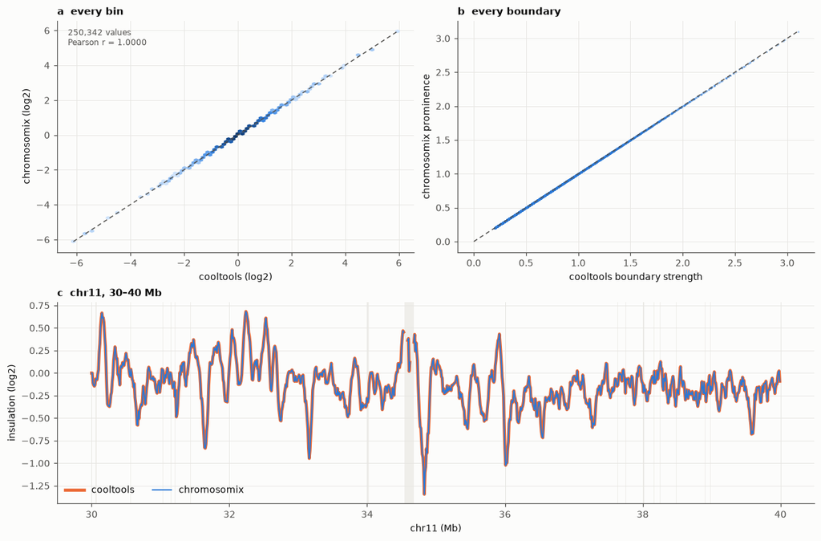

Figure 1: Diamond insulation, 100 kb window. a, every bin; b, every boundary both call; c, chr11, 30–40 Mb (dropped bins shaded).

```python
TEXT['ins_n'] = f'{both.sum():,}'
TEXT['ins_max'] = f'{ins_diff.max():.1e}'
TEXT['ins_calls'] = f'{len(same_calls):,}'
TEXT['ins_only'] = f"{int((calls['_merge'] != 'both').sum())}"
TEXT['ins_strength'] = f'{strength_diff.max():.1e}'

fig = plt.figure(figsize=(11, 7.2), layout='constrained')
grid = fig.add_gridspec(2, 2, height_ratios=[1.15, 1])
agreement(fig.add_subplot(grid[0, 0]), b_ins[both], a_ins[both], 'cooltools (log2)', 'chromosomix (log2)',
          'a  every bin')
ax = fig.add_subplot(grid[0, 1])
ax.scatter(same_calls['boundary_strength_100000'], same_calls['score'], s=4, color=APP_COLOUR, alpha=0.35, lw=0,
           rasterized=True)
identity(ax, 0, same_calls['boundary_strength_100000'].max())
ax.set(xlabel='cooltools boundary strength', ylabel='chromosomix prominence', title='b  every boundary')
ax = fig.add_subplot(grid[1, :])
lo, _ = clr10.extent('chr11')
stretch = slice(lo + 3_000, lo + 4_000)
x = bins10['start'].to_numpy()[stretch] / 1e6
for pos in x[~np.isfinite(bins10['weight'].to_numpy(float)[stretch])]:
    ax.axvspan(pos, pos + 0.01, color=MISSING, lw=0, zorder=0, gid='dropped bin')
ax.plot(x, b_ins[stretch], color=REF, lw=3, label='cooltools')
ax.plot(x, a_ins[stretch], color=APP_COLOUR, lw=1.2, label='chromosomix')
ax.set(xlabel='chr11 (Mb)', ylabel='insulation (log2)', title='c  chr11, 30–40 Mb')
ax.legend(loc='lower left', ncols=2)
drawn('fig-insulation')
```

Over 250,342 bins the largest difference is 5.1e-06 (float32); the same 11,089 boundaries are called, 0 by one only, with strengths within 5.1e-06.

```python
record('Diamond insulation', 'mouse Hi-C, 10 kb, window 100 kb', f"cooltools {VERSIONS['cooltools']}",
       f"max |difference| {TEXT['ins_max']} over {TEXT['ins_n']} bins; the same {TEXT['ins_calls']} boundaries",
       'Identical (float32)', apps=['insulation'], refs=['cooltools-insulation'])
```

## 2 · Directionality index

Dixon et al. (2012): `sign(B − A)·(B − A)²/(A + B)`, A and B the contacts upstream and downstream within the window. Reference: `domaincaller`’s `Chrom.calDI` on the balanced matrix, built as its own script builds it.

|  | chromosomix | domaincaller |
| --- | --- | --- |
| window | `--window 40` (2 Mb) | `calDI(window=2_000_000)` |
| cells | every cell off the diagonal, `--ignoreDiags 0` | the upper triangle off the diagonal |
| coverage | `--minValid 0.5`: no score where either side holds under half its window | a score everywhere |

```python
DI = WORK / 'di'
MOUSE_50K = f'{rel(MOUSE)}::/resolutions/50000'
mr('di', MOUSE_50K, '--window', 40, out=DI / 'app', name='di', analysis='Directionality index')
reference('domaincaller-di', 'Directionality index', 'domaincaller',
          [PYTHON, script('domaincaller_di'), MOUSE_50K, OUT], out=DI / 'domaincaller.npy')

clr50 = cooler.Cooler(f'{MOUSE}::/resolutions/50000')
b_di = np.load(DI / 'domaincaller.npy')
a_di = table(one(DI / 'app', '*.di-w40.tsv'))['value'].to_numpy(float)
ok = np.isfinite(a_di) & np.isfinite(b_di)
relative = np.abs(a_di[ok] - b_di[ok]) / np.maximum(np.abs(b_di[ok]), np.median(np.abs(b_di[ok])))
di_only_ref = int((np.isfinite(b_di) & ~np.isfinite(a_di)).sum())
measures({
    'bins both score': f'{ok.sum():,}',
    'bins only domaincaller scores': f'{di_only_ref:,}',
    'bins only chromosomix scores': f'{int((np.isfinite(a_di) & ~np.isfinite(b_di)).sum()):,}',
    'relative difference, max': f'{relative.max():.1e}',
    'same sign': f'{(np.sign(a_di[ok]) == np.sign(b_di[ok])).mean():.2%}',
})
```

```
$ chromosomix di data/4DNFIOZ1TRUS.mcool::/resolutions/50000 --window 40 --out di/app
$ python ../../scripts/domaincaller_di.py data/4DNFIOZ1TRUS.mcool::/resolutions/50000 di/domaincaller.npy
```

| measure | value |
| --- | --- |
| bins both score | 48,094 |
| bins only domaincaller scores | 6,346 |
| bins only chromosomix scores | 0 |
| relative difference, max | 5.0e-06 |
| same sign | 100.00% |

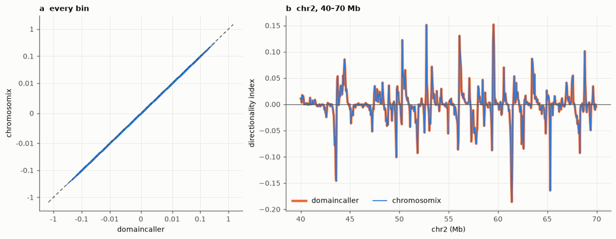

Figure 2: Directionality index, 2 Mb window. a, every bin both score (symmetric-log axes); b, chr2, 40–70 Mb.

```python
TEXT['di_max'] = f'{relative.max():.1e}'
TEXT['di_n'] = f'{ok.sum():,}'
TEXT['di_only_ref'] = f'{di_only_ref:,}'

fig, axes = plt.subplots(1, 2, figsize=(11, 4.2), layout='constrained', width_ratios=[1, 1.6])
ax = axes[0]
ax.scatter(b_di[ok], a_di[ok], s=3, color=APP_COLOUR, alpha=0.35, lw=0, rasterized=True)
lim = np.abs(b_di[ok]).max()
identity(ax, -lim, lim)
TICKS = [-1, -0.1, -0.01, 0, 0.01, 0.1, 1]
ax.set_xscale('symlog', linthresh=0.01)
ax.set_yscale('symlog', linthresh=0.01)
ax.set_xticks(TICKS, [f'{t:g}' for t in TICKS])
ax.set_yticks(TICKS, [f'{t:g}' for t in TICKS])
ax.xaxis.set_minor_locator(plt.NullLocator())
ax.yaxis.set_minor_locator(plt.NullLocator())
ax.set(xlabel='domaincaller', ylabel='chromosomix', title='a  every bin')
ax = axes[1]
lo, _ = clr50.extent('chr2')
stretch = slice(lo + 800, lo + 1_400)
x = clr50.bins()['start'][:].to_numpy()[stretch] / 1e6
ax.plot(x, b_di[stretch], color=REF, lw=3, label='domaincaller')
ax.plot(x, a_di[stretch], color=APP_COLOUR, lw=1.2, label='chromosomix')
ax.axhline(0, color=INK2, lw=0.8)
ax.set(xlabel='chr2 (Mb)', ylabel='directionality index', title='b  chr2, 40–70 Mb')
ax.legend(loc='lower left', ncols=2)
drawn('fig-di')
```

Over 48,094 bins the relative difference is at most 5.0e-06 (float32), and every sign agrees. The 6,346 bins only domaincaller scores are the app’s coverage rule, at chromosome ends and beside gaps.

```python
record('Directionality index', 'mouse Hi-C, 50 kb, window 2 Mb', f"domaincaller {VERSIONS['domaincaller']}",
       f"max relative difference {TEXT['di_max']} over {TEXT['di_n']} bins; every sign agrees",
       'Identical (float32)', apps=['di'], refs=['domaincaller-di'])
```

## 3 · Compartments

cooltools’ preparation in both — observed/expected cis, clipped at its 99.9th percentile, less one — and three eigenvectors ranked by eigenvalue and signed by GC content, computed once per 100 kb bin (`bioframe.frac_gc`, mm10) and given to both. cooltools signs by Spearman correlation, the app by Pearson, and the app leaves the sign unset below |r| = 0.1. chrY, mostly unmappable at 100 kb, is left out of the comparison.

|  | chromosomix | cooltools |
| --- | --- | --- |
| components | `--components 3` | `n_eigs=3` |
| phasing | `--phaseTrack gc.bedGraph` | `phasing_track=gc` |
| diagonals left out; clipping | 2; 99.9th percentile (defaults) | `ignore_diags=2`; `clip_percentile=99.9` |
| eigensolver | Lanczos, a component at a time with deflation, to a residual within 10⁻¹² of each eigenvalue | ARPACK’s restarted Lanczos (`scipy.sparse.linalg.eigsh`), largest in size |

```python
CMP = WORK / 'compartments'
MOUSE_100K = f'{rel(MOUSE)}::/resolutions/100000'
clr100 = cooler.Cooler(f'{MOUSE}::/resolutions/100000')


def gc_content():
    import bioframe
    genome = bioframe.load_fasta(str(MM10), engine='pyfaidx')
    return bioframe.frac_gc(clr100.bins()[['chrom', 'start', 'end']][:], genome)


gc = cached(CMP / 'gc.tsv', gc_content)
GC_TRACK = CMP / 'gc.bedGraph'
if REDO or not GC_TRACK.exists():
    gc.dropna()[['chrom', 'start', 'end', 'GC']].to_csv(GC_TRACK, sep='\t', header=False, index=False)
mr('compartments', MOUSE_100K, '--components', 3, '--phaseTrack', GC_TRACK, out=CMP / 'app',
   name='compartments', analysis='Compartments')
reference('cooltools-eigs', 'Compartments', 'cooltools',
          [PYTHON, script('cooltools_eigs_cis'), MOUSE_100K, CMP / 'gc.tsv', OUT],
          out=CMP / 'cooltools', made=CMP / 'cooltools-eigenvectors.tsv')

ref_vec = pd.read_csv(CMP / 'cooltools-eigenvectors.tsv', sep='\t')
ref_val = pd.read_csv(CMP / 'cooltools-eigenvalues.tsv', sep='\t')
app_vec = {k: table(one(CMP / 'app', f'*.compartment-e{k}.tsv'))['value'].to_numpy(float) for k in (1, 2, 3)}
app_comp = table(one(CMP / 'app', '*.compartment-components.tsv'))


def first(values):
    return values.iloc[0] if len(values) else np.nan


COMPARED = [chrom for chrom in clr100.chromnames if chrom != 'chrY']
rows = []
chrom100 = ref_vec['chrom'].astype(str).to_numpy()
for chrom in COMPARED:
    s = chrom100 == chrom
    row = {'chromosome': chrom}
    for k in (1, 2, 3):
        row[f'r E{k}'] = pearson(app_vec[k][s], ref_vec[f'E{k}'].to_numpy(float)[s])
        eig_app = first(app_comp.loc[(app_comp['sequence'] == chrom) & (app_comp['component'] == f'E{k}'), 'eigenvalue'])
        eig_ref = first(ref_val.loc[ref_val['name'] == chrom, f'eigval{k}'])
        row[f'eigenvalue E{k}, relative difference'] = abs(eig_app / eig_ref - 1)
    e1a, e1b = app_vec[1][s], ref_vec['E1'].to_numpy(float)[s]
    ok = np.isfinite(e1a) & np.isfinite(e1b)
    row['A/B agreement'] = (np.sign(e1a[ok]) == np.sign(e1b[ok])).mean()
    phase = first(app_comp.loc[(app_comp['sequence'] == chrom) & (app_comp['component'] == 'E1'), 'r'])
    row['E1 against GC (app)'] = phase
    row['phasing'] = 'set' if abs(phase) >= 0.1 else 'ambiguous'
    rows.append(row)
cmp_table = pd.DataFrame(rows)
show(cmp_table)
```

```
$ chromosomix compartments data/4DNFIOZ1TRUS.mcool::/resolutions/100000 --components 3 --phaseTrack compartments/gc.bedGraph --out compartments/app
$ python ../../scripts/cooltools_eigs_cis.py data/4DNFIOZ1TRUS.mcool::/resolutions/100000 compartments/gc.tsv compartments/cooltools
```

| chromosome | r E1 | eigenvalue E1, relative difference | r E2 | eigenvalue E2, relative difference | r E3 | eigenvalue E3, relative difference | A/B agreement | E1 against GC (app) | phasing |
| --- | --- | --- | --- | --- | --- | --- | --- | --- | --- |
| chr1 | 0.9997 | 0.0009 | 0.9972 | 0.0036 | 0.9959 | 0.0015 | 0.9958 | 0.7320 | set |
| chr2 | 0.9998 | 0.0003 | 0.9983 | 0.0003 | 0.9986 | 0.0002 | 0.9937 | 0.7500 | set |
| chr3 | 0.9995 | 0.0057 | -0.9921 | 0.0043 | -0.9876 | 0.0061 | 0.9955 | 0.7460 | set |
| chr4 | 0.9997 | 0.0008 | 0.9993 | 0.0015 | -0.3345 | 2.0019 | 0.9972 | 0.7580 | set |
| chr5 | 0.9999 | 0.0003 | 0.9994 | 0.0013 | 0.9987 | 0.0024 | 0.9945 | 0.7540 | set |
| chr6 | 0.9999 | 0.0024 | -0.9986 | 0.0017 | 0.9981 | 0.0020 | 0.9959 | 0.7440 | set |
| chr7 | 0.9998 | 0.0021 | 0.9989 | 0.0004 | 0.9983 | 0.0003 | 0.9953 | 0.7320 | set |
| chr8 | 0.9999 | 0.0019 | 0.9996 | 0.0009 | 0.9992 | 0.0021 | 0.9984 | 0.7440 | set |
| chr9 | 0.9998 | 0.0009 | 0.9996 | 0.0017 | -0.9986 | 0.0003 | 0.9925 | 0.5890 | set |
| chr10 | 0.9998 | 0.0029 | 0.9974 | 0.0012 | 0.9978 | 0.0025 | 0.9921 | 0.7560 | set |
| chr11 | 0.9998 | 0.0006 | 0.9981 | 0.0063 | 0.9984 | 0.0028 | 0.9975 | 0.6340 | set |
| chr12 | 0.9999 | 0.0043 | 0.9990 | 0.0020 | 0.9983 | 0.0002 | 0.9991 | 0.6660 | set |
| chr13 | 0.9996 | 0.0002 | 0.9988 | 0.0013 | 0.9986 | 0.0018 | 0.9885 | 0.6830 | set |
| chr14 | 0.9998 | 0.0044 | 0.9987 | 0.0022 | 0.9986 | 0.0026 | 0.9964 | 0.7220 | set |
| chr15 | 0.9999 | 0.0012 | 0.9995 | 0.0012 | 0.2058 | 1.9995 | 0.9990 | 0.7430 | set |
| chr16 | 0.9999 | 0.0018 | -0.9997 | 0.0018 | 0.9995 | 0.0060 | 0.9968 | 0.7480 | set |
| chr17 | 0.9997 | 0.0033 | 0.9986 | 0.0041 | 0.9977 | 0.0007 | 0.9944 | 0.7980 | set |
| chr18 | 0.9998 | 0.0041 | 0.9980 | 0.0010 | 0.9966 | 0.0028 | 0.9977 | 0.7420 | set |
| chr19 | 0.9999 | 0.0031 | -0.9993 | 0.0055 | 0.9978 | 0.0038 | 1.0000 | 0.7310 | set |
| chrX | 0.9985 | 0.0010 | 0.9988 | 0.0006 | 0.9978 | 0.0016 | 0.9910 | 0.3190 | set |

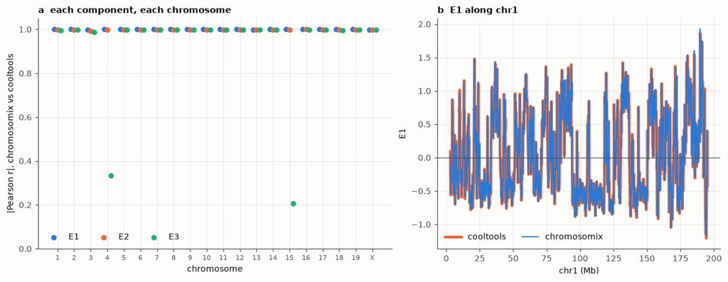

Figure 3: Compartments at 100 kb, both signed by GC content. a, correlation of each component between the two tools, chromosome by chromosome; b, E1 along chr1.

```python
phased = cmp_table[cmp_table['phasing'] == 'set']
TEXT['cmp_min_r'] = f"{phased['r E1'].min():.4f}"
TEXT['cmp_n'] = f'{len(phased)}'
TEXT['cmp_eig'] = f"{phased['eigenvalue E1, relative difference'].max():.2%}"
TEXT['cmp_ab'] = f"{phased['A/B agreement'].min():.2%}"
ambiguous = ', '.join(cmp_table.loc[cmp_table['phasing'] == 'ambiguous', 'chromosome'])
TEXT['cmp_subject'] = (f'the {len(phased)} chromosomes compared, every one phased by GC content' if not ambiguous else
                       f'the {len(phased)} chromosomes whose phasing is set ({ambiguous}: ambiguous, its E1 sign arbitrary)')
e23 = pd.concat([phased[f'r E{k}'] for k in (2, 3)])
TEXT['cmp_e23'] = f"{int((e23.abs() >= 0.98).sum())} of {len(e23)}"

fig, axes = plt.subplots(1, 2, figsize=(11, 4.2), layout='constrained', width_ratios=[1.25, 1])
ax = axes[0]
x = np.arange(len(cmp_table))
for k, colour, offset in ((1, APP_COLOUR, -0.2), (2, REF, 0), (3, '#1baf7a', 0.2)):
    ax.scatter(x + offset, cmp_table[f'r E{k}'].abs(), s=24, color=colour, label=f'E{k}', zorder=3)
ax.set_xticks(x, cmp_table['chromosome'].str.replace('chr', ''), fontsize=7)
ax.set(ylim=(0, 1.05), xlabel='chromosome', ylabel='|Pearson r|, chromosomix vs cooltools',
       title='a  each component, each chromosome')
ax.legend(loc='lower left', ncols=3)
ax = axes[1]
s = chrom100 == 'chr1'
xs = ref_vec['start'].to_numpy()[s] / 1e6
ax.plot(xs, ref_vec['E1'].to_numpy(float)[s], color=REF, lw=3, label='cooltools')
ax.plot(xs, app_vec[1][s], color=APP_COLOUR, lw=1.2, label='chromosomix')
ax.axhline(0, color=INK2, lw=0.8)
ax.set(xlabel='chr1 (Mb)', ylabel='E1', title='b  E1 along chr1')
ax.legend(loc='lower left', ncols=2)
drawn('fig-compartments')
```

On the 20 chromosomes compared, every one phased by GC content, E1 correlates at r ≥ 0.9985, eigenvalues agree within 0.57% and the A/B call on at least 98.85% of bins. E2 and E3 agree up to sign on 38 of 40 chromosome-components (|r| ≥ 0.98); each of the others is one of two eigenvalues of opposite sign and all but the same size, which the two tools — their matrices a few parts in a thousand apart — rank in opposite orders, so that one’s third component is the other’s fourth.

```python
record('Compartments', 'mouse Hi-C, 100 kb, GC-phased', f"cooltools {VERSIONS['cooltools']}",
       f"E1 r ≥ {TEXT['cmp_min_r']} on {TEXT['cmp_n']} chromosomes; eigenvalues within {TEXT['cmp_eig']}; "
       f"A/B ≥ {TEXT['cmp_ab']}",
       'Same eigenvectors' + (f' (phasing ambiguous on {ambiguous})' if ambiguous else ''),
       apps=['compartments'], refs=['cooltools-eigs'])
```

## 4 · P(s)

`--quantity expected --scope file`: per band of separations (factor 1.1), the balanced contacts of every chromosome over the bin pairs that could hold them, at the band’s pair-weighted mean separation, from the app’s default minimum separation of two bins — the diagonal and the one beside it left out, as cooltools’ own default leaves them out (`ignore_diags=2`). cooltools’ per-diagonal sums (`expected_cis`, every diagonal) are pooled over the same bands, each a run of consecutive diagonals from the first the app kept, whose weighted mean is the separation the app writes. The app counts the bin pairs each separation could hold from the bins the balancer dropped, rather than by walking every pair: the same integers, in four hundredths of a second over the mouse map.

```python
PS = WORK / 'ps'
YEAST_800 = f'{rel(YEAST)}::/resolutions/800'
PS_CASES = {'yeast Micro-C, 800 bp': ('yeast', YEAST_800, f'{YEAST}::/resolutions/800', 'yeast 800 bp'),
            'mouse Hi-C, 10 kb': ('mouse', MOUSE_10K, f'{MOUSE}::/resolutions/10000', 'mouse 10 kb')}
EXPECTED = script('cooltools_expected_cis')


def bands(n_valid, separations, binsize, first):
    """The run of consecutive diagonals behind each separation the app wrote: from `first`, then from
    where the last ended, the longest run whose valid-pixel-weighted mean matches it to its six written
    digits."""
    k = np.arange(len(n_valid), dtype=float)
    cn = np.concatenate([[0.0], np.cumsum(n_valid)])
    ck = np.concatenate([[0.0], np.cumsum(n_valid * k)])
    runs, lo = [], first
    for x in separations:
        tolerance = max(0.5, abs(x) * 5e-6)
        match = None
        for hi in range(lo + 1, len(n_valid) + 1):
            w = cn[hi] - cn[lo]
            if w <= 0:
                continue
            mean = (ck[hi] - ck[lo]) / w * binsize
            if abs(mean - x) <= tolerance:
                match = hi
            elif mean > x + tolerance:
                break
        if match is None:
            raise ValueError(f'no run of diagonals from {lo} has its mean at {x}')
        runs.append((lo, match))
        lo = match
    return runs


def kept_from(path):
    """The first diagonal the app kept: its minimum separation, as the table's header records it, and
    never the diagonal itself, which the expected leaves out whatever it says."""
    for line in open(path):
        if line.startswith('# param minSeparation:'):
            return max(1, int(float(line.split(':', 1)[1])))
    raise ValueError(f'{path} does not say its minimum separation')


ps = {}
for label, (slug, uri, local, short) in PS_CASES.items():
    mr('expected', uri, '--quantity', 'expected', '--scope', 'file', out=PS / slug, name=f'expected-{slug}',
       analysis='P(s)', label=short)
    reference(f'cooltools-expected-{slug}', 'P(s)', 'cooltools', [PYTHON, EXPECTED, uri, OUT, THREADS],
              out=PS / f'{slug}-cooltools.tsv', label=short, threads=THREADS)
    saved = one(PS / slug, '*.expected.ps.tsv')
    app = table(saved)
    cvd = pd.read_csv(PS / f'{slug}-cooltools.tsv', sep='\t')
    cvd['balanced.sum'] = cvd['balanced.sum'].fillna(0)
    ref = cvd.groupby('dist')[['n_valid', 'balanced.sum']].sum()
    n = ref['n_valid'].reindex(range(int(ref.index.max()) + 1), fill_value=0).to_numpy(float)
    total = ref['balanced.sum'].reindex(range(len(n)), fill_value=0).to_numpy(float)
    x, y = app.iloc[:, 0].to_numpy(float), app.iloc[:, 1].to_numpy(float)
    runs = bands(n, x, cooler.Cooler(local).binsize, kept_from(saved))
    pooled = np.array([total[a:b].sum() / n[a:b].sum() for a, b in runs])
    ps[label] = dict(x=x, app=y, ref=pooled, rel=np.abs(y / pooled - 1), reach=x.max(), first=runs[0][0])
show(pd.DataFrame([{'map': k, 'points': len(v['x']), 'first diagonal': v['first'],
                    'furthest separation (Mb)': v['reach'] / 1e6,
                    'relative difference, max': v['rel'].max()} for k, v in ps.items()]),
     **{'furthest separation (Mb)': '{:.1f}', 'relative difference, max': '{:.1e}'})
```

```
$ chromosomix expected data/GSE151553_A364_merged.mcool::/resolutions/800 --quantity expected --scope file --out ps/yeast
$ python ../../scripts/cooltools_expected_cis.py data/GSE151553_A364_merged.mcool::/resolutions/800 ps/yeast-cooltools.tsv 4
$ chromosomix expected data/4DNFIOZ1TRUS.mcool::/resolutions/10000 --quantity expected --scope file --out ps/mouse
$ python ../../scripts/cooltools_expected_cis.py data/4DNFIOZ1TRUS.mcool::/resolutions/10000 ps/mouse-cooltools.tsv 4
```

| map | points | first diagonal | furthest separation (Mb) | relative difference, max |
| --- | --- | --- | --- | --- |
| yeast Micro-C, 800 bp | 64 | 2 | 1.4 | 3.2e-06 |
| mouse Hi-C, 10 kb | 89 | 2 | 189.6 | 3.7e-06 |

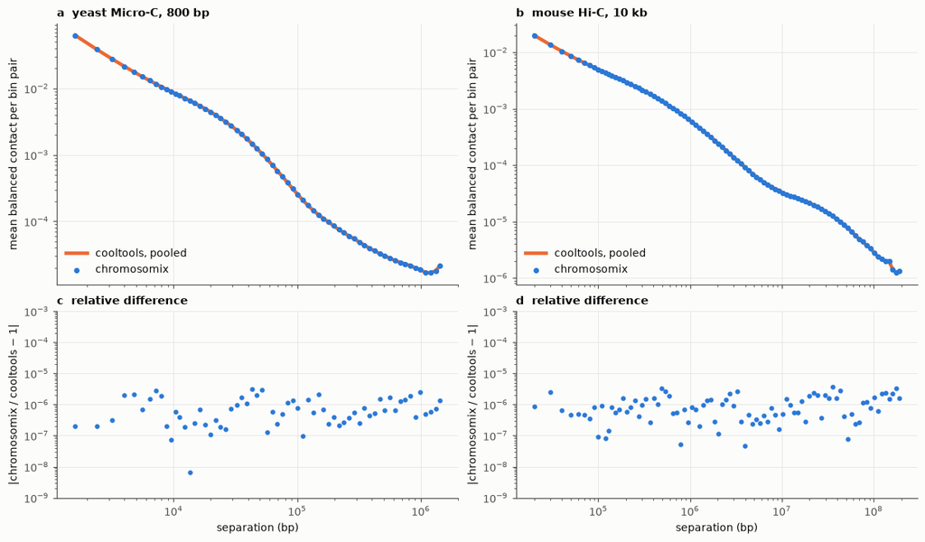

Figure 4: P(s), chromosomix against cooltools.expected_cis pooled over the same bands. a, b, the curves; c, d, the relative difference at every point.

```python
TEXT['ps_max'] = f"{max(v['rel'].max() for v in ps.values()):.1e}"
TEXT['ps_points'] = f"{sum(len(v['x']) for v in ps.values())}"

fig, axes = plt.subplots(2, 2, figsize=(11, 6.4), layout='constrained', height_ratios=[1.4, 1], sharex='col')
for col, (label, v) in enumerate(ps.items()):
    ax = axes[0, col]
    ax.plot(v['x'], v['ref'], color=REF, lw=3, label='cooltools, pooled')
    ax.scatter(v['x'], v['app'], s=14, color=APP_COLOUR, zorder=3, label='chromosomix')
    ax.set(xscale='log', yscale='log', ylabel='mean balanced contact per bin pair', title=f"{'ab'[col]}  {label}")
    ax.legend(loc='lower left')
    ax = axes[1, col]
    ax.scatter(v['x'], np.maximum(v['rel'], 1e-9), s=10, color=APP_COLOUR)
    ax.set(xscale='log', yscale='log', ylim=(1e-9, 1e-3), xlabel='separation (bp)',
           ylabel='|chromosomix / cooltools − 1|', title=f"{'cd'[col]}  relative difference")
drawn('fig-ps')
```

Over 153 points, from two bins to the longest chromosome, the relative difference is at most 3.7e-06 (float32).

```python
record('P(s)', 'yeast Micro-C 800 bp; mouse Hi-C 10 kb', f"cooltools {VERSIONS['cooltools']}",
       f"max relative difference {TEXT['ps_max']} over {TEXT['ps_points']} points",
       'Identical (float32)', apps=['expected-yeast', 'expected-mouse'],
       refs=['cooltools-expected-yeast', 'cooltools-expected-mouse'])
```

## 5 · Peak calling with IDR (yapc)

yapc (Jänes et al. 2018): the concave regions of the pooled signal’s smoothed second derivative, scored in each replicate and tested for reproducibility by IDR. Both tools are given the two replicates cut to chr19, interval for interval (yapc holds a whole genome’s second derivative in memory). Reference: yapc 0.1’s command line with IDR 2.0.3, NumPy’s random seed fixed. yapc breaks score ties at random, so it is run with five seeds, and their spread is the yardstick for IDR.

|  | chromosomix | yapc 0.1 |
| --- | --- | --- |
| smoothing | `--width 150 --times 3` | `--smoothing-window-width 150 --smoothing-times 3` |
| narrowest region | `--minWidth 75` | `--min-concave-region-width 75` |
| regions given to IDR | `--truncate 100000` | `--truncate-idr-input 100000` |
| IDR threshold | `--idr 0.05`, and a count at each of yapc’s six | one BED at each of 0.001–0.2 |

```python
YP = WORK / 'yapc'
REPS = [DATA / f'{path.stem}.chr19.bw' for path in ATAC]


def chr19(source, target):
    """The track with chr19 only, interval for interval."""
    if target.exists() and not REDO:
        return
    handle = pyBigWig.open(str(source))
    out = pyBigWig.open(str(target), 'w')
    out.addHeader([('chr19', handle.chroms()['chr19'])])
    entries = handle.intervals('chr19') or ()
    out.addEntries(['chr19'] * len(entries), [int(a) for a, _, _ in entries],
                   ends=[int(b) for _, b, _ in entries], values=[float(v) for _, _, v in entries])
    out.close()
    handle.close()


for source, target in zip(ATAC, REPS):
    chr19(source, target)
mr('peaks', '--signal', REPS[0], '--replicate', REPS[1], '--perPeak', '--width', 150, '--times', 3,
   '--minWidth', 75, '--truncate', 100000, '--idr', 0.05, out=YP / 'app', name='peaks',
   analysis='Peak calling (yapc, IDR)')
YAPC_SCRIPT = script('yapc_idr')
SEEDS = {seed: YP / f'seed{seed}' for seed in range(5)}
for seed, folder in SEEDS.items():
    reference(f'yapc-seed{seed}', 'Peak calling (yapc, IDR)', 'yapc 0.1', [
        str(YAPC_PYTHON), YAPC_SCRIPT, seed, OUT, 'cond', *REPS, '--smoothing-window-width', 150,
        '--smoothing-times', 3, '--min-concave-region-width', 75, '--truncate-idr-input', 100000],
        out=folder / 'yapc', made=folder / 'yapc_0.05.bed', env=YAPC_ENV, label=f'seed {seed}', bench=seed == 0)

THRESHOLDS = [0.001, 0.005, 0.01, 0.05, 0.1, 0.2]
peaksall = pd.read_csv(SEEDS[0] / 'yapc_peaksall.tsv', sep='\t')
ref_tested = pd.read_csv(SEEDS[0] / 'yapc.tsv', sep='\t')
listing = table(one(YP / 'app', '*.peaks-list.tsv')).rename(columns={'sequence': 'chrom'})
counts_app = table(one(YP / 'app', '*.peaks-idr.tsv'))
called_app = pd.read_csv(one(YP / 'app', '*.bed'), sep='\t', header=None, comment='#',
                         names=['chrom', 'start', 'end', 'name', 'score', 'strand'])
key = ['chrom', 'start', 'end']
bounds = ['chrom', 'concave_start', 'concave_end']
m = listing.merge(ref_tested.drop(columns=['start', 'end']), left_on=key, right_on=bounds, how='outer',
                  indicator=True)
shared = m[m['_merge'] == 'both']
curvature = np.abs(np.r_[shared['curvature0'] - shared['cond_rep1_score'],
                         shared['curvature1'] - shared['cond_rep2_score']])


def bed(th, seed=0):
    out = pd.read_csv(SEEDS[seed] / f'yapc_{th}.bed', sep='\t', header=None, comment='#').iloc[:, :3]
    out.columns = key
    return out


called_ref = bed(0.05)
same_called = called_app[key].merge(called_ref, on=key)
idr = called_app.merge(ref_tested, left_on=key, right_on=bounds)
# −log10 IDR over the peaks called: the app against each seed, and the seeds against one another.
runs = {seed: pd.read_csv(folder / 'yapc.tsv', sep='\t').set_index(bounds)['cond_globalIDR']
        for seed, folder in SEEDS.items()}
app_idr = called_app.set_index(key)['score'].rename_axis(bounds)
idr_app = [np.abs(runs[seed].reindex(app_idr.index) - app_idr).max() for seed in SEEDS]
idr_self = [np.abs(runs[a].reindex(app_idr.index) - runs[b].reindex(app_idr.index)).max()
            for a in SEEDS for b in SEEDS if a < b]
note = next(n for n in NOTES['peaks'] if 'concave region' in n)
found_app, wide_app = (int(re.search(rf'([\d,]+) {w}', note).group(1).replace(',', ''))
                       for w in ('concave region', 'at least'))
wide_ref = int(((peaksall['concave_end'] - peaksall['concave_start']) >= 75).sum())
measures({
    'concave regions, chromosomix / yapc': f'{found_app:,} / {len(peaksall):,}',
    'at least 75 bp, chromosomix / yapc': f'{wide_app:,} / {wide_ref:,}',
    'given to IDR, chromosomix / yapc': f'{len(listing):,} / {len(ref_tested):,}',
    'same bounds; in one only': f"{len(shared):,}; {int((m['_merge'] != 'both').sum())}",
    'same summit': f"{(shared['summit'] == shared['mode']).mean():.2%}",
    'curvature, max |difference| (two decimals written)': f'{curvature.max():.4f}',
    'peaks at IDR ≤ 0.05, chromosomix / yapc; same': f'{len(called_app):,} / {len(called_ref):,}; {len(same_called):,}',
    '−log10 IDR of those peaks, max |difference| to each yapc seed': f'{min(idr_app):.1e} to {max(idr_app):.1e}',
    '−log10 IDR, yapc seeds against one another': f'{min(idr_self):.1e} to {max(idr_self):.1e}',
})
```

```
$ chromosomix peaks --signal data/4DNFIIY4QW2D.chr19.bw --replicate data/4DNFITBRHVZE.chr19.bw --perPeak --width 150 --times 3 --minWidth 75 --truncate 100000 --idr 0.05 --out yapc/app
$ yapc-env/bin/python ../../scripts/yapc_idr.py 0 yapc/seed0/yapc cond data/4DNFIIY4QW2D.chr19.bw data/4DNFITBRHVZE.chr19.bw --smoothing-window-width 150 --smoothing-times 3 --min-concave-region-width 75 --truncate-idr-input 100000
$ yapc-env/bin/python ../../scripts/yapc_idr.py 1 yapc/seed1/yapc cond data/4DNFIIY4QW2D.chr19.bw data/4DNFITBRHVZE.chr19.bw --smoothing-window-width 150 --smoothing-times 3 --min-concave-region-width 75 --truncate-idr-input 100000
$ yapc-env/bin/python ../../scripts/yapc_idr.py 2 yapc/seed2/yapc cond data/4DNFIIY4QW2D.chr19.bw data/4DNFITBRHVZE.chr19.bw --smoothing-window-width 150 --smoothing-times 3 --min-concave-region-width 75 --truncate-idr-input 100000
$ yapc-env/bin/python ../../scripts/yapc_idr.py 3 yapc/seed3/yapc cond data/4DNFIIY4QW2D.chr19.bw data/4DNFITBRHVZE.chr19.bw --smoothing-window-width 150 --smoothing-times 3 --min-concave-region-width 75 --truncate-idr-input 100000
$ yapc-env/bin/python ../../scripts/yapc_idr.py 4 yapc/seed4/yapc cond data/4DNFIIY4QW2D.chr19.bw data/4DNFITBRHVZE.chr19.bw --smoothing-window-width 150 --smoothing-times 3 --min-concave-region-width 75 --truncate-idr-input 100000
```

| measure | value |
| --- | --- |
| concave regions, chromosomix / yapc | 147,852 / 147,852 |
| at least 75 bp, chromosomix / yapc | 128,979 / 128,979 |
| given to IDR, chromosomix / yapc | 100,000 / 100,000 |
| same bounds; in one only | 100,000; 0 |
| same summit | 100.00% |
| curvature, max \|difference\| (two decimals written) | 0.0050 |
| peaks at IDR ≤ 0.05, chromosomix / yapc; same | 5,666 / 5,666; 5,666 |
| −log10 IDR of those peaks, max \|difference\| to each yapc seed | 5.4e-06 to 8.7e-04 |
| −log10 IDR, yapc seeds against one another | 5.9e-04 to 8.7e-04 |

```python
def counted(th):
    values = sorted({len(bed(th, seed)) for seed in SEEDS})
    return f'{values[0]:,}' if len(values) == 1 else f'{values[0]:,}–{values[-1]:,}'


show(pd.DataFrame([{'IDR ≤': th, f'yapc 0.1, seeds 0–{len(SEEDS) - 1}': counted(th),
                    'chromosomix': f"{int(counts_app.loc[np.isclose(counts_app['threshold'], th), 'peaks'].iloc[0]):,}"}
                   for th in THRESHOLDS]), **{'IDR ≤': '{:g}'})
```

| IDR ≤ | yapc 0.1, seeds 0–4 | chromosomix |
| --- | --- | --- |
| 0.001 | 3,279 | 3,279 |
| 0.005 | 4,126 | 4,126 |
| 0.01 | 4,538 | 4,538 |
| 0.05 | 5,666 | 5,666 |
| 0.1 | 6,386 | 6,386 |
| 0.2 | 7,584 | 7,584 |

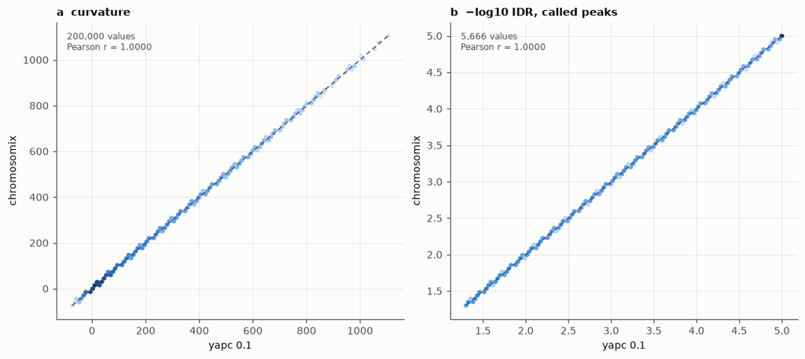

Figure 5: yapc with IDR on two mouse ATAC-seq replicates, chr19. a, the curvature of every region given to IDR, both replicates; b, −log10 IDR of every peak called at IDR ≤ 0.05.

```python
TEXT['yapc_n'] = f'{len(shared):,}'
TEXT['yapc_curv'] = f'{curvature.max():.4f}'
TEXT['yapc_called'] = f'{len(same_called):,}'
TEXT['yapc_idr'] = f'{max(idr_app):.1e}'
TEXT['yapc_self'] = f'{max(idr_self):.1e}'
TEXT['yapc_counts'] = 'every one' if all(
    len(bed(th, seed)) == int(counts_app.loc[np.isclose(counts_app['threshold'], th), 'peaks'].iloc[0])
    for th in THRESHOLDS for seed in SEEDS) else 'not every one'
# Within the spread of yapc's own runs, the six significant digits the app's BED writes aside.
IDR_WITHIN = max(idr_app) <= max(idr_self) + 1e-5

fig, axes = plt.subplots(1, 2, figsize=(10, 4.4), layout='constrained')
agreement(axes[0], np.r_[shared['cond_rep1_score'], shared['cond_rep2_score']],
          np.r_[shared['curvature0'], shared['curvature1']], 'yapc 0.1', 'chromosomix', 'a  curvature')
agreement(axes[1], idr['cond_globalIDR'].to_numpy(float), idr['score'].to_numpy(float), 'yapc 0.1',
          'chromosomix', 'b  −log10 IDR, called peaks')
drawn('fig-yapc')
```

The same 100,000 regions go to IDR, with the same summits and curvatures within the two decimals written. 5,666 peaks pass IDR ≤ 0.05 in both, the same regions; their −log10 IDR is within 8.7e-04 of every yapc run, whose five seeds differ from one another by up to 8.7e-04. The counts agree with every seed at every one of yapc’s six thresholds.

```python
record('Peak calling (yapc, IDR)', 'mouse ATAC-seq, 2 replicates, chr19', f'yapc {YAPC}, idr {IDR}',
       f"{TEXT['yapc_n']} regions, same bounds and summits; {TEXT['yapc_called']} peaks at IDR ≤ 0.05; "
       f"−log10 IDR within {TEXT['yapc_idr']} of 5 yapc seeds (seeds among themselves: up to {TEXT['yapc_self']})",
       'Identical peaks' + ('; IDR within yapc\'s seed-to-seed spread' if IDR_WITHIN else ''),
       apps=['peaks'], refs=[f'yapc-seed{seed}' for seed in SEEDS])
```

## 6 · Loops (chromosight)

Chromosight’s loop preset (`kernels/loops.json`) in both; calls matched by bin pair, p- and q-values read from each call’s detail. The app sums four neighbouring windows of the correlation at once, each adding its cells in chromosight’s order, so its scores are those of one window at a time.

```python
LP = WORK / 'loops'
mr('chromosight', YEAST_800, '--pattern', 'loops', out=LP / 'app', name='chromosight', analysis='Loops (chromosight)')
reference('chromosight', 'Loops (chromosight)', 'chromosight',
          [CHROMOSIGHT, 'detect', '--pattern', 'loops', '--threads', THREADS, YEAST_800, OUT],
          out=LP / 'chromosight' / 'loops', made=LP / 'chromosight' / 'loops.tsv', threads=THREADS)

ref_loops = pd.read_csv(LP / 'chromosight' / 'loops.tsv', sep='\t')
app_loops = table(one(LP / 'app', '*.chromosight-patterns.tsv'))
for key_ in ('p', 'q'):
    app_loops[key_] = app_loops['detail'].str.extract(rf'\b{key_} ([0-9.e+-]+)')[0].astype(float)
m = app_loops.merge(ref_loops, on=['chrom1', 'start1', 'chrom2', 'start2'], how='outer', indicator=True,
                    suffixes=('_app', '_ref'))
shared = m[m['_merge'] == 'both']
# chromosight writes p and q to ten decimals: compared where that leaves four significant digits.
readable = shared[shared['pvalue'] >= 1e-6]
readable_q = shared[shared['qvalue'] >= 1e-6]
measures({
    'loops, chromosomix / chromosight': f'{len(app_loops):,} / {len(ref_loops):,}',
    'same bin pair; in one only': f"{len(shared):,}; {int((m['_merge'] != 'both').sum())}",
    'score, max |difference|': f"{np.abs(shared['score_app'] - shared['score_ref']).max():.1e}",
    f'p, max relative difference ({len(readable):,} loops with p ≥ 1e-6)':
        f"{np.abs(readable['p'] / readable['pvalue'] - 1).max():.1e}",
    f'q, max relative difference ({len(readable_q):,} loops with q ≥ 1e-6)':
        f"{np.abs(readable_q['q'] / readable_q['qvalue'] - 1).max():.1e}",
})
```

```
$ chromosomix chromosight data/GSE151553_A364_merged.mcool::/resolutions/800 --pattern loops --out loops/app
$ chromosight detect --pattern loops --threads 4 data/GSE151553_A364_merged.mcool::/resolutions/800 loops/chromosight/loops
```

| measure | value |
| --- | --- |
| loops, chromosomix / chromosight | 659 / 659 |
| same bin pair; in one only | 659; 0 |
| score, max \|difference\| | 5.1e-07 |
| p, max relative difference (54 loops with p ≥ 1e-6) | 4.2e-03 |
| q, max relative difference (54 loops with q ≥ 1e-6) | 2.9e-03 |

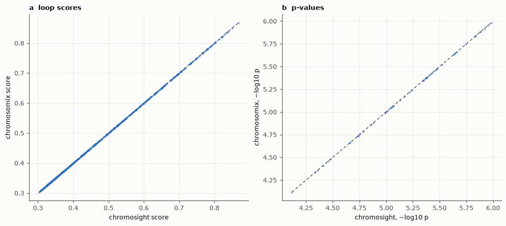

Figure 6: Loops, yeast Micro-C at 800 bp. a, the score of every loop both call; b, their p-values where chromosight’s ten decimals leave four significant digits.

```python
TEXT['loops_n'] = f'{len(shared):,}'
TEXT['loops_only'] = f"{int((m['_merge'] != 'both').sum())}"
TEXT['loops_score'] = f"{np.abs(shared['score_app'] - shared['score_ref']).max():.1e}"
TEXT['loops_p'] = f"{np.abs(readable['p'] / readable['pvalue'] - 1).max():.1e}"

fig, axes = plt.subplots(1, 2, figsize=(10, 4.4), layout='constrained')
ax = axes[0]
ax.scatter(shared['score_ref'], shared['score_app'], s=8, color=APP_COLOUR, alpha=0.6, lw=0)
identity(ax, shared['score_ref'].min(), shared['score_ref'].max())
ax.set(xlabel='chromosight score', ylabel='chromosomix score', title='a  loop scores')
ax = axes[1]
px, py = -np.log10(readable['pvalue']), -np.log10(readable['p'])
ax.scatter(px, py, s=8, color=APP_COLOUR, alpha=0.6, lw=0)
identity(ax, min(px.min(), py.min()), max(px.max(), py.max()))
ax.set(xlabel='chromosight, −log10 p', ylabel='chromosomix, −log10 p', title='b  p-values')
drawn('fig-loops')
```

659 loops at the same bin pairs (0 in one only); scores within 5.1e-07, p-values within 4.2e-03, the three significant digits printed in a call’s detail.

```python
record('Loops (chromosight)', 'yeast Micro-C, 800 bp', f"chromosight {VERSIONS['chromosight']}",
       f"{TEXT['loops_n']} loops, the same bin pairs; scores within {TEXT['loops_score']}",
       'Identical', apps=['chromosight'], refs=['chromosight'])
```

## 7 · Reproducibility (HiCRep)

The stratum-adjusted correlation (Yang et al. 2017) as `hicrep` 0.2.6 computes it: each map’s upper triangle, the main diagonal and every diagonal past the furthest compared set to zero, a 2D mean filter of half-width `h`, a Pearson correlation per diagonal over the positions where either map has a contact, and weights `(n + 1)/12`. Every pair of the three maps, on every chromosome longer than the furthest diagonal compared.

|  | chromosomix | hicrep |
| --- | --- | --- |
| counts | raw, `--no-balance` | raw (`balance=False`) |
| smoothing | `--smooth 1` | `h=1` |
| furthest diagonal | `--maxDistance 50` (5 Mb) | `dBPMax=5_000_000` |
| depth | as read | `bDownSample=False` |

```python
HR = WORK / 'hicrep'
RES, STRATA = 100_000, 50
LABELS = [path.stem for path in CHICKEN]
URIS = {label: f'{rel(path)}::/resolutions/{RES}' for label, path in zip(LABELS, CHICKEN)}
SEQS = [c for c, length in cooler.Cooler(f'{CHICKEN[0]}::/resolutions/{RES}').chromsizes.items()
        if length >= (STRATA + 1) * RES]
PAIRS = f'{len(LABELS)} maps, {len(LABELS) * (len(LABELS) - 1) // 2} pairs'
against = [a for label in LABELS[1:] for a in ('--against', URIS[label])]
mr('hicrep', URIS[LABELS[0]], *against, '--maxDistance', STRATA, '--smooth', 1, '--no-balance',
   '--sequences', ','.join(SEQS), out=HR / 'app', name='hicrep', analysis='Reproducibility (HiCRep)', label=PAIRS)
reference('hicrep', 'Reproducibility (HiCRep)', 'hicrep',
          [PYTHON, script('hicrep_scc'), OUT, ','.join(SEQS), *[f'{label}={URIS[label]}' for label in LABELS]],
          out=HR / 'hicrep.tsv', label=PAIRS)

names = {'This map': LABELS[0], **{path.name: label for label, path in zip(LABELS, CHICKEN)}}
app_scc = table(one(HR / 'app', '*.hicrep-sequences.tsv'))
app_scc['a'], app_scc['b'] = app_scc['a'].map(names), app_scc['b'].map(names)


def unordered(frame):
    order = {label: i for i, label in enumerate(LABELS)}
    swap = frame['a'].map(order) > frame['b'].map(order)
    frame.loc[swap, ['a', 'b']] = frame.loc[swap, ['b', 'a']].to_numpy()
    return frame


scc = (unordered(app_scc[['a', 'b', 'sequence', 'scc']].rename(columns={'scc': 'chromosomix'}))
       .merge(unordered(pd.read_csv(HR / 'hicrep.tsv', sep='\t')), on=['a', 'b', 'sequence']))
scc_diff = scc['chromosomix'] - scc['hicrep']
measures({
    'values (pairs × chromosomes)': f'{len(scc):,}',
    'mean difference': f'{scc_diff.mean():+.1e}',
    'max |difference|': f'{scc_diff.abs().max():.1e}',
    'Pearson r': f"{pearson(scc['chromosomix'].to_numpy(), scc['hicrep'].to_numpy()):.6f}",
})
```

```
$ chromosomix hicrep data/4DNFIH8L6WON.mcool::/resolutions/100000 --against data/4DNFITBCUX56.mcool::/resolutions/100000 --against data/4DNFIIML46E5.mcool::/resolutions/100000 --maxDistance 50 --smooth 1 --no-balance --sequences chr1,chr2,chr3,chr4,chr5,chr6,chr7,chr8,chr9,chr10,chr11,chr12,chr13,ch…
$ python ../../scripts/hicrep_scc.py hicrep/hicrep.tsv chr1,chr2,chr3,chr4,chr5,chr6,chr7,chr8,chr9,chr10,chr11,chr12,chr13,chr14,chr15,chr17,chr18,chr19,chr20,chr21,chr23,chr24,chr26,chr27,chrW,chrZ 4DNFIH8L6WON=data/4DNFIH8L6WON.mcool::/resolutions/100000 4DNFITBCUX56=data/4DNFITBCUX56.mcool::/res…
```

| measure | value |
| --- | --- |
| values (pairs × chromosomes) | 78 |
| mean difference | -3.3e-06 |
| max \|difference\| | 5.0e-05 |
| Pearson r | 1.000000 |

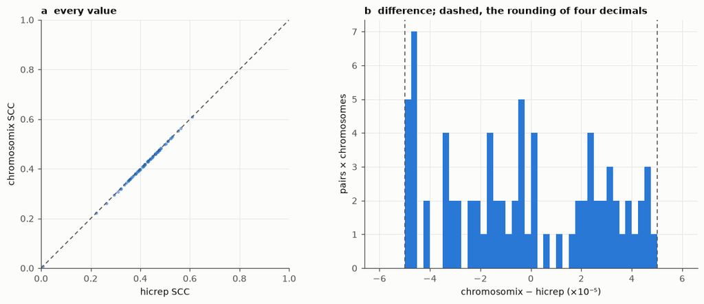

Figure 7: HiCRep on three chicken Hi-C maps at 100 kb, every pair, every chromosome of at least 5.1 Mb. a, chromosomix against hicrep; b, their difference, value by value.

```python
TEXT['hr_n'] = f'{len(scc)}'
TEXT['hr_max'] = f'{scc_diff.abs().max():.1e}'

fig, axes = plt.subplots(1, 2, figsize=(10, 4.2), layout='constrained')
ax = axes[0]
ax.scatter(scc['hicrep'], scc['chromosomix'], s=10, color=APP_COLOUR, alpha=0.6, lw=0)
identity(ax, 0, 1)
ax.set(xlim=(0, 1), ylim=(0, 1), xlabel='hicrep SCC', ylabel='chromosomix SCC', title='a  every value')
ax.set_aspect('equal')
ax = axes[1]
ax.hist(scc_diff * 1e5, bins=np.linspace(-6, 6, 49), color=APP_COLOUR)
for edge in (-5, 5):
    ax.axvline(edge, color=INK2, lw=1, ls=(0, (4, 3)), gid='the rounding of four decimals')
ax.set(xlabel='chromosomix − hicrep (×10⁻⁵)', ylabel='pairs × chromosomes',
       title='b  difference; dashed, the rounding of four decimals')
drawn('fig-hicrep')
```

Over 78 values the two differ by at most 5.0e-05, the rounding of the four decimals the app writes an SCC to.

```python
record('Reproducibility (HiCRep)', 'chicken Hi-C, 3 maps, 100 kb, raw counts', f"hicrep {VERSIONS['hicrep']}",
       f"within {TEXT['hr_max']} over {TEXT['hr_n']} values (4 decimals written)",
       'Identical', apps=['hicrep'], refs=['hicrep'])
```

## 8 · 3D model (pastis-NB)

Counts drawn from a negative binomial of mean `bᵢ·bⱼ·d^−α`, α = 3, with `bᵢ = 1/wᵢ` from the file’s balancing weights scaled to a mean of 1, zeros taken as counts, and a dispersion that is a curve against the mean. Reference: pastis (GitHub `6888ac2`; Varoquaux, Noble & Vert 2023) through its own functions — the moments at each separation and the dispersion fitted against the mean (`compute_mean_variance`, `ExponentialDispersion(degree=1)`), an MDS start from random positions, `negative_binomial_structure.estimate_X` — on the same beads (bins with a weight and a contact). chromosomix ports each of those functions, draws its random start with numpy’s own generator so a seed places the beads where pastis’ does, and runs its default 150 steps, about where pastis’ own L-BFGS-B stops on this map; pastis runs to its own tolerances. A structure has no unique solution, so each runs from the same three seeds: the two from one seed should be one model, and pastis from three seeds is the yardstick for how alike two models of this map can be.

```python
P3 = WORK / 'pastis'
YEAST_12K = f'{rel(YEAST)}::/resolutions/12800'
for seed in (0, 1, 2):
    mr('reconstruct3d', YEAST_12K, '--method', 'nb', '--alpha', 3, '--seed', seed, out=P3 / f'app-seed{seed}',
       name=f'reconstruct3d-seed{seed}', analysis='3D model (pastis-NB)', label=f'seed {seed}', bench=seed == 0)
PASTIS = script('pastis_nb')
for seed in (0, 1, 2):
    reference(f'pastis-seed{seed}', '3D model (pastis-NB)', 'pastis', [PYTHON, PASTIS, YEAST_12K, OUT, seed],
              out=P3 / f'pastis-seed{seed}.npy', label=f'seed {seed}', bench=seed == 0)

clr_y = cooler.Cooler(f'{YEAST}::/resolutions/12800')
raw_y = clr_y.matrix(balance=False)[:].astype(float)
w_y = clr_y.bins()['weight'][:].to_numpy(float)
KEEP = np.isfinite(w_y) & (raw_y.sum(axis=0) > 0)
beads = clr_y.bins()[['chrom', 'start']][:][KEEP].reset_index(drop=True)
bead_chrom = beads['chrom'].astype(str).to_numpy()


def app_model(folder):
    bed3d = pd.read_csv(one(folder, '*.bed3d'), sep='\t', comment='#', header=None,
                        names=['chrom', 'start', 'end', 'x', 'y', 'z'])
    return beads.merge(bed3d, on=['chrom', 'start'], how='left')[['x', 'y', 'z']].to_numpy(float)


MODELS = {**{f'chromosomix, seed {s}': app_model(P3 / f'app-seed{s}') for s in (0, 1, 2)},
          **{f'pastis, seed {s}': np.load(P3 / f'pastis-seed{s}.npy') for s in (0, 1, 2)}}
assert all(model.shape == (KEEP.sum(), 3) and np.isfinite(model).all() for model in MODELS.values()), \
    'a bead is missing from a model'
```

```
$ chromosomix reconstruct3d data/GSE151553_A364_merged.mcool::/resolutions/12800 --method nb --alpha 3 --seed 0 --out pastis/app-seed0
$ chromosomix reconstruct3d data/GSE151553_A364_merged.mcool::/resolutions/12800 --method nb --alpha 3 --seed 1 --out pastis/app-seed1
$ chromosomix reconstruct3d data/GSE151553_A364_merged.mcool::/resolutions/12800 --method nb --alpha 3 --seed 2 --out pastis/app-seed2
$ python ../../scripts/pastis_nb.py data/GSE151553_A364_merged.mcool::/resolutions/12800 pastis/pastis-seed0.npy 0
$ python ../../scripts/pastis_nb.py data/GSE151553_A364_merged.mcool::/resolutions/12800 pastis/pastis-seed1.npy 1
$ python ../../scripts/pastis_nb.py data/GSE151553_A364_merged.mcool::/resolutions/12800 pastis/pastis-seed2.npy 2
```

```python
from scipy.spatial import procrustes
from scipy.spatial.distance import pdist, squareform

same = squareform(np.equal.outer(bead_chrom, bead_chrom).astype(int), checks=False).astype(bool)
dist = {name: pdist(model) for name, model in MODELS.items()}
contacts = squareform(raw_y[np.ix_(KEEP, KEEP)] * np.outer(w_y[KEEP], w_y[KEEP]), checks=False)
seen = contacts > 0


def per_chromosome_disparity(a, b):
    return np.median([procrustes(a[bead_chrom == c], b[bead_chrom == c])[2] for c in pd.unique(bead_chrom)])


def kind(a, b):
    tool_a, seed_a = a.split(', seed ')
    tool_b, seed_b = b.split(', seed ')
    if tool_a != tool_b:
        return 'chromosomix vs pastis, same seed' if seed_a == seed_b else 'chromosomix vs pastis, other seeds'
    return f'{tool_a} vs {tool_b}'


rows = []
names_ = list(MODELS)
for i, a in enumerate(names_):
    for b in names_[i + 1:]:
        rows.append({'models': f'{a} / {b}', 'kind': kind(a, b),
                     'within chromosomes, Spearman ρ': stats.spearmanr(dist[a][same], dist[b][same])[0],
                     'between chromosomes, Spearman ρ': stats.spearmanr(dist[a][~same], dist[b][~same])[0],
                     'per-chromosome Procrustes disparity': per_chromosome_disparity(MODELS[a], MODELS[b])})
models_table = pd.DataFrame(rows)
fit_table = pd.DataFrame([{'model': name, 'fit, all pairs': stats.spearmanr(1 / d[seen], contacts[seen])[0],
                           'fit, within chromosomes': stats.spearmanr(1 / d[seen & same], contacts[seen & same])[0]}
                          for name, d in dist.items()])
display(show(models_table, precision=3))
show(fit_table, precision=3)
```

| models | kind | within chromosomes, Spearman ρ | between chromosomes, Spearman ρ | per-chromosome Procrustes disparity |
| --- | --- | --- | --- | --- |
| chromosomix, seed 0 / chromosomix, seed 1 | chromosomix vs chromosomix | 0.936 | 0.501 | 0.118 |
| chromosomix, seed 0 / chromosomix, seed 2 | chromosomix vs chromosomix | 0.945 | 0.624 | 0.092 |
| chromosomix, seed 0 / pastis, seed 0 | chromosomix vs pastis, same seed | 0.988 | 0.982 | 0.016 |
| chromosomix, seed 0 / pastis, seed 1 | chromosomix vs pastis, other seeds | 0.940 | 0.503 | 0.094 |
| chromosomix, seed 0 / pastis, seed 2 | chromosomix vs pastis, other seeds | 0.942 | 0.566 | 0.092 |
| chromosomix, seed 1 / chromosomix, seed 2 | chromosomix vs chromosomix | 0.953 | 0.543 | 0.079 |
| chromosomix, seed 1 / pastis, seed 0 | chromosomix vs pastis, other seeds | 0.938 | 0.499 | 0.117 |
| chromosomix, seed 1 / pastis, seed 1 | chromosomix vs pastis, same seed | 0.993 | 0.997 | 0.002 |
| chromosomix, seed 1 / pastis, seed 2 | chromosomix vs pastis, other seeds | 0.950 | 0.517 | 0.090 |
| chromosomix, seed 2 / pastis, seed 0 | chromosomix vs pastis, other seeds | 0.943 | 0.625 | 0.092 |
| chromosomix, seed 2 / pastis, seed 1 | chromosomix vs pastis, other seeds | 0.953 | 0.544 | 0.079 |
| chromosomix, seed 2 / pastis, seed 2 | chromosomix vs pastis, same seed | 0.978 | 0.901 | 0.036 |
| pastis, seed 0 / pastis, seed 1 | pastis vs pastis | 0.942 | 0.501 | 0.093 |
| pastis, seed 0 / pastis, seed 2 | pastis vs pastis | 0.940 | 0.569 | 0.091 |
| pastis, seed 1 / pastis, seed 2 | pastis vs pastis | 0.949 | 0.518 | 0.085 |

| model | fit, all pairs | fit, within chromosomes |
| --- | --- | --- |
| chromosomix, seed 0 | 0.473 | 0.871 |
| chromosomix, seed 1 | 0.480 | 0.866 |
| chromosomix, seed 2 | 0.479 | 0.867 |
| pastis, seed 0 | 0.473 | 0.873 |
| pastis, seed 1 | 0.480 | 0.868 |
| pastis, seed 2 | 0.476 | 0.868 |

The fit is the Spearman correlation of `1/d` with the balanced contacts over every pair of beads the map counted.

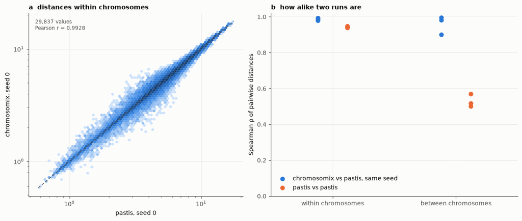

Figure 8: pastis-NB, yeast Micro-C at 12.8 kb. a, distances within chromosomes, chromosomix against pastis from the same seed, 0, each over its model’s median distance between neighbouring beads; b, how alike two runs are, within and between chromosomes: chromosomix and pastis from one seed, and pastis from two.

```python
cross = models_table[models_table['kind'] == 'chromosomix vs pastis, same seed']
selfs = models_table[models_table['kind'] == 'pastis vs pastis']


def spread(frame, column, digits):
    return f"{frame[column].min():.{digits}f}–{frame[column].max():.{digits}f}"


TEXT['p3_beads'] = f'{KEEP.sum():,}'
TEXT['p3_intra_cross'] = spread(cross, 'within chromosomes, Spearman ρ', 3)
TEXT['p3_intra_self'] = spread(selfs, 'within chromosomes, Spearman ρ', 3)
TEXT['p3_inter_cross'] = spread(cross, 'between chromosomes, Spearman ρ', 2)
TEXT['p3_inter_self'] = spread(selfs, 'between chromosomes, Spearman ρ', 2)
TEXT['p3_disparity_cross'] = spread(cross, 'per-chromosome Procrustes disparity', 3)
TEXT['p3_disparity_self'] = spread(selfs, 'per-chromosome Procrustes disparity', 3)
fits = fit_table.set_index('model')['fit, all pairs']
within = fit_table.set_index('model')['fit, within chromosomes']
app_names = [n for n in fits.index if n.startswith('chromosomix')]
pastis_names = [n for n in fits.index if n.startswith('pastis')]
TEXT['p3_fit_app'] = f"{fits[app_names].min():.3f}–{fits[app_names].max():.3f}"
TEXT['p3_fit_pastis'] = f"{fits[pastis_names].min():.3f}–{fits[pastis_names].max():.3f}"
TEXT['p3_fit_app_within'] = f"{within[app_names].min():.3f}–{within[app_names].max():.3f}"
TEXT['p3_fit_pastis_within'] = f"{within[pastis_names].min():.3f}–{within[pastis_names].max():.3f}"


def versus(app, reference_):
    return ('better than' if app.min() > reference_.max() else 'less well than' if app.max() < reference_.min()
            else 'as well as')


TEXT['p3_within_word'] = versus(within[app_names], within[pastis_names])
TEXT['p3_all_word'] = versus(fits[app_names], fits[pastis_names])

fig, axes = plt.subplots(1, 2, figsize=(11, 4.6), layout='constrained', width_ratios=[1, 1.15])


def scaled(model):
    step = np.median(np.linalg.norm(np.diff(model, axis=0), axis=1)[bead_chrom[1:] == bead_chrom[:-1]])
    return pdist(model) / step


agreement(axes[0], scaled(MODELS['pastis, seed 0'])[same], scaled(MODELS['chromosomix, seed 0'])[same],
          'pastis, seed 0', 'chromosomix, seed 0', 'a  distances within chromosomes', scale='log')
ax = axes[1]
for col, metric in enumerate(('within chromosomes, Spearman ρ', 'between chromosomes, Spearman ρ')):
    for offset, frame, colour, label in ((-0.12, cross, APP_COLOUR, 'chromosomix vs pastis, same seed'),
                                         (0.12, selfs, REF, 'pastis vs pastis')):
        ax.scatter(np.full(len(frame), col + offset), frame[metric], s=36, color=colour,
                   label=label if col == 0 else None, zorder=3, gid=label)
ax.set_xticks([0, 1], ['within chromosomes', 'between chromosomes'])
ax.set(xlim=(-0.5, 1.5), ylim=(0, 1.02), ylabel='Spearman ρ of pairwise distances', title='b  how alike two runs are')
ax.legend(loc='lower left')
drawn('fig-pastis')
```

On 905 beads, chromosomix and pastis from the same seed give the same model: distances within chromosomes correlate at ρ = 0.978–0.993, against 0.940–0.949 between pastis’ own seeds; between chromosomes at 0.90–1.00 (0.50–0.57); and the median per-chromosome Procrustes disparity is 0.002–0.036 (0.085–0.093). chromosomix’s models fit the contacts within chromosomes as well as pastis’ (0.866–0.871 against 0.868–0.873), and over all pairs, the chromosomes’ arrangement included, as well as pastis’ (0.473–0.480 against 0.473–0.480).

```python
record('3D model (pastis-NB)', f"yeast Micro-C, 12.8 kb, {TEXT['p3_beads']} beads", 'pastis 0.5.0 (GitHub 6888ac2)',
       f"same seed: within chromosomes ρ = {TEXT['p3_intra_cross']}, between {TEXT['p3_inter_cross']} "
       f"(pastis vs pastis {TEXT['p3_intra_self']}, {TEXT['p3_inter_self']}); "
       f"fit within chromosomes {TEXT['p3_fit_app_within']} vs {TEXT['p3_fit_pastis_within']}, "
       f"all pairs {TEXT['p3_fit_app']} vs {TEXT['p3_fit_pastis']}",
       f"Same seed, same model; fits within chromosomes {TEXT['p3_within_word']} pastis; "
       f"all pairs {TEXT['p3_all_word']} pastis",
       apps=['reconstruct3d-seed0', 'reconstruct3d-seed1', 'reconstruct3d-seed2'],
       refs=['pastis-seed0', 'pastis-seed1', 'pastis-seed2'])
```

## 9 · Coverage

Per bin, the contacts of every pixel that touches it: within its own chromosome (cis) and over the genome (total). cooltools’ `coverage` adds a pixel at both of its ends, `bincount(bin1) + bincount(bin2)`, so a pixel on the diagonal is counted twice; the app counts it once, a bin’s contact with itself being one contact. cooltools’ value less the bin’s own diagonal pixel is therefore the app’s, and that is what is compared, raw and balanced.

|  | chromosomix | cooltools |
| --- | --- | --- |
| counts | raw, the default, and `--balance` | `clr_weight_name=None`, and `'weight'` |
| diagonals | every one | `ignore_diags=0` |
| outputs | `--cis --trans --fraction`, with total | cis and total |

```python
COV = WORK / 'coverage'
WANTED = ['--cis', '--trans', '--fraction']
mr('coverage', MOUSE_10K, *WANTED, out=COV / 'raw', name='coverage-raw', analysis='Coverage', label='raw')
mr('coverage', MOUSE_10K, *WANTED, '--balance', out=COV / 'balanced', name='coverage-balanced',
   analysis='Coverage', label='balanced')
for kind, extra in (('raw', []), ('balanced', ['weight'])):
    reference(f'cooltools-coverage-{kind}', 'Coverage', 'cooltools',
              [PYTHON, script('cooltools_coverage'), MOUSE_10K, OUT, THREADS, *extra],
              out=COV / f'cooltools-{kind}.tsv', label=kind, threads=THREADS)


def self_contacts(clr, chunk=10_000_000):
    """Each bin's pixel on the diagonal, copies of it added, and then how many pixels the file stores
    twice — one array, the count last. Read whole rows at a time, so that a pixel and its copy, which
    are in one row, are always read together."""
    with clr.open('r') as group:
        offsets = group['indexes/bin1_offset'][:]
    n = len(offsets) - 1
    diagonal, twice = np.zeros(n), 0
    rows = np.unique(np.r_[np.searchsorted(offsets, np.arange(0, offsets[-1], chunk)), n])
    for a, b in zip(rows[:-1], rows[1:]):
        px = clr.pixels()[int(offsets[a]):int(offsets[b])]
        b1, b2 = px['bin1_id'].to_numpy(), px['bin2_id'].to_numpy()
        on = b1 == b2
        diagonal += np.bincount(b1[on], weights=px['count'].to_numpy(float)[on], minlength=n)
        pairs = b1.astype(np.int64) * n + b2
        twice += len(pairs) - len(np.unique(pairs))
    return np.append(diagonal, twice)


held = cached(COV / 'self-contacts.npy', lambda: self_contacts(clr10))
diagonal, stored_twice = held[:-1], int(held[-1])
weight10 = bins10['weight'].to_numpy(float)
coverage = {}
for kind, own in (('raw', diagonal), ('balanced', diagonal * weight10 ** 2)):
    ref = pd.read_csv(COV / f'cooltools-{kind}.tsv', sep='\t')
    app = {track: table(one(COV / kind, f'*.coverage-{track}.tsv'))['value'].to_numpy(float)
           for track in ('cis', 'total', 'trans', 'fraction')}
    cis, total = ref['cis'].to_numpy(float) - own, ref['total'].to_numpy(float) - own
    with np.errstate(invalid='ignore', divide='ignore'):
        fraction = np.where(total > 0, cis / total, np.nan)
    both = np.isfinite(app['total']) & np.isfinite(total)
    coverage[kind] = dict(
        app=app, ref=ref, cis=cis, total=total, both=both,
        gaps=(int((~np.isfinite(app['total'])).sum()), int((~np.isfinite(total)).sum())),
        same_gaps=bool((np.isfinite(app['total']) == np.isfinite(total)).all()),
        absolute=max(np.abs(app[t][both] - v[both]).max() for t, v in (('cis', cis), ('total', total))),
        relative=max(relative_difference(app[t][both], v[both])[v[both] != 0].max() for t, v in (('cis', cis), ('total', total))),
        trans=np.nanmax(np.abs(app['trans'] - (total - cis))),
        fraction=np.nanmax(np.abs(app['fraction'] - fraction)))
raw, balanced = coverage['raw'], coverage['balanced']
measures({
    'bins': f'{len(bins10):,}',
    'raw cis and total, max |difference| (cooltools less the diagonal)': f"{raw['absolute']:g}",
    'balanced cis and total, max relative difference': f"{balanced['relative']:.1e}",
    'trans (total less cis) and cis fraction, max |difference|':
        f"{max(raw['trans'], balanced['trans']):.1e}; {max(raw['fraction'], balanced['fraction']):.1e}",
    'balanced bins without a value, chromosomix / cooltools':
        f"{balanced['gaps'][0]:,} / {balanced['gaps'][1]:,} ({'the same bins' if balanced['same_gaps'] else 'not the same bins'})",
    'pixels the file stores twice (both tools add the copies)': f'{stored_twice:,}',
})
```

```
$ chromosomix coverage data/4DNFIOZ1TRUS.mcool::/resolutions/10000 --cis --trans --fraction --out coverage/raw
$ chromosomix coverage data/4DNFIOZ1TRUS.mcool::/resolutions/10000 --cis --trans --fraction --balance --out coverage/balanced
$ python ../../scripts/cooltools_coverage.py data/4DNFIOZ1TRUS.mcool::/resolutions/10000 coverage/cooltools-raw.tsv 4
$ python ../../scripts/cooltools_coverage.py data/4DNFIOZ1TRUS.mcool::/resolutions/10000 coverage/cooltools-balanced.tsv 4 weight
```

| measure | value |
| --- | --- |
| bins | 272,564 |
| raw cis and total, max \|difference\| (cooltools less the diagonal) | 0 |
| balanced cis and total, max relative difference | 5.0e-06 |
| trans (total less cis) and cis fraction, max \|difference\| | 1.3e-06; 5.3e-07 |
| balanced bins without a value, chromosomix / cooltools | 28,572 / 28,572 (the same bins) |
| pixels the file stores twice (both tools add the copies) | 49 |

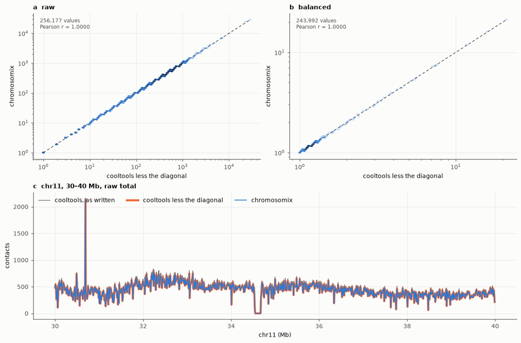

Figure 9: Coverage at 10 kb. a, total coverage of every bin, raw; b, balanced; c, chr11, 30–40 Mb, raw: cooltools as it writes it, and less each bin’s own diagonal pixel.

```python
TEXT['cov_n'] = f"{raw['both'].sum():,}"
TEXT['cov_raw'] = f"{raw['absolute']:g}"
TEXT['cov_bal'] = f"{balanced['relative']:.1e}"
TEXT['cov_twice'] = f'{stored_twice:,}'
TEXT['cov_gaps'] = f"{balanced['gaps'][0]:,}"
TEXT['cov_same'] = 'the same' if raw['absolute'] == 0 else 'not the same'
TEXT['cov_gap_words'] = 'the same' if balanced['same_gaps'] else 'not the same'

fig = plt.figure(figsize=(11, 7.2), layout='constrained')
grid = fig.add_gridspec(2, 2, height_ratios=[1.15, 1])
agreement(fig.add_subplot(grid[0, 0]), raw['total'], raw['app']['total'], 'cooltools less the diagonal',
          'chromosomix', 'a  raw', scale='log')
agreement(fig.add_subplot(grid[0, 1]), balanced['total'], balanced['app']['total'], 'cooltools less the diagonal',
          'chromosomix', 'b  balanced', scale='log')
ax = fig.add_subplot(grid[1, :])
lo, _ = clr10.extent('chr11')
stretch = slice(lo + 3_000, lo + 4_000)
x = bins10['start'].to_numpy()[stretch] / 1e6
ax.plot(x, raw['ref']['total'].to_numpy(float)[stretch], color=INK2, lw=0.8, label='cooltools, as written')
ax.plot(x, raw['total'][stretch], color=REF, lw=3, label='cooltools less the diagonal')
ax.plot(x, raw['app']['total'][stretch], color=APP_COLOUR, lw=1.2, label='chromosomix')
ax.set(xlabel='chr11 (Mb)', ylabel='contacts', title='c  chr11, 30–40 Mb, raw total')
ax.legend(loc='upper left', ncols=3)
drawn('fig-coverage')
```

Raw, cis and total are the same on the 272,564 bins (largest difference 0) once cooltools’ second count of the diagonal is taken off; balanced, they agree within 5.0e-06, the six digits written, and the 28,572 bins the app leaves without a value are the same bins as cooltools’. The file stores 49 pixels twice; both tools add the copies.

```python
record('Coverage', 'mouse Hi-C, 10 kb, raw and balanced', f"cooltools {VERSIONS['cooltools']}",
       f"raw: identical on {TEXT['cov_n']} bins, cooltools' diagonal counted once; balanced within {TEXT['cov_bal']}",
       'Identical' if raw['absolute'] == 0 and balanced['same_gaps'] else 'Differs',
       apps=['coverage-raw', 'coverage-balanced'],
       refs=['cooltools-coverage-raw', 'cooltools-coverage-balanced'])
```

## 10 · Virtual 4C

A viewpoint’s row of the balanced map, over the whole genome. cooltools’ `virtual4c` takes the stored pixels between the viewpoint and each chromosome and averages them bin by bin; for a viewpoint one bin wide that is the row itself, with no value where the map stores no contact, nor on the viewpoint. The app sums the viewpoint’s rows and writes 0 where nothing is stored; `--no-cis` reads every chromosome. The viewpoints are the 10 kb bins holding the 5′-most TSS of three genes of pluripotency, *Sox2*, *Nanog* and *Pou5f1*.

|  | chromosomix | cooltools |
| --- | --- | --- |
| viewpoint | `--anchor`, one bin | `viewpoint`, one bin |
| scope | `--no-cis`: the whole genome | the whole genome |
| counts | balanced (the file’s weights) | `clr_weight_name='weight'` |

```python
V4C = WORK / 'virtual4c'


def promoter_bin(gene, binsize=10_000):
    """The bin holding a gene's 5′-most TSS."""
    rows = TRANSCRIPTS[TRANSCRIPTS['gene'] == gene]
    plus = rows['strand'].iloc[0] == '+'
    tss = int(rows['start'].min() if plus else rows['end'].max() - 1)
    return rows['chrom'].iloc[0], tss // binsize * binsize, tss // binsize * binsize + binsize


VIEWPOINTS = {gene: promoter_bin(gene) for gene in ('Sox2', 'Nanog', 'Pou5f1')}
for gene, (chrom, start, end) in VIEWPOINTS.items():
    # Timed at Sox2 alone: the other two viewpoints are the same computation from another bin.
    mr('fourc', MOUSE_10K, '--anchor', f'{chrom}:{start + 1:,}-{end:,}', '--no-cis', out=V4C / gene,
       name=f'fourc-{gene}', analysis='Virtual 4C', label=gene, bench=gene == 'Sox2')
    reference(f'cooltools-virtual4c-{gene}', 'Virtual 4C', 'cooltools',
              [PYTHON, script('cooltools_virtual4c'), MOUSE_10K, f'{chrom}:{start}-{end}', OUT, THREADS],
              out=V4C / f'cooltools-{gene}.tsv', label=gene, threads=THREADS, bench=gene == 'Sox2')

profiles, rows = {}, []
for gene, (chrom, start, end) in VIEWPOINTS.items():
    a = table(one(V4C / gene, '*.fourc-*.tsv'))['value'].to_numpy(float)
    b = pd.read_csv(V4C / f'cooltools-{gene}.tsv', sep='\t')['balanced'].to_numpy(float)
    at = clr10.offset(f'{chrom}:{start}-{end}')
    both, app_only = np.isfinite(a) & np.isfinite(b), np.isfinite(a) & ~np.isfinite(b)
    zero = app_only & (a == 0)
    profiles[gene] = dict(app=a, ref=b, at=at, chrom=chrom, both=both)
    rows.append({'viewpoint': f'{gene}, {chrom}:{start + 1:,}-{end:,}', 'bins both report': int(both.sum()),
                 'max relative difference': relative_difference(a[both], b[both]).max(),
                 'only chromosomix: 0': int(zero.sum()),
                 'only chromosomix: the viewpoint': int(app_only[at] and not zero[at]),
                 'only chromosomix: anything else': int((app_only & ~zero).sum() - (app_only[at] and not zero[at])),
                 'only cooltools': int((np.isfinite(b) & ~np.isfinite(a)).sum()),
                 'no value in chromosomix, at a dropped bin': f"{int((~np.isfinite(a) & np.isnan(weight10)).sum()):,} of {int((~np.isfinite(a)).sum()):,}"})
v4c_table = pd.DataFrame(rows)
show(v4c_table, **{'max relative difference': '{:.1e}'})
```

```
$ chromosomix fourc data/4DNFIOZ1TRUS.mcool::/resolutions/10000 --anchor chr3:34,650,001-34,660,000 --no-cis --out virtual4c/Sox2
$ python ../../scripts/cooltools_virtual4c.py data/4DNFIOZ1TRUS.mcool::/resolutions/10000 chr3:34650000-34660000 virtual4c/cooltools-Sox2.tsv 4
$ chromosomix fourc data/4DNFIOZ1TRUS.mcool::/resolutions/10000 --anchor chr6:122,700,001-122,710,000 --no-cis --out virtual4c/Nanog
$ python ../../scripts/cooltools_virtual4c.py data/4DNFIOZ1TRUS.mcool::/resolutions/10000 chr6:122700000-122710000 virtual4c/cooltools-Nanog.tsv 4
$ chromosomix fourc data/4DNFIOZ1TRUS.mcool::/resolutions/10000 --anchor chr17:35,500,001-35,510,000 --no-cis --out virtual4c/Pou5f1
$ python ../../scripts/cooltools_virtual4c.py data/4DNFIOZ1TRUS.mcool::/resolutions/10000 chr17:35500000-35510000 virtual4c/cooltools-Pou5f1.tsv 4
```

| viewpoint | bins both report | max relative difference | only chromosomix: 0 | only chromosomix: the viewpoint | only chromosomix: anything else | only cooltools | no value in chromosomix, at a dropped bin |
| --- | --- | --- | --- | --- | --- | --- | --- |
| Sox2, chr3:34,650,001-34,660,000 | 379 | 4.5e-06 | 243612 | 1 | 0 | 0 | 28,572 of 28,572 |
| Nanog, chr6:122,700,001-122,710,000 | 389 | 4.3e-06 | 243602 | 1 | 0 | 0 | 28,572 of 28,572 |
| Pou5f1, chr17:35,500,001-35,510,000 | 331 | 3.4e-06 | 243660 | 1 | 0 | 0 | 28,572 of 28,572 |

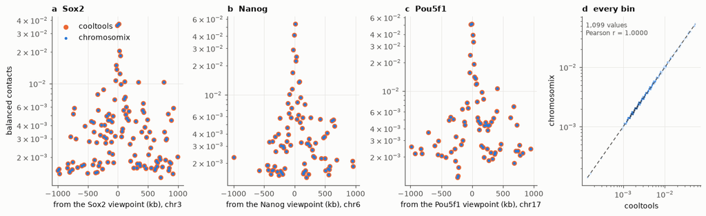

Figure 10: Virtual 4C at 10 kb, balanced. a–c, each viewpoint’s own chromosome within 1 Mb of it, where either tool reports a contact (the viewpoint itself left out); d, every bin of the three profiles both report, over the whole genome.

```python
TEXT['v4c_n'] = f"{v4c_table['bins both report'].sum():,}"
TEXT['v4c_max'] = f"{v4c_table['max relative difference'].max():.1e}"
TEXT['v4c_zero'] = f"{v4c_table['only chromosomix: 0'].sum():,}"
TEXT['v4c_other'] = ('and nothing else' if v4c_table['only chromosomix: anything else'].sum() == 0
                     else f"and {v4c_table['only chromosomix: anything else'].sum():,} bins besides")
V4C_OK = (v4c_table['only chromosomix: anything else'].sum() == 0) & (v4c_table['only cooltools'].sum() == 0)

fig, axes = plt.subplots(1, 4, figsize=(12, 3.6), layout='constrained', width_ratios=[1, 1, 1, 0.9])
for ax, (letter, (gene, v)) in zip(axes, zip('abc', profiles.items())):
    reach = slice(v['at'] - 100, v['at'] + 101)
    x = (np.arange(len(v['app']))[reach] - v['at']) * 10
    a, b = v['app'][reach].copy(), v['ref'][reach].copy()
    a[100] = np.nan
    ax.scatter(x[b > 0], b[b > 0], s=26, color=REF, label='cooltools', zorder=2)
    ax.scatter(x[a > 0], a[a > 0], s=6, color=APP_COLOUR, label='chromosomix', zorder=3)
    ax.set(yscale='log', xlabel=f"from the {gene} viewpoint (kb), {v['chrom']}", title=f'{letter}  {gene}')
axes[0].set_ylabel('balanced contacts')
axes[0].legend(loc='upper left')
agreement(axes[3], np.concatenate([v['ref'][v['both']] for v in profiles.values()]),
          np.concatenate([v['app'][v['both']] for v in profiles.values()]), 'cooltools', 'chromosomix',
          'd  every bin', scale='log')
drawn('fig-virtual4c')
```

On the 1,099 bins cooltools reports, the two agree within 4.5e-06 (float32, six digits written). The bins only the app writes are 730,874 at 0, where the map stores no contact with the viewpoint, the viewpoints themselves, and nothing else; where the app writes no value, balancing dropped the bin.

```python
record('Virtual 4C', 'mouse Hi-C, 10 kb, three viewpoints, whole genome', f"cooltools {VERSIONS['cooltools']}",
       f"every bin cooltools reports ({TEXT['v4c_n']}) within {TEXT['v4c_max']}; the others 0 or the viewpoint",
       'Identical (float32)' if V4C_OK else 'Differs', apps=[f'fourc-{g}' for g in VIEWPOINTS],
       refs=[f'cooltools-virtual4c-{g}' for g in VIEWPOINTS])
```

## 11 · Aggregate peak analysis (coolpuppy)

The mean window about a set of loops. The loops are chromosight’s own calls on this map (`chromosight detect`, its loop preset), given to both tools as one BEDPE; each window runs 5 bins either side of a loop, ±50 kb. Both cut a window as coolpuppy does by default: from the upper triangle only — a window that crosses the diagonal holds the same contacts twice there, once above it and once mirrored below — with the main diagonal and the one beside it left out (`min_diag=2`); and both leave out every loop nearer the diagonal than twice the flank and two bins (`mindist='auto'`), which is where a window would start to reach those two diagonals. That floor is coolpuppy’s default and not the app’s, whose *nearest loop* is five bins unless told otherwise, so the app is given it, `--minDist 12` — as it is given the window, the diagonals left out and the normalisation, each at coolpuppy’s value rather than at a default of its own. Both run at coolpuppy’s defaults, and then again with every loop (`mindist=0`, `--minDist 0`): those are the windows that reach the diagonal.

Six pileups are compared cell for cell, gap for gap: raw and over the expected — each window divided cell by cell by its chromosome’s expected at that cell’s own diagonal before the mean, the expected being cooltools’ `expected_cis` from § 4, which coolpuppy reads as `balanced.avg` — at coolpuppy’s defaults and with every loop; and the same two on the diagonal, at every loop anchor. Then the distance-matched normalisation: each pileup over the pileup of controls, five per loop, shifted along the diagonal by 50 to 500 bins either way — against coolpuppy’s own shifted controls over the same range. Both draw their controls at random, so each is run with five seeds.

|  | chromosomix | coolpuppy |
| --- | --- | --- |
| window | `--mode fixed --window 5` (bins either side) | `flank=50_000` |
| near the diagonal | `--minDiag 2 --minDist 12`: twice `--window` and 2 | nothing: `min_diag` is 2, and `mindist` `'auto'`, by default |
| every loop | `--minDist 0` | `mindist=0` |
| raw | `--norm none` | `ooe=False` |
| over the expected | `--norm oe` | `expected_df=` § 4’s table, `ooe=True` |
| on the diagonal | `--anchors features --features anchors.bed` | `features_format='bed'`, `local=True` |
| controls | `--norm matched --controls 5 --minShift 50 --maxShift 500` | `nshifts=5`, `minshift=500_000`, `maxshift=5_005_000` |

```python
from itertools import combinations, product

APA = WORK / 'apa'
FLANK = 5
reference('chromosight-mouse', 'Aggregate peak analysis', 'chromosight',
          [CHROMOSIGHT, 'detect', '--pattern', 'loops', '--threads', THREADS, MOUSE_10K, OUT],
          out=APA / 'loops', made=APA / 'loops.tsv', label='the loops, called', threads=THREADS, bench=False)
called = pd.read_csv(APA / 'loops.tsv', sep='\t')
apart = ((called['start2'] - called['start1']) // clr10.binsize).to_numpy()
LOOPS, ANCHORS = APA / 'loops.bedpe', APA / 'anchors.bed'
called[['chrom1', 'start1', 'end1', 'chrom2', 'start2', 'end2']].to_csv(LOOPS, sep='\t', header=False, index=False)
ends = [called[[f'chrom{k}', f'start{k}', f'end{k}']].set_axis(['chrom', 'start', 'end'], axis=1) for k in (1, 2)]
anchors = pd.concat(ends).drop_duplicates().sort_values(['chrom', 'start'])
anchors.to_csv(ANCHORS, sep='\t', header=False, index=False)
# A window reaches the first two diagonals where its loop is nearer than twice the flank and two, which
# is also where coolpuppy's default floor is, `mindist='auto'`; the app's own is five bins, so it is
# given this one. With every loop, the lower-left corner, nearest the diagonal, comes only from the
# loops whose windows do not.
MIN_DIAG, MIN_DIST = 2, 2 * FLANK + 2
reaching = int((apart < MIN_DIST).sum())
cornered = int((apart - 2 * FLANK >= 2).sum())
PILEUP = script('coolpuppy_pileup')
EXPECTED_MOUSE = PS / 'mouse-cooltools.tsv'
#: name: (label, chromosomix's arguments, coolpuppy's features and options). The app's window, its
#: diagonals left out, its nearest loop and its normalisation are named at coolpuppy's values: the
#: app's own defaults are not all coolpuppy's, and a default can move.
CUTS = {
    'raw': ('raw', ['--pairs', LOOPS, '--norm', 'none', '--minDist', MIN_DIST], [LOOPS]),
    'oe': ('over the expected', ['--pairs', LOOPS, '--norm', 'oe', '--minDist', MIN_DIST],
           [LOOPS, '--expected', EXPECTED_MOUSE]),
    'raw-every': ('raw, every loop', ['--pairs', LOOPS, '--norm', 'none', '--minDist', 0], [LOOPS, '--mindist', 0]),
    'oe-every': ('over the expected, every loop', ['--pairs', LOOPS, '--norm', 'oe', '--minDist', 0],
                 [LOOPS, '--expected', EXPECTED_MOUSE, '--mindist', 0]),
    'local': ('on the diagonal, raw', ['--anchors', 'features', '--features', ANCHORS, '--norm', 'none'],
              [ANCHORS, '--local']),
    'local-oe': ('on the diagonal, over the expected',
                 ['--anchors', 'features', '--features', ANCHORS, '--norm', 'oe'],
                 [ANCHORS, '--local', '--expected', EXPECTED_MOUSE]),
}
for key, (label, app_args, (features_, *options)) in CUTS.items():
    # Timed raw and over controls, not over the expected: there coolpuppy is handed § 4's expected,
    # computed beforehand, and chromosomix computes its own, so the two times are not of one job.
    timed = 'oe' not in key.split('-')
    mr('apa', MOUSE_10K, *app_args, '--mode', 'fixed', '--window', FLANK, '--minDiag', MIN_DIAG,
       out=APA / key, name=f'apa-{key}', analysis='Aggregate peak analysis', label=label, bench=timed)
    reference(f'coolpuppy-{key}', 'Aggregate peak analysis', 'coolpuppy',
              [PYTHON, PILEUP, MOUSE_10K, features_, FLANK * clr10.binsize, OUT, THREADS, *options],
              out=APA / f'coolpuppy-{key}.tsv', label=label, threads=THREADS, bench=timed)
SHIFTS = range(5)
for seed in SHIFTS:
    mr('apa', MOUSE_10K, '--pairs', LOOPS, '--norm', 'matched', '--controls', 5, '--minShift', 50,
       '--maxShift', 500, '--seed', seed + 1, '--mode', 'fixed', '--window', FLANK, '--minDiag', MIN_DIAG,
       '--minDist', MIN_DIST, out=APA / f'controls-seed{seed + 1}',
       name=f'apa-controls-seed{seed + 1}', analysis='Aggregate peak analysis', label=f'controls, seed {seed + 1}',
       group='controls', bench=seed == 0)
    reference(f'coolpuppy-controls-seed{seed}', 'Aggregate peak analysis', 'coolpuppy',
              [PYTHON, PILEUP, MOUSE_10K, LOOPS, FLANK * clr10.binsize, OUT, THREADS, '--nshifts', 5,
               '--minshift', 50 * clr10.binsize, '--maxshift', 500 * clr10.binsize + clr10.binsize // 2,
               '--seed', seed],
              out=APA / f'coolpuppy-controls-seed{seed}.tsv', label=f'controls, seed {seed}', group='controls',
              threads=THREADS, bench=seed == 0)


def pileup_of(folder, pattern='*.apa-0.tsv'):
    """A pileup chromosomix wrote, without its row and column names."""
    written_ = table(one(folder, pattern))
    return written_.set_index(written_.columns[0]).to_numpy(float)


def p2ll(pileup):
    """The app's P2LL: the mean of the centre over that of the lower-left corner, each a fifth of the window."""
    quadrant = max(1, min(pileup.shape) // 5)
    half, centre = quadrant // 2, pileup.shape[0] // 2
    return (np.nanmean(pileup[centre - half:centre + half + 1, centre - half:centre + half + 1])
            / np.nanmean(pileup[-quadrant:, :quadrant]))


cut_app = {k: pileup_of(APA / k) for k in CUTS}
cut_ref = {k: np.loadtxt(APA / f'coolpuppy-{k}.tsv') for k in CUTS}
same_gaps = {k: bool((np.isnan(cut_app[k]) == np.isnan(cut_ref[k])).all()) for k in CUTS}
cut_rel = {k: relative_difference(cut_app[k], cut_ref[k])[np.isfinite(cut_ref[k])] for k in CUTS}
controls_app = np.stack([pileup_of(APA / f'controls-seed{s + 1}') for s in SHIFTS])
controls_ref = np.stack([np.loadtxt(APA / f'coolpuppy-controls-seed{s}.tsv') for s in SHIFTS])
kept = np.isfinite(controls_ref[0])
welch = stats.ttest_ind(controls_app[:, kept], controls_ref[:, kept], axis=0, equal_var=False).pvalue


def gaps(left, right=None):
    """The largest cell difference between two runs, for every pair of runs: one of each stack, or
    any two of one stack."""
    pairs = product(left, right) if right is not None else combinations(left, 2)
    return np.array([np.nanmax(np.abs(a - b)) for a, b in pairs])


# A typical pair of runs, so that a pair of the two tools and a pair of one tool are read alike.
gap_cross, gap_ref, gap_app = (np.median(g) for g in (gaps(controls_app, controls_ref), gaps(controls_ref),
                                                     gaps(controls_app)))
# Cells at p < 0.01 by chance alone: what a binomial gives as often as one time in twenty.
by_chance = stats.binom.sf(int((welch < 0.01).sum()) - 1, welch.size, 0.01) > 0.05
centre = FLANK
measures({
    'loops called; nearer than coolpuppy\'s floor (windows reaching the first two diagonals); anchors':
        f"{len(called):,}; {reaching:,}; {len(anchors):,}",
    'with every loop, the loops the lower-left corner cell is a mean of, in both tools': f'{cornered:,}',
    **{f'{CUTS[k][0]}: max relative difference; cells left as gaps, chromosomix / coolpuppy':
       f'{cut_rel[k].max():.1e}; {int(np.isnan(cut_app[k]).sum())} / {int(np.isnan(cut_ref[k]).sum())}'
       for k in CUTS},
    'over controls, the centre: chromosomix seeds / coolpuppy seeds':
        f"{controls_app[:, centre, centre].min():.3f}–{controls_app[:, centre, centre].max():.3f} / "
        f"{controls_ref[:, centre, centre].min():.3f}–{controls_ref[:, centre, centre].max():.3f}",
    'over controls, P2LL: chromosomix seeds / coolpuppy seeds':
        f"{min(map(p2ll, controls_app)):.3f}–{max(map(p2ll, controls_app)):.3f} / "
        f"{min(map(p2ll, controls_ref)):.3f}–{max(map(p2ll, controls_ref)):.3f}",
    'over controls, a typical pair of runs\' largest cell difference: chromosomix vs coolpuppy; '
    'two of coolpuppy; two of chromosomix': f'{gap_cross:.3f}; {gap_ref:.3f}; {gap_app:.3f}',
    'over controls, cells whose five seeds differ (Welch, p < 0.01)': f'{int((welch < 0.01).sum())} of {welch.size}',
})
```

```
$ chromosight detect --pattern loops --threads 4 data/4DNFIOZ1TRUS.mcool::/resolutions/10000 apa/loops
$ chromosomix apa data/4DNFIOZ1TRUS.mcool::/resolutions/10000 --pairs apa/loops.bedpe --norm none --minDist 12 --mode fixed --window 5 --minDiag 2 --out apa/raw
$ python ../../scripts/coolpuppy_pileup.py data/4DNFIOZ1TRUS.mcool::/resolutions/10000 apa/loops.bedpe 50000 apa/coolpuppy-raw.tsv 4
$ chromosomix apa data/4DNFIOZ1TRUS.mcool::/resolutions/10000 --pairs apa/loops.bedpe --norm oe --minDist 12 --mode fixed --window 5 --minDiag 2 --out apa/oe
$ python ../../scripts/coolpuppy_pileup.py data/4DNFIOZ1TRUS.mcool::/resolutions/10000 apa/loops.bedpe 50000 apa/coolpuppy-oe.tsv 4 --expected ps/mouse-cooltools.tsv
$ chromosomix apa data/4DNFIOZ1TRUS.mcool::/resolutions/10000 --pairs apa/loops.bedpe --norm none --minDist 0 --mode fixed --window 5 --minDiag 2 --out apa/raw-every
$ python ../../scripts/coolpuppy_pileup.py data/4DNFIOZ1TRUS.mcool::/resolutions/10000 apa/loops.bedpe 50000 apa/coolpuppy-raw-every.tsv 4 --mindist 0
$ chromosomix apa data/4DNFIOZ1TRUS.mcool::/resolutions/10000 --pairs apa/loops.bedpe --norm oe --minDist 0 --mode fixed --window 5 --minDiag 2 --out apa/oe-every
$ python ../../scripts/coolpuppy_pileup.py data/4DNFIOZ1TRUS.mcool::/resolutions/10000 apa/loops.bedpe 50000 apa/coolpuppy-oe-every.tsv 4 --expected ps/mouse-cooltools.tsv --mindist 0
$ chromosomix apa data/4DNFIOZ1TRUS.mcool::/resolutions/10000 --anchors features --features apa/anchors.bed --norm none --mode fixed --window 5 --minDiag 2 --out apa/local
$ python ../../scripts/coolpuppy_pileup.py data/4DNFIOZ1TRUS.mcool::/resolutions/10000 apa/anchors.bed 50000 apa/coolpuppy-local.tsv 4 --local
$ chromosomix apa data/4DNFIOZ1TRUS.mcool::/resolutions/10000 --anchors features --features apa/anchors.bed --norm oe --mode fixed --window 5 --minDiag 2 --out apa/local-oe
$ python ../../scripts/coolpuppy_pileup.py data/4DNFIOZ1TRUS.mcool::/resolutions/10000 apa/anchors.bed 50000 apa/coolpuppy-local-oe.tsv 4 --local --expected ps/mouse-cooltools.tsv
$ chromosomix apa data/4DNFIOZ1TRUS.mcool::/resolutions/10000 --pairs apa/loops.bedpe --norm matched --controls 5 --minShift 50 --maxShift 500 --seed 1 --mode fixed --window 5 --minDiag 2 --minDist 12 --out apa/controls-seed1
$ python ../../scripts/coolpuppy_pileup.py data/4DNFIOZ1TRUS.mcool::/resolutions/10000 apa/loops.bedpe 50000 apa/coolpuppy-controls-seed0.tsv 4 --nshifts 5 --minshift 500000 --maxshift 5005000 --seed 0
$ chromosomix apa data/4DNFIOZ1TRUS.mcool::/resolutions/10000 --pairs apa/loops.bedpe --norm matched --controls 5 --minShift 50 --maxShift 500 --seed 2 --mode fixed --window 5 --minDiag 2 --minDist 12 --out apa/controls-seed2
$ python ../../scripts/coolpuppy_pileup.py data/4DNFIOZ1TRUS.mcool::/resolutions/10000 apa/loops.bedpe 50000 apa/coolpuppy-controls-seed1.tsv 4 --nshifts 5 --minshift 500000 --maxshift 5005000 --seed 1
$ chromosomix apa data/4DNFIOZ1TRUS.mcool::/resolutions/10000 --pairs apa/loops.bedpe --norm matched --controls 5 --minShift 50 --maxShift 500 --seed 3 --mode fixed --window 5 --minDiag 2 --minDist 12 --out apa/controls-seed3
$ python ../../scripts/coolpuppy_pileup.py data/4DNFIOZ1TRUS.mcool::/resolutions/10000 apa/loops.bedpe 50000 apa/coolpuppy-controls-seed2.tsv 4 --nshifts 5 --minshift 500000 --maxshift 5005000 --seed 2
$ chromosomix apa data/4DNFIOZ1TRUS.mcool::/resolutions/10000 --pairs apa/loops.bedpe --norm matched --controls 5 --minShift 50 --maxShift 500 --seed 4 --mode fixed --window 5 --minDiag 2 --minDist 12 --out apa/controls-seed4
$ python ../../scripts/coolpuppy_pileup.py data/4DNFIOZ1TRUS.mcool::/resolutions/10000 apa/loops.bedpe 50000 apa/coolpuppy-controls-seed3.tsv 4 --nshifts 5 --minshift 500000 --maxshift 5005000 --seed 3
$ chromosomix apa data/4DNFIOZ1TRUS.mcool::/resolutions/10000 --pairs apa/loops.bedpe --norm matched --controls 5 --minShift 50 --maxShift 500 --seed 5 --mode fixed --window 5 --minDiag 2 --minDist 12 --out apa/controls-seed5
$ python ../../scripts/coolpuppy_pileup.py data/4DNFIOZ1TRUS.mcool::/resolutions/10000 apa/loops.bedpe 50000 apa/coolpuppy-controls-seed4.tsv 4 --nshifts 5 --minshift 500000 --maxshift 5005000 --seed 4
```

| measure | value |
| --- | --- |
| loops called; nearer than coolpuppy's floor (windows reaching the first two diagonals); anchors | 2,515; 1,826; 4,952 |
| with every loop, the loops the lower-left corner cell is a mean of, in both tools | 689 |
| raw: max relative difference; cells left as gaps, chromosomix / coolpuppy | 3.6e-06; 0 / 0 |
| over the expected: max relative difference; cells left as gaps, chromosomix / coolpuppy | 4.0e-06; 0 / 0 |
| raw, every loop: max relative difference; cells left as gaps, chromosomix / coolpuppy | 3.9e-06; 0 / 0 |
| over the expected, every loop: max relative difference; cells left as gaps, chromosomix / coolpuppy | 4.4e-06; 0 / 0 |
| on the diagonal, raw: max relative difference; cells left as gaps, chromosomix / coolpuppy | 3.6e-06; 31 / 31 |
| on the diagonal, over the expected: max relative difference; cells left as gaps, chromosomix / coolpuppy | 4.5e-06; 31 / 31 |
| over controls, the centre: chromosomix seeds / coolpuppy seeds | 3.829–3.971 / 3.778–3.958 |
| over controls, P2LL: chromosomix seeds / coolpuppy seeds | 2.417–2.464 / 2.410–2.450 |
| over controls, a typical pair of runs' largest cell difference: chromosomix vs coolpuppy; two of coolpuppy; two of chromosomix | 0.134; 0.151; 0.132 |
| over controls, cells whose five seeds differ (Welch, p < 0.01) | 1 of 121 |

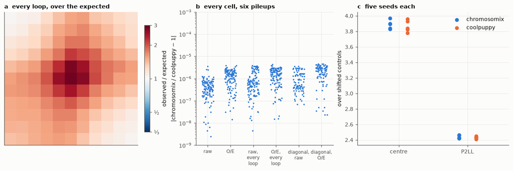

Figure 11: Pileups at chromosight’s loops, mouse Hi-C at 10 kb, ±50 kb. a, every loop over the expected, as chromosomix draws it with `--minDist 0`; the cells towards the lower left are means of fewer loops, those whose windows stay clear of the diagonal there; b, every cell of the six pileups against coolpuppy’s, raw and over the expected (O/E); c, over shifted controls at coolpuppy’s defaults, the centre and P2LL of each tool’s five seeds.

```python
TEXT['apa_loops'] = f'{len(called):,}'
TEXT['apa_reaching'] = f'{reaching:,}'
TEXT['apa_anchors'] = f'{len(anchors):,}'
TEXT['apa_cornered'] = f'{cornered:,}'
TEXT['apa_rel'] = f'{max(v.max() for v in cut_rel.values()):.1e}'
APA_GAPS = all(same_gaps.values())
TEXT['apa_gaps'] = 'the same cells left as gaps' if APA_GAPS else 'different cells left as gaps'
TEXT['apa_cross'] = f'{gap_cross:.3f}'
TEXT['apa_self'] = f'{gap_ref:.3f}'
TEXT['apa_self_app'] = f'{gap_app:.3f}'
TEXT['apa_welch'] = f'{int((welch < 0.01).sum())} of {welch.size}'
APA_WITHIN = by_chance
TEXT['apa_chance'] = (f'about as many as chance gives ({0.01 * welch.size:.1f} expected)' if by_chance
                      else f'more than chance gives ({0.01 * welch.size:.1f} expected)')

fig, axes = plt.subplots(1, 3, figsize=(12, 3.9), layout='constrained', width_ratios=[1, 1, 1.1])
grey = plt.get_cmap('RdBu_r').copy()
grey.set_bad(MISSING)
bar = square(axes[0], cut_app['oe-every'], 'a  every loop, over the expected', cmap=grey, norm=LogNorm(1 / 3, 3),
             label='observed / expected')
bar.set_ticks([1 / 3, 1 / 2, 1, 2, 3], labels=['⅓', '½', '1', '2', '3'])
bar.minorticks_off()
ax = axes[1]
for k, key in enumerate(CUTS):
    values = np.maximum(cut_rel[key], 1e-9)
    ax.scatter(k + np.linspace(-0.25, 0.25, values.size), values, s=6, color=APP_COLOUR, lw=0, gid=CUTS[key][0])
ax.set(yscale='log', ylim=(1e-9, 1e-3), ylabel='|chromosomix / coolpuppy − 1|',
       title='b  every cell, six pileups')
ax.set_xticks(range(len(CUTS)), ['raw', 'O/E', 'raw,\nevery\nloop', 'O/E,\nevery\nloop', 'diagonal,\nraw',
                                  'diagonal,\nO/E'], fontsize=8)
ax = axes[2]
for k, (name, stack, colour) in enumerate((('chromosomix', controls_app, APP_COLOUR), ('coolpuppy', controls_ref, REF))):
    ax.scatter(np.full(len(stack), 0 + (k - 0.5) * 0.25), stack[:, centre, centre], s=30, color=colour, label=name, zorder=3)
    ax.scatter(np.full(len(stack), 1 + (k - 0.5) * 0.25), [p2ll(p) for p in stack], s=30, color=colour, zorder=3,
               gid=name)
ax.set_xticks([0, 1], ['centre', 'P2LL'])
ax.set(xlim=(-0.6, 1.6), ylabel='over shifted controls', title='c  five seeds each')
ax.legend(loc='upper right')
drawn('fig-apa')
```

Raw and over the expected, at coolpuppy’s defaults and with every loop, and on the diagonal both ways, the two tools draw the same cells left as gaps and every other cell within 4.5e-06 (float32, six digits written). At coolpuppy’s floor both leave out the same 1,826 of the 2,515 loops, those near enough that their windows would reach the diagonal; with every loop, a cell near the diagonal is the mean of the loops whose windows have it above the diagonal — the lower-left corner, of 689 of them, in both — and on the diagonal every one of the 4,952 anchors is piled up.

Over shifted controls, a run of each tool and a run of the other differ, in a typical pair, by up to 0.134 in a cell; two runs of coolpuppy by up to 0.151, and two of the app by up to 0.132. Cell by cell, the five seeds of each tool differ at 1 of 121 cells at p < 0.01, about as many as chance gives (1.2 expected).

```python
record('Aggregate peak analysis', f"mouse Hi-C, 10 kb, {TEXT['apa_loops']} loops", f"coolpuppy {VERSIONS['coolpuppy']}",
       f"raw and over the expected, at coolpuppy's defaults and with every loop, and on the diagonal: "
       f"{TEXT['apa_gaps']}, every other cell within "
       f"{TEXT['apa_rel']}; over controls, two runs of the two tools differ as two of coolpuppy do "
       f"({TEXT['apa_cross']} against {TEXT['apa_self']}), and no more cells than chance gives "
       f"({TEXT['apa_welch']} at p < 0.01)",
       ('Identical (float32); controls within the seeds\' spread' if APA_WITHIN else 'Identical; controls differ')
       if APA_GAPS else 'Differ',
       apps=[*[f'apa-{k}' for k in CUTS], *[f'apa-controls-seed{s + 1}' for s in SHIFTS]],
       refs=['chromosight-mouse', *[f'coolpuppy-{k}' for k in CUTS], *[f'coolpuppy-controls-seed{s}' for s in SHIFTS]])
```

## 12 · APA, chromosight’s score

chromosight’s own reading of a loop set: the map detrended by its distance law, a 17-bin window about each loop, correlated with the loop template for a score, and averaged into a pileup. `apa --norm chromosight` is chromosight’s quantification, ported (§18.9); the reference is `chromosight quantify` on the same map and the same loops, its pileup chromosight’s own `pileup_patterns` of the windows it writes.

```python
CSQ = WORK / 'chromosight-quantify'
mr('apa', MOUSE_10K, '--pairs', LOOPS, '--norm', 'chromosight', out=CSQ / 'app', name='apa-chromosight',
   analysis="APA, chromosight's score")
reference('chromosight-quantify', "APA, chromosight's score", 'chromosight',
          [CHROMOSIGHT, 'quantify', '--pattern', 'loops', '--threads', THREADS, LOOPS, MOUSE_10K, OUT],
          out=CSQ / 'quantify', made=CSQ / 'quantify.tsv', threads=THREADS)

import chromosight.utils.detection as chromosight_detection

quantified = pd.read_csv(CSQ / 'quantify.tsv', sep='\t')
scored = table(one(CSQ / 'app', '*.apa-chromosight-anchors.tsv'))
locus = scored['anchor'].str.rsplit(':', n=1)
scored['chrom1'], scored['start1'] = locus.str[0], locus.str[1].str.replace(',', '').astype(int) - 1
scored['start2'] = scored['start1'] + scored['separation']
m = quantified.merge(scored, on=['chrom1', 'start1', 'start2'], how='outer', indicator=True, suffixes=('_ref', '_app'))
paired = m[m['_merge'] == 'both']
finite = np.isfinite(paired['score_ref']) & np.isfinite(paired['score_app'])
windows = json.loads((CSQ / 'quantify.json').read_text())
cs_ref = chromosight_detection.pileup_patterns(np.stack([np.asarray(windows[k], float) for k in sorted(windows, key=int)]))
cs_app = pileup_of(CSQ / 'app', '*.apa-chromosight.tsv')
cs_score = np.abs(paired['score_ref'][finite] - paired['score_app'][finite]).max()
cs_pileup = relative_difference(cs_app, cs_ref).max()
measures({
    'loops, chromosomix / chromosight; the same; in one only':
        f"{len(scored):,} / {len(quantified):,}; {len(paired):,}; {int((m['_merge'] != 'both').sum())}",
    'scored by both; scored by one only': f"{int(finite.sum()):,}; {int((np.isfinite(paired['score_ref']) != np.isfinite(paired['score_app'])).sum())}",
    'score, max |difference| (four decimals written)': f'{cs_score:.1e}',
    'pileup, max relative difference': f'{cs_pileup:.1e}',
})
```

```
$ chromosomix apa data/4DNFIOZ1TRUS.mcool::/resolutions/10000 --pairs apa/loops.bedpe --norm chromosight --out chromosight-quantify/app
$ chromosight quantify --pattern loops --threads 4 apa/loops.bedpe data/4DNFIOZ1TRUS.mcool::/resolutions/10000 chromosight-quantify/quantify
```

| measure | value |
| --- | --- |
| loops, chromosomix / chromosight; the same; in one only | 2,515 / 2,515; 2,515; 0 |
| scored by both; scored by one only | 2,515; 0 |
| score, max \|difference\| (four decimals written) | 5.0e-05 |
| pileup, max relative difference | 4.8e-06 |

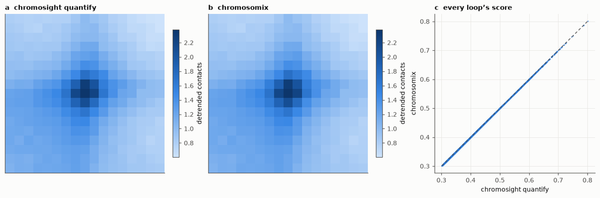

Figure 12: chromosight’s reading of the same loops. a, the pileup chromosight quantify’s windows make; b, chromosomix’s; c, every loop’s score.

```python
TEXT['csq_n'] = f'{int(finite.sum()):,}'
TEXT['csq_score'] = f'{cs_score:.1e}'
TEXT['csq_pileup'] = f'{cs_pileup:.1e}'

fig, axes = plt.subplots(1, 3, figsize=(12, 3.9), layout='constrained')
square(axes[0], cs_ref, 'a  chromosight quantify', label='detrended contacts')
square(axes[1], cs_app, 'b  chromosomix', label='detrended contacts')
ax = axes[2]
ax.scatter(paired['score_ref'], paired['score_app'], s=5, color=APP_COLOUR, alpha=0.5, lw=0, rasterized=True)
identity(ax, np.nanmin(paired['score_ref']), np.nanmax(paired['score_ref']))
ax.set(xlabel='chromosight quantify', ylabel='chromosomix', title='c  every loop’s score')
drawn('fig-chromosight-quantify')
```

The same 2,515 loops are scored, every score within 5.0e-05, the four decimals the app writes, and the pileups agree within 4.8e-06.

```python
record("APA, chromosight's score", f"mouse Hi-C, 10 kb, {TEXT['apa_loops']} loops", f"chromosight {VERSIONS['chromosight']}",
       f"{TEXT['csq_n']} loops scored, within {TEXT['csq_score']}; pileup within {TEXT['csq_pileup']}",
       'Identical', apps=['apa-chromosight'], refs=['chromosight-quantify'])
```

## 13 · Boost-HiC

Boost-HiC (Carron et al. 2019) reads a contact map as a graph whose edges are contacts turned into distances, `1/cᵅ`, and replaces each by the shortest path between its ends: a contact the library was too shallow to see is inferred from the ones around it. It is what an oversample draws a chromosome’s new contacts from (§6.5: `--contacts` above a map’s own total), and `chromosomix boost` writes that map as Boost-HiC’s `main.py` writes its own — the bins its outlier filter keeps, and the boosted map over them in SCN units. Boost-HiC itself is run as `main.py` runs it, through its own `HiCutils`, on the same chromosome’s raw counts. Three chromosomes at 100 kb, the smallest, one between and the largest: Floyd–Warshall is cubic in the bins.

|  | chromosomix | Boost-HiC |
| --- | --- | --- |
| α | 0.2, the default | 0.2, `main.py`’s |
| outliers | a kernel density of the coverage, 5 % and 99.5 %, bandwidth 2,000 | `get_outliers` |
| boost | ten rounds of SCN, Floyd–Warshall on `1/SCNᵅ`, the decay put back | `SCN`, `fastFloyd`, `adjustPdS` |

```python
BH = WORK / 'boost-hic'
BOOSTED = {chrom: int(np.diff(clr100.extent(chrom))[0]) for chrom in ('chr19', 'chr11', 'chr1')}
for chrom, n in BOOSTED.items():
    label = f'{chrom}, {n:,} bins'
    # Timed on chr1 alone, the largest: the other two are the same computation on fewer bins.
    mr('boost', MOUSE_100K, '--sequences', chrom, out=BH / chrom, name=f'boost-{chrom}', analysis='Boost-HiC',
       label=label, bench=chrom == 'chr1')
    reference(f'boosthic-{chrom}', 'Boost-HiC', 'Boost-HiC', [PYTHON, script('boosthic'), MOUSE_100K, chrom, OUT],
              out=BH / f'boosthic-{chrom}', made=BH / f'boosthic-{chrom}-boosted.npy', env=BOOSTHIC_ENV, label=label,
              bench=chrom == 'chr1')

boosted, rows = {}, []
for chrom, n in BOOSTED.items():
    square_ = table(one(BH / chrom, f'*.boost-{chrom}.tsv'))
    app = square_.iloc[:, 1:].to_numpy(float)
    kept_app = (square_.iloc[:, 0].to_numpy() // clr100.binsize).astype(int)
    kept_ref = np.load(BH / f'boosthic-{chrom}-kept.npy')
    ref = np.load(BH / f'boosthic-{chrom}-boosted.npy')
    same = np.array_equal(kept_app, kept_ref)
    boosted[chrom] = dict(app=app, ref=ref, kept=kept_ref, same=same)
    rows.append({'chromosome': chrom, 'bins': n, 'kept, chromosomix / Boost-HiC': f'{len(kept_app):,} / {len(kept_ref):,}',
                 'the same bins': 'yes' if same else 'no',
                 'cells': app.size if same else np.nan,
                 'max relative difference': relative_difference(app, ref).max() if same else np.nan})
boost_table = pd.DataFrame(rows)
show(boost_table, **{'max relative difference': '{:.1e}', 'cells': '{:,.0f}', 'bins': '{:,}'})
```

```
$ chromosomix boost data/4DNFIOZ1TRUS.mcool::/resolutions/100000 --sequences chr19 --out boost-hic/chr19
$ python ../../scripts/boosthic.py data/4DNFIOZ1TRUS.mcool::/resolutions/100000 chr19 boost-hic/boosthic-chr19
$ chromosomix boost data/4DNFIOZ1TRUS.mcool::/resolutions/100000 --sequences chr11 --out boost-hic/chr11
$ python ../../scripts/boosthic.py data/4DNFIOZ1TRUS.mcool::/resolutions/100000 chr11 boost-hic/boosthic-chr11
$ chromosomix boost data/4DNFIOZ1TRUS.mcool::/resolutions/100000 --sequences chr1 --out boost-hic/chr1
$ python ../../scripts/boosthic.py data/4DNFIOZ1TRUS.mcool::/resolutions/100000 chr1 boost-hic/boosthic-chr1
```

| chromosome | bins | kept, chromosomix / Boost-HiC | the same bins | cells | max relative difference |
| --- | --- | --- | --- | --- | --- |
| chr19 | 615 | 578 / 578 | yes | 334,084 | 5.0e-10 |
| chr11 | 1,221 | 1,186 / 1,186 | yes | 1,406,596 | 5.0e-10 |
| chr1 | 1,955 | 1,914 / 1,914 | yes | 3,663,396 | 5.0e-10 |

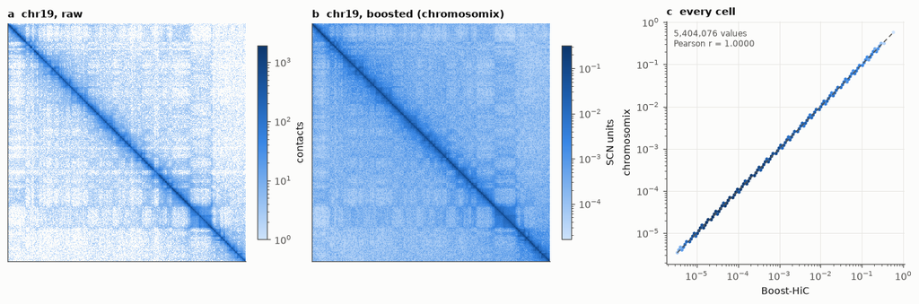

Figure 13: Boost-HiC at 100 kb. a, chr19’s raw counts over the bins Boost-HiC keeps; b, the boosted map chromosomix writes, in SCN units; c, every cell of the three chromosomes, chromosomix against Boost-HiC.

```python
BOOST_SAME = boost_table['the same bins'].eq('yes').all()
TEXT['bh_cells'] = f"{int(boost_table['cells'].sum()):,}"
TEXT['bh_max'] = f"{boost_table['max relative difference'].max():.1e}"
TEXT['bh_kept'] = ('Both keep the same bins on every chromosome' if BOOST_SAME
                   else 'The two keep different bins on ' + ', '.join(boost_table.loc[boost_table['the same bins'] == 'no', 'chromosome']))

fig, axes = plt.subplots(1, 3, figsize=(12, 3.9), layout='constrained')
v = boosted['chr19']
counts = np.asarray(clr100.matrix(balance=False).fetch('chr19'), float)[np.ix_(v['kept'], v['kept'])]
square(axes[0], np.where(counts > 0, counts, np.nan), 'a  chr19, raw', norm=LogNorm(), label='contacts')
square(axes[1], v['app'], 'b  chr19, boosted (chromosomix)', norm=LogNorm(), label='SCN units')
agreement(axes[2], np.concatenate([b['ref'].ravel() for b in boosted.values()]),
          np.concatenate([b['app'].ravel() for b in boosted.values()]), 'Boost-HiC', 'chromosomix',
          'c  every cell', scale='log')
drawn('fig-boost')
```

Both keep the same bins on every chromosome, and over the 5,404,076 cells of the chromosomes where they are the same the boosted maps agree within 5.0e-10, the ten digits `chromosomix boost` writes.

```python
record('Boost-HiC', 'mouse Hi-C, 100 kb, chr19, chr11, chr1', f"Boost-HiC (GitHub {PROGRAMS['Boost-HiC (GitHub)']})",
       f"the same bins kept; {TEXT['bh_cells']} cells within {TEXT['bh_max']}",
       'Identical' if BOOST_SAME else 'Differs', apps=[f'boost-{c}' for c in BOOSTED],
       refs=[f'boosthic-{c}' for c in BOOSTED])
```

## 14 · Metaplot (deepTools)

The mean of a track about a set of features: replicate 1 of the mouse ATAC-seq, the whole genome, about the TSS of every RefSeq transcript, ±2 kb in 50 bp bins, a minus-strand window read backwards. deepTools’ `computeMatrix reference-point` reads every base of a window (`pyBigWig.values`) and averages the ones the track covers bin by bin, as the app does; deepTools’ profile is `plotProfile`’s, each bin’s mean over the transcripts with a value there. The app ranks its rows, one per transcript, by their mean and deepTools keeps the BED’s order, so rows are paired by that ranking, rows of the same mean in whichever order matches.

|  | chromosomix | deepTools |
| --- | --- | --- |
| anchor | `--mode reference --at start`, stranded (the default) | `reference-point --referencePoint TSS` |
| window | `--flank 2000 --step 50` | `-b 2000 -a 2000 --binSize 50` |
| average | the mean (the default), no band (`--band none`) | `--averageTypeBins mean`; `plotProfile` |

```python
MP = WORK / 'metaplot'
MP.mkdir(parents=True, exist_ok=True)
signal = pyBigWig.open(str(ATAC[0]))
covered = signal.chroms()
signal.close()
TSS_BED = MP / 'transcripts.bed'
TRANSCRIPTS[TRANSCRIPTS['chrom'].isin(covered)][BED6].to_csv(TSS_BED, sep='\t', header=False, index=False)
mr('metaplot', '--tracks', ATAC[0], '--features', TSS_BED, '--mode', 'reference', '--at', 'start', '--flank', 2000,
   '--step', 50, '--band', 'none', out=MP / 'app', name='metaplot', analysis='Metaplot', group='TSS')
reference('computematrix', 'Metaplot', 'deepTools',
          [COMPUTEMATRIX, 'reference-point', '-S', ATAC[0], '-R', TSS_BED, '--referencePoint', 'TSS', '-b', 2000,
           '-a', 2000, '--binSize', 50, '-p', THREADS, '-o', OUT],
          out=MP / 'deeptools.mat.gz', label='computeMatrix', group='TSS', threads=THREADS)
reference('plotprofile', 'Metaplot', 'deepTools',
          [PLOTPROFILE, '-m', MP / 'deeptools.mat.gz', '-out', f'{OUT}.png', '--outFileNameData', f'{OUT}.tab'],
          out=MP / 'deeptools-profile', made=MP / 'deeptools-profile.tab', label='plotProfile', group='TSS')

profile_app = table(one(MP / 'app', '*.metaplot.tsv'))
profile_ref = pd.read_csv(MP / 'deeptools-profile.tab', sep='\t', header=None, skiprows=2).iloc[0, 2:].to_numpy(float)
offsets = profile_app.iloc[:, 0].to_numpy(float)
profile_app = profile_app.iloc[:, 1].to_numpy(float)
rows_app = table(one(MP / 'app', '*.metaplot-heatmap.tsv')).iloc[:, 1:].to_numpy(float)
rows_ref = pd.read_csv(MP / 'deeptools.mat.gz', sep='\t', header=None, skiprows=1).iloc[:, 6:].to_numpy(float)


def written(ref):
    """What two writers' rounding allows: the app's six significant digits, deepTools' six decimals."""
    return 5e-7 + 5e-6 * np.abs(ref)


def paired_rows(app, ref):
    """For each of the app's rows, strongest first, the deepTools row paired with it: of those whose mean
    is the same within the rounding, the unpaired one closest to it."""
    def strength(rows):
        with np.errstate(invalid='ignore'):
            means = np.nanmean(rows, axis=1)
        return np.where(np.isnan(means), -np.inf, means)
    mine, theirs = strength(app), strength(ref)
    order = np.argsort(theirs, kind='stable')
    sorted_ = theirs[order]
    used, match = np.zeros(len(ref), bool), np.empty(len(app), int)
    for i, row in enumerate(app):
        slack = 1e-5 * abs(mine[i]) + 1e-6 if np.isfinite(mine[i]) else 0
        lo, hi = np.searchsorted(sorted_, mine[i] - slack, 'left'), np.searchsorted(sorted_, mine[i] + slack, 'right')
        candidates = order[lo:hi][~used[order[lo:hi]]]
        if len(candidates) == 0:
            candidates = np.flatnonzero(~used)
        pick = candidates[int(np.argmin(past(row, ref[candidates]).max(axis=1)))]
        used[pick], match[i] = True, pick
    return match


def past(app, ref):
    """How far each cell is past the two writers' rounding (≤ 0: within it); two gaps are within it."""
    excess = np.abs(app - ref) - written(ref)
    excess = np.where(np.isnan(app) & np.isnan(ref), -1.0, excess)
    return np.where(np.isnan(excess), np.inf, excess)


match = cached(MP / 'paired.npy', lambda: paired_rows(rows_app, rows_ref)).astype(int)
row_excess = past(rows_app, rows_ref[match])
profile_rel = relative_difference(profile_app, profile_ref).max()
measures({
    'transcripts, chromosomix / deepTools': f'{len(rows_app):,} / {len(rows_ref):,}',
    'profile, max relative difference': f'{profile_rel:.1e}',
    'rows paired one to one': 'every one' if len(set(match)) == len(match) == len(rows_ref) else 'not every one',
    'cells past both tools\' rounding': f'{int((row_excess > 0).sum()):,} of {row_excess.size:,}',
})
```

```
$ chromosomix metaplot --tracks data/4DNFIIY4QW2D.bw --features metaplot/transcripts.bed --mode reference --at start --flank 2000 --step 50 --band none --out metaplot/app
$ computeMatrix reference-point -S data/4DNFIIY4QW2D.bw -R metaplot/transcripts.bed --referencePoint TSS -b 2000 -a 2000 --binSize 50 -p 4 -o metaplot/deeptools.mat.gz
$ plotProfile -m metaplot/deeptools.mat.gz -out metaplot/deeptools-profile.png --outFileNameData metaplot/deeptools-profile.tab
```

| measure | value |
| --- | --- |
| transcripts, chromosomix / deepTools | 35,034 / 35,034 |
| profile, max relative difference | 4.7e-06 |
| rows paired one to one | every one |
| cells past both tools' rounding | 0 of 2,802,720 |

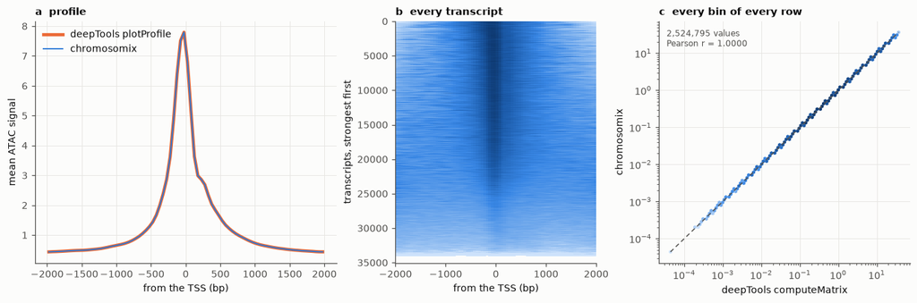

Figure 14: ATAC-seq about RefSeq TSS. a, the profile; b, chromosomix’s rows, strongest first, each line the mean of 100; c, every cell of every row against deepTools’ row paired with it.

```python
TEXT['mp_n'] = f'{len(rows_app):,}'
TEXT['mp_profile'] = f'{profile_rel:.1e}'
TEXT['mp_cells'] = f'{int((row_excess > 0).sum()):,}'
METAPLOT_OK = int((row_excess > 0).sum()) == 0 and len(set(match)) == len(rows_ref)
TEXT['mp_rows'] = ('every one of the' if METAPLOT_OK else 'not every one of the')
#: How many of a heatmap's rows each line of its picture is the mean of. A picture a few hundred pixels
#: high shows tens of thousands of rows only by leaving most of them out; it draws their means instead.
POOL = 100


def pictured(rows):
    """A heatmap as its picture draws it: each run of POOL rows, in order, as their mean."""
    return np.array([np.nanmean(rows[k:k + POOL], axis=0) for k in range(0, len(rows), POOL)])


fig, axes = plt.subplots(1, 3, figsize=(12, 3.9), layout='constrained', width_ratios=[1.2, 0.8, 1])
ax = axes[0]
ax.plot(offsets, profile_ref, color=REF, lw=3, label='deepTools plotProfile')
ax.plot(offsets, profile_app, color=APP_COLOUR, lw=1.2, label='chromosomix')
ax.set(xlabel='from the TSS (bp)', ylabel='mean ATAC signal', title='a  profile')
ax.legend(loc='upper left')
ax = axes[1]
ax.imshow(pictured(rows_app), aspect='auto', cmap=DENSITY, norm=LogNorm(0.05, np.nanpercentile(rows_app, 99.5)),
          interpolation='nearest', extent=[offsets[0] - 25, offsets[-1] + 25, len(rows_app), 0])
ax.set(xlabel='from the TSS (bp)', ylabel='transcripts, strongest first', title='b  every transcript')
ax.grid(False)
agreement(axes[2], rows_ref[match].ravel(), rows_app.ravel(), 'deepTools computeMatrix', 'chromosomix',
          'c  every bin of every row', scale='log')
drawn('fig-metaplot')
```

The profiles agree within 4.7e-06, the six digits written, and every one of the 35,034 rows has its pair with every bin within the two tools’ rounding (0 cells past it).

**Over two tracks** the app draws a heatmap for each, and lists the transcripts in one order in all of them: by each one’s mean over every bin of every track, strongest first. That is `plotHeatmap`‘s order for a matrix of several samples, whose defaults (`--sortRegions descend --sortUsing mean`) sort by the mean over every sample. So both replicates at once, and the two tools’ rows compared in that order: the app’s two heatmaps side by side against `computeMatrix`’s rows, in the order of the regions `plotHeatmap` writes. A transcript neither track covers has no mean at all; the app puts it last and deepTools first, its descending order being NumPy’s ascending one reversed, and those are compared apart.

|  | chromosomix | deepTools |
| --- | --- | --- |
| tracks | `--tracks`, once for each replicate | `computeMatrix reference-point -S`, both replicates |
| order | the heatmaps’ own | `plotHeatmap --outFileSortedRegions` |

```python
mr('metaplot', '--tracks', ATAC[0], '--tracks', ATAC[1], '--features', TSS_BED, '--mode', 'reference', '--at',
   'start', '--flank', 2000, '--step', 50, '--band', 'none', out=MP / 'app-two', name='metaplot-two',
   analysis='Metaplot', group='TSS, two tracks')
reference('computematrix-two', 'Metaplot', 'deepTools',
          [COMPUTEMATRIX, 'reference-point', '-S', ATAC[0], ATAC[1], '-R', TSS_BED, '--referencePoint', 'TSS',
           '-b', 2000, '-a', 2000, '--binSize', 50, '-p', THREADS, '-o', OUT],
          out=MP / 'deeptools-two.mat.gz', label='computeMatrix', group='TSS, two tracks', threads=THREADS)
reference('plotprofile-two', 'Metaplot', 'deepTools',
          [PLOTPROFILE, '-m', MP / 'deeptools-two.mat.gz', '-out', f'{OUT}.png', '--outFileNameData', f'{OUT}.tab'],
          out=MP / 'deeptools-two-profile', made=MP / 'deeptools-two-profile.tab', label='plotProfile',
          group='TSS, two tracks')
reference('plotheatmap-two', 'Metaplot', 'deepTools',
          [PLOTHEATMAP, '-m', MP / 'deeptools-two.mat.gz', '-out', f'{OUT}.png', '--outFileSortedRegions',
           f'{OUT}.bed'],
          out=MP / 'deeptools-two-heatmap', made=MP / 'deeptools-two-heatmap.bed', label='plotHeatmap',
          group='TSS, two tracks')

curves = table(one(MP / 'app-two', '*.metaplot.tsv'))
profiles_app = curves[[c for c in curves.columns[1:] if not c.endswith(('_low', '_high'))]].to_numpy(float).T
profiles_ref = pd.read_csv(MP / 'deeptools-two-profile.tab', sep='\t', header=None,
                           skiprows=2).iloc[:, 2:].to_numpy(float)
# The two heatmaps side by side, as computeMatrix writes two samples: a row's bins of the first, then the second's.
heatmaps = [table(one(MP / 'app-two', f'*.{name}.tsv')).iloc[:, 1:].to_numpy(float)
            for name in ('metaplot-heatmap', 'metaplot-heatmap-2')]
both_app = np.hstack(heatmaps)
regions = pd.read_csv(MP / 'deeptools-two.mat.gz', sep='\t', header=None, skiprows=1)
both_ref = regions.iloc[:, 6:].to_numpy(float)


def place(frame):
    """A region of a deepTools table by its coordinates, name and strand."""
    return frame[0].astype(str) + ':' + frame[1].astype(str) + '-' + frame[2].astype(str) + ' ' + frame[3] + frame[5]


# plotHeatmap's order: the regions it wrote, top to bottom, each found among computeMatrix's rows.
listed = pd.read_csv(MP / 'deeptools-two-heatmap.bed', sep='\t', header=None, comment='#')
order_ref = pd.Series(np.arange(len(regions)), index=place(regions))[place(listed)].to_numpy()
with np.errstate(invalid='ignore'):
    key_app, key_ref = np.nanmean(both_app, axis=1), np.nanmean(both_ref[order_ref], axis=1)
none_app, none_ref = np.isnan(key_app), np.isnan(key_ref)
uncovered = int(none_app.sum())
# Each tool's covered rows in its own order, held position by position to the other's: the app's uncovered
# rows are its last, deepTools' its first.
order_same = bool(none_ref.sum() == uncovered and none_app[len(none_app) - uncovered:].all()
                  and none_ref[:uncovered].all()
                  and (np.abs(key_app[~none_app] - key_ref[~none_ref]) <= written(key_ref[~none_ref])).all())
match_two = cached(MP / 'paired-two.npy', lambda: paired_rows(both_app, both_ref)).astype(int)
two_excess = past(both_app, both_ref[match_two])
profiles_rel = relative_difference(profiles_app, profiles_ref).max()
measures({
    'transcripts, chromosomix / deepTools': f'{len(both_app):,} / {len(both_ref):,}',
    'profiles, max relative difference': f'{profiles_rel:.1e}',
    'rows paired one to one': 'every one' if len(set(match_two)) == len(match_two) == len(both_ref) else 'not every one',
    'cells of both heatmaps past both tools\' rounding': f'{int((two_excess > 0).sum()):,} of {two_excess.size:,}',
    'order, against plotHeatmap\'s': 'the same' if order_same else 'not the same',
    'transcripts neither track covers': f'{uncovered:,}',
})
```

```
$ chromosomix metaplot --tracks data/4DNFIIY4QW2D.bw --tracks data/4DNFITBRHVZE.bw --features metaplot/transcripts.bed --mode reference --at start --flank 2000 --step 50 --band none --out metaplot/app-two
$ computeMatrix reference-point -S data/4DNFIIY4QW2D.bw data/4DNFITBRHVZE.bw -R metaplot/transcripts.bed --referencePoint TSS -b 2000 -a 2000 --binSize 50 -p 4 -o metaplot/deeptools-two.mat.gz
$ plotProfile -m metaplot/deeptools-two.mat.gz -out metaplot/deeptools-two-profile.png --outFileNameData metaplot/deeptools-two-profile.tab
$ plotHeatmap -m metaplot/deeptools-two.mat.gz -out metaplot/deeptools-two-heatmap.png --outFileSortedRegions metaplot/deeptools-two-heatmap.bed
```

| measure | value |
| --- | --- |
| transcripts, chromosomix / deepTools | 35,034 / 35,034 |
| profiles, max relative difference | 4.7e-06 |
| rows paired one to one | every one |
| cells of both heatmaps past both tools' rounding | 0 of 5,605,440 |
| order, against plotHeatmap's | the same |
| transcripts neither track covers | 1 |

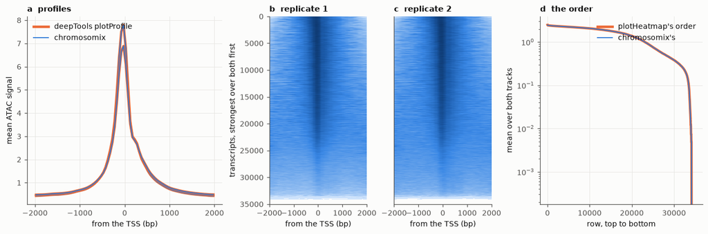

Figure 15: Both replicates about RefSeq TSS. a, each one’s profile; b and c, chromosomix’s two heatmaps, the transcripts in one order in both, each line the mean of 100; d, each row’s mean over both tracks, top to bottom, in chromosomix’s order and in plotHeatmap’s.

```python
TEXT['mp2_profiles'] = f'{profiles_rel:.1e}'
TEXT['mp2_cells'] = f'{int((two_excess > 0).sum()):,}'
TEXT['mp2_uncovered'] = f'{uncovered:,}'
TEXT['mp2_order'] = 'in the same order' if order_same else 'not in the same order'
METAPLOT_TWO_OK = int((two_excess > 0).sum()) == 0 and len(set(match_two)) == len(both_ref) and order_same

fig, axes = plt.subplots(1, 4, figsize=(12, 3.9), layout='constrained', width_ratios=[1.2, 0.6, 0.6, 1])
ax = axes[0]
for i, (mine, theirs) in enumerate(zip(profiles_app, profiles_ref)):
    ax.plot(offsets, theirs, color=REF, lw=3, label='deepTools plotProfile' if i == 0 else None,
            gid=f'deepTools plotProfile, replicate {i + 1}')
    ax.plot(offsets, mine, color=APP_COLOUR, lw=1.2, label='chromosomix' if i == 0 else None,
            gid=f'chromosomix, replicate {i + 1}')
ax.set(xlabel='from the TSS (bp)', ylabel='mean ATAC signal', title='a  profiles')
ax.legend(loc='upper left')
for ax, rows, title in zip(axes[1:3], heatmaps, ('b  replicate 1', 'c  replicate 2')):
    ax.imshow(pictured(rows), aspect='auto', cmap=DENSITY, norm=LogNorm(0.05, np.nanpercentile(rows, 99.5)),
              interpolation='nearest', extent=[offsets[0] - 25, offsets[-1] + 25, len(rows), 0])
    ax.set(xlabel='from the TSS (bp)', title=title)
    ax.grid(False)
axes[1].set_ylabel('transcripts, strongest over both first')
axes[2].set_yticks([])
ax = axes[3]
ax.plot(key_ref[~none_ref], color=REF, lw=3, label="plotHeatmap's order")
ax.plot(key_app[~none_app], color=APP_COLOUR, lw=1.2, label="chromosomix's")
ax.set(yscale='log', xlabel='row, top to bottom', ylabel='mean over both tracks', title='d  the order')
ax.legend(loc='upper right')
drawn('fig-metaplot-two')
```

Both profiles agree within 4.7e-06; every row of the two heatmaps has its pair among `computeMatrix`‘s, both tracks’ bins within the two tools’ rounding (0 cells past it); and the rows are in the same order as `plotHeatmap`’s, each one’s mean over both tracks within that rounding of the mean of the row deepTools puts there, with the 1 transcripts neither replicate covers at the other end.

```python
record('Metaplot', 'mouse ATAC-seq, one and two replicates, whole genome, RefSeq TSS ±2 kb',
       f"deepTools {VERSIONS['deeptools']}",
       f"profiles within {max(profile_rel, profiles_rel):.1e}; {TEXT['mp_n']} rows a track, paired one to one "
       "within the rounding; over two tracks, plotHeatmap's order",
       'Identical' if METAPLOT_OK and METAPLOT_TWO_OK else 'Differs', apps=['metaplot', 'metaplot-two'],
       refs=['computematrix', 'plotprofile', 'computematrix-two', 'plotprofile-two', 'plotheatmap-two'])
```

## 15 · Interval overlap (bedtools)

How much two interval sets share: in bases, with a Jaccard index over them, and in features, those of each set that touch the other. Each tool merges a set’s own overlaps first. The sets are the ATAC-seq peaks of § 5, yapc’s at IDR ≤ 0.05 on chr19, and the promoters on chr19, 1 kb either side of every RefSeq TSS. Then the null the app sets an overlap against: the peaks moved at random, each within its own chromosome and keeping its length, a thousand times — what `bedtools shuffle -chrom` does. Two random draws, so the two nulls are compared as distributions.

|  | chromosomix | bedtools |
| --- | --- | --- |
| observed | `overlap --a peaks --b promoters` | `jaccard`; `intersect -u`, both ways |
| null | `--shuffle --iterations 1000` | `shuffle -chrom -seed 1…1000`, then the same |
| lengths | mm10’s, from `--sequence` | mm10’s, as a genome file |

```python
OV = WORK / 'overlap'
OV.mkdir(parents=True, exist_ok=True)
PEAKS_BED = SEEDS[0] / 'yapc_0.05.bed'
PROMOTERS = OV / 'promoters.bed'
GENOME = OV / 'mm10.genome'
promoters = TRANSCRIPTS.assign(start=np.maximum(0, TSS - 1000), end=TSS + 1000)
promoters[promoters['chrom'] == 'chr19'].sort_values(['start', 'end'])[BED6].to_csv(
    PROMOTERS, sep='\t', header=False, index=False)
pd.read_csv(f'{MM10}.fai', sep='\t', header=None, usecols=[0, 1]).to_csv(GENOME, sep='\t', header=False, index=False)
ITERATIONS = 1000
mr('overlap', '--sequence', MM10, '--features', PEAKS_BED, '--features', PROMOTERS, '--a', PEAKS_BED,
   '--b', PROMOTERS, '--shuffle', '--iterations', ITERATIONS, '--seed', 1, out=OV / 'app', name='overlap',
   analysis='Interval overlap')
reference('bedtools-overlap', 'Interval overlap', 'bedtools',
          [PYTHON, script('bedtools_overlap'), PEAKS_BED, PROMOTERS, GENOME, ITERATIONS, OUT],
          out=OV / 'bedtools', made=OV / 'bedtools-null.tsv')

said = table(one(OV / 'app', '*.overlap.tsv')).set_index('measure')
hit = lambda measure: int(re.match(r'([\d,]+) of', said.loc[measure, 'note']).group(1).replace(',', ''))
observed_app = {'intersection': int(said.loc['Shared bases', 'value']), 'union': int(said.loc['Bases in either', 'value']),
                'jaccard': float(said.loc['Jaccard (bases)', 'value']), 'a_hit': hit('First set hit'),
                'b_hit': hit('Second set hit')}
observed_ref = pd.read_csv(OV / 'bedtools-observed.tsv', sep='\t').iloc[0].to_dict()
null_app = table(one(OV / 'app', '*.overlap-null.tsv')).set_index('measure')
null_ref = pd.read_csv(OV / 'bedtools-null.tsv', sep='\t')
NULLS = {'Shared bases': 'intersection', 'Features of the first set hit': 'a_hit'}
rows = []
for measure, column in NULLS.items():
    mean_app = float(null_app.loc[measure, 'expected'])
    sd_app = (float(null_app.loc[measure, 'observed']) - mean_app) / float(null_app.loc[measure, 'z'])
    mean_ref, sd_ref = null_ref[column].mean(), null_ref[column].std()
    rows.append({'null of': measure, 'chromosomix, mean ± sd': f'{mean_app:,.1f} ± {sd_app:,.1f}',
                 'bedtools, mean ± sd': f'{mean_ref:,.1f} ± {sd_ref:,.1f}',
                 'difference of the means, in standard errors': (mean_app - mean_ref) / np.sqrt(
                     (sd_app ** 2 + sd_ref ** 2) / ITERATIONS),
                 'ratio of the sds': sd_app / sd_ref})
null_table = pd.DataFrame(rows)
display(measures({
    'peaks; promoters': f"{len(pd.read_csv(PEAKS_BED, sep='\t', header=None, comment='#')):,}; {sum(1 for _ in open(PROMOTERS)):,}",
    **{f'{k}, chromosomix / bedtools': f'{observed_app[k]:,} / {observed_ref[k]:,}' for k in ('intersection', 'union', 'a_hit', 'b_hit')},
    'Jaccard, chromosomix (four decimals) / bedtools': f"{observed_app['jaccard']} / {observed_ref['jaccard']}",
}))
show(null_table, precision=2)
```

```
$ chromosomix overlap --sequence data/mm10.fa --features yapc/seed0/yapc_0.05.bed --features overlap/promoters.bed --a yapc/seed0/yapc_0.05.bed --b overlap/promoters.bed --shuffle --iterations 1000 --seed 1 --out overlap/app
$ python ../../scripts/bedtools_overlap.py yapc/seed0/yapc_0.05.bed overlap/promoters.bed overlap/mm10.genome 1000 overlap/bedtools
```

| measure | value |
| --- | --- |
| peaks; promoters | 5,666; 1,099 |
| intersection, chromosomix / bedtools | 191,552 / 191,552.0 |
| union, chromosomix / bedtools | 2,693,667 / 2,693,667.0 |
| a_hit, chromosomix / bedtools | 851 / 851.0 |
| b_hit, chromosomix / bedtools | 809 / 809.0 |
| Jaccard, chromosomix (four decimals) / bedtools | 0.0711 / 0.071112 |

| null of | chromosomix, mean ± sd | bedtools, mean ± sd | difference of the means, in standard errors | ratio of the sds |
| --- | --- | --- | --- | --- |
| Shared bases | 33,150.1 ± 2,743.4 | 33,189.8 ± 2,762.4 | -0.32 | 0.99 |
| Features of the first set hit | 161.3 ± 12.7 | 161.4 ± 12.8 | -0.19 | 0.99 |

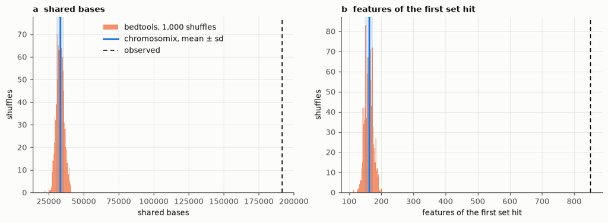

Figure 16: The null of each tool for the bases peaks and promoters share on chr19 (a) and for the peaks on a promoter (b): bedtools’ thousand shuffles, chromosomix’s mean ± sd over its own thousand, and what is observed.

```python
OBSERVED_SAME = all(observed_app[k] == int(observed_ref[k]) for k in ('intersection', 'union', 'a_hit', 'b_hit'))
NULL_SAME = ((null_table['difference of the means, in standard errors'].abs() < 3).all()
             and null_table['ratio of the sds'].between(0.9, 1.1).all())
TEXT['ov_shared'] = f"{observed_app['intersection']:,}"
TEXT['ov_count'] = 'count the same' if OBSERVED_SAME else 'do not count the same'
TEXT['ov_null'] = 'are one distribution' if NULL_SAME else 'differ'
TEXT['ov_union'] = f"{observed_app['union']:,}"
TEXT['ov_hit'] = f"{observed_app['a_hit']:,}"
TEXT['ov_z'] = f"{null_table['difference of the means, in standard errors'].abs().max():.1f}"
TEXT['ov_sd'] = ' to '.join(dict.fromkeys(f'{r:.2f}' for r in sorted(null_table['ratio of the sds'])))

fig, axes = plt.subplots(1, 2, figsize=(10, 3.6), layout='constrained')
for ax, (letter, (measure, column)) in zip(axes, zip('ab', NULLS.items())):
    ax.hist(null_ref[column], bins=40, color=REF, alpha=0.7, label='bedtools, 1,000 shuffles')
    mean_app = float(null_app.loc[measure, 'expected'])
    sd_app = (float(null_app.loc[measure, 'observed']) - mean_app) / float(null_app.loc[measure, 'z'])
    ax.axvspan(mean_app - sd_app, mean_app + sd_app, color=APP_COLOUR, alpha=0.15, lw=0, gid='chromosomix, ± sd')
    ax.axvline(mean_app, color=APP_COLOUR, lw=2, label='chromosomix, mean ± sd')
    ax.axvline(observed_app[column], color=INK, lw=1.2, ls=(0, (4, 3)), label='observed')
    ax.set(xlabel=measure.lower(), ylabel='shuffles', title=f'{letter}  {measure.lower()}')
axes[0].legend(loc='upper center')
drawn('fig-overlap')
```

The two tools count the same: 191,552 bases shared of 2,693,667, and 851 peaks on a promoter, by the app’s count. Their nulls are one distribution: the means differ by at most 0.3 standard errors and the spreads are in a ratio of 0.99.

```python
record('Interval overlap', 'ATAC-seq peaks (§ 5) and promoters, chr19', f"bedtools {PROGRAMS['bedtools']}",
       f"the same bases and features counted; the nulls' means within {TEXT['ov_z']} standard errors",
       ('Identical' if OBSERVED_SAME else 'Differs') + ('; the same null' if NULL_SAME else '; nulls differ'),
       apps=['overlap'], refs=['bedtools-overlap'])
```

## 16 · Base composition

GC content and GC skew in 10 kb bins along mm10: `chromosomix composition` against bioframe’s `frac_gc`, G and C over the bases that are not N, and Biopython’s `GC_skew`, (G − C)/(G + C). Biopython writes 0 for a bin with neither G nor C, where the app writes no value. The app reads mm10 through the `.fai` beside it, a few megabases at a time and none of them kept, and counts the bases a 32-bit word at a time; bioframe and Biopython read it through pyfaidx, bioframe a bin at a time and Biopython a chromosome at a time.

```python
COMP = WORK / 'composition'
mr('composition', '--sequence', MM10, '--resolution', 10_000, out=COMP / 'app', name='composition',
   analysis='Base composition')
reference('composition', 'Base composition', 'bioframe, Biopython',
          [PYTHON, script('composition'), MM10, 10_000, OUT], out=COMP / 'reference.tsv')

composition = pd.read_csv(COMP / 'reference.tsv', sep='\t')
for track, column in (('gc', 'gc_app'), ('gcskew', 'skew_app')):
    written_ = pd.read_csv(one(COMP / 'app', f'*.composition-{track}.bedGraph'), sep='\t', comment='#', header=None,
                           names=['chrom', 'start', 'end', column])
    composition = composition.merge(written_[['chrom', 'start', column]], on=['chrom', 'start'], how='left')
gc_app, gc_ref = composition['gc_app'].to_numpy(float), composition['GC'].to_numpy(float)
skew_app, skew_ref = composition['skew_app'].to_numpy(float), composition['skew'].to_numpy(float)
gc_both = np.isfinite(gc_app) & np.isfinite(gc_ref)
skew_both = np.isfinite(skew_app) & np.isfinite(skew_ref)
unread = ~np.isfinite(skew_app) & np.isfinite(skew_ref)
measures({
    'bins': f'{len(composition):,}',
    'GC: bins both read; max |difference|': f'{gc_both.sum():,}; {np.abs(gc_app - gc_ref)[gc_both].max():.1e}',
    'GC: bins neither reads (all N); read by one only':
        f"{int((~np.isfinite(gc_app) & ~np.isfinite(gc_ref)).sum()):,}; {int((np.isfinite(gc_app) != np.isfinite(gc_ref)).sum())}",
    'GC skew: bins both read; max |difference|': f'{skew_both.sum():,}; {np.abs(skew_app - skew_ref)[skew_both].max():.1e}',
    'GC skew: bins only Biopython writes, and its value there': f"{int(unread.sum()):,}, {', '.join(f'{v:g}' for v in np.unique(skew_ref[unread]))}",
})
```

```
$ chromosomix composition --sequence data/mm10.fa --resolution 10000 --out composition/app
$ python ../../scripts/composition.py data/mm10.fa 10000 composition/reference.tsv
```

| measure | value |
| --- | --- |
| bins | 272,566 |
| GC: bins both read; max \|difference\| | 264,952; 7.2e-08 |
| GC: bins neither reads (all N); read by one only | 7,614; 0 |
| GC skew: bins both read; max \|difference\| | 264,952; 6.7e-08 |
| GC skew: bins only Biopython writes, and its value there | 7,614, 0 |

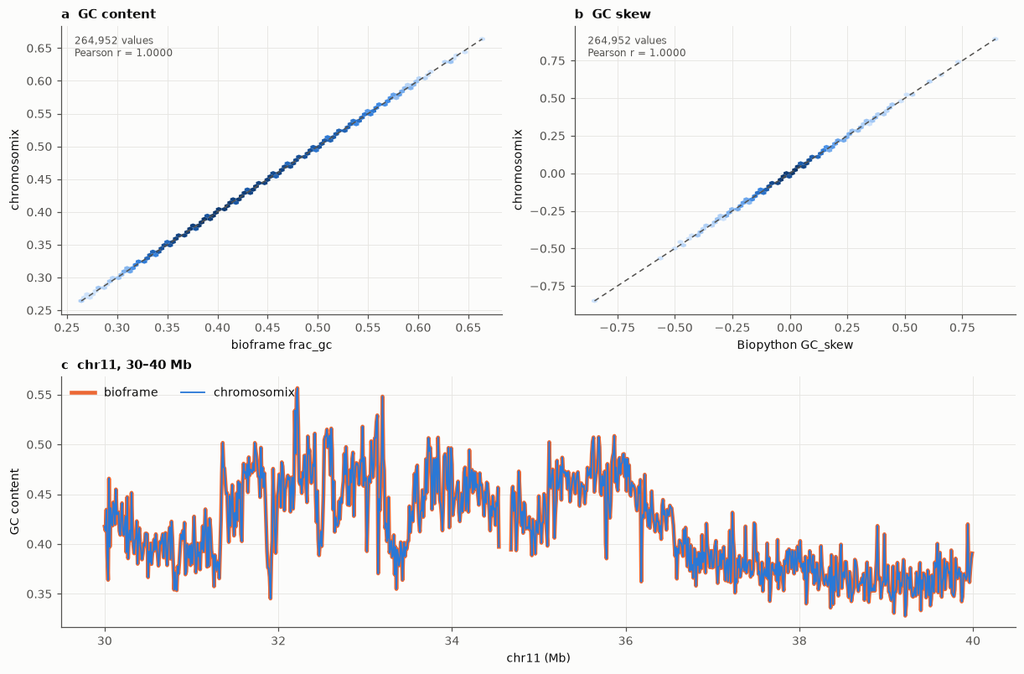

Figure 17: Composition of mm10 in 10 kb bins. a, GC content; b, GC skew; c, GC content along chr11, 30–40 Mb.

```python
TEXT['comp_n'] = f'{gc_both.sum():,}'
TEXT['comp_gc'] = f'{np.abs(gc_app - gc_ref)[gc_both].max():.1e}'
TEXT['comp_skew'] = f'{np.abs(skew_app - skew_ref)[skew_both].max():.1e}'
TEXT['comp_unread'] = f'{int(unread.sum()):,}'
COMP_OK = (np.isfinite(gc_app) == np.isfinite(gc_ref)).all() and (skew_ref[unread] == 0).all()

fig = plt.figure(figsize=(11, 7.2), layout='constrained')
grid = fig.add_gridspec(2, 2, height_ratios=[1.15, 1])
agreement(fig.add_subplot(grid[0, 0]), gc_ref, gc_app, 'bioframe frac_gc', 'chromosomix', 'a  GC content')
agreement(fig.add_subplot(grid[0, 1]), skew_ref[skew_both], skew_app[skew_both], 'Biopython GC_skew', 'chromosomix',
          'b  GC skew')
ax = fig.add_subplot(grid[1, :])
along = composition[(composition['chrom'] == 'chr11') & composition['start'].between(30e6, 40e6 - 1)]
ax.plot(along['start'] / 1e6, along['GC'], color=REF, lw=3, label='bioframe')
ax.plot(along['start'] / 1e6, along['gc_app'], color=APP_COLOUR, lw=1.2, label='chromosomix')
ax.set(xlabel='chr11 (Mb)', ylabel='GC content', title='c  chr11, 30–40 Mb')
ax.legend(loc='upper left', ncols=2)
drawn('fig-composition')
```

Over the 264,952 bins with sequence in them the GC content agrees within 7.2e-08 and the skew within 6.7e-08, the float32 the app writes; the 7,614 bins of N have no skew in the app and 0 in Biopython.

```python
record('Base composition', 'mm10, 10 kb bins', f"bioframe {VERSIONS['bioframe']}, Biopython {VERSIONS['biopython']}",
       f"GC within {TEXT['comp_gc']}, skew within {TEXT['comp_skew']} over {TEXT['comp_n']} bins",
       'Identical (float32)' if COMP_OK else 'Differs', apps=['composition'], refs=['composition'])
```

## 17 · Motif search (seqkit)

Every place a motif occurs on chr19, on both strands, overlapping sites included: the AP-1 site `TGACTCA` allowing one mismatch, and the GATA site `WGATAR`, in IUPAC codes, exactly. Both are given chr19 alone as a FASTA. `seqkit locate` reports a site that reads the same on both strands twice, one per strand, where the app reports it once, as `.`: those are counted on both strands.

|  | chromosomix | seqkit |
| --- | --- | --- |
| strands | both (the default) | both (the default) |
| mismatches | `--mismatches 1` | `-m 1` |
| IUPAC codes | always | `-d` |
| case | ignored | `-i` |

```python
MOTIF = WORK / 'motif'
CHR19_FA = DATA / 'mm10.chr19.fa'
if REDO or not CHR19_FA.exists():
    CHR19_FA.write_text(f">chr19\n{str(pyfaidx.Fasta(str(MM10))['chr19'][:])}\n")
MOTIFS = {'TGACTCA': 1, 'WGATAR': 0}
for pattern, mismatches in MOTIFS.items():
    label = f'{pattern}, ≤ {mismatches} mismatch' if mismatches else pattern
    mr('motif', '--sequence', CHR19_FA, '--pattern', pattern, '--mismatches', mismatches, out=MOTIF / pattern,
       name=f'motif-{pattern}', analysis='Motif search', label=label)
    reference(f'seqkit-{pattern}', 'Motif search', 'seqkit',
              [SEQKIT, 'locate', '-i', *(['-m', mismatches] if mismatches else ['-d']), '-p', pattern, '--bed',
               '-j', THREADS, CHR19_FA, '-o', OUT],
              out=MOTIF / f'seqkit-{pattern}.bed', label=label, threads=THREADS)

SITE = ['chrom', 'start', 'end', 'strand']
found, rows = {}, []
for pattern in MOTIFS:
    app = pd.read_csv(one(MOTIF / pattern, '*.bed'), sep='\t', comment='#', header=None,
                      names=['chrom', 'start', 'end', 'name', 'score', 'strand'])
    app = pd.concat([app[app['strand'] != '.'], *[app[app['strand'] == '.'].assign(strand=s) for s in '+-']])
    ref = pd.read_csv(MOTIF / f'seqkit-{pattern}.bed', sep='\t', header=None,
                      names=['chrom', 'start', 'end', 'name', 'score', 'strand'])
    m = app[SITE].merge(ref[SITE], how='outer', indicator=True)
    found[pattern] = dict(app=app, ref=ref)
    rows.append({'motif': pattern, 'sites, chromosomix / seqkit': f'{len(app):,} / {len(ref):,}',
                 'the same site and strand': int((m['_merge'] == 'both').sum()),
                 'in one only': int((m['_merge'] != 'both').sum())})
motif_table = pd.DataFrame(rows)
show(motif_table, **{'the same site and strand': '{:,}'})
```

```
$ chromosomix motif --sequence data/mm10.chr19.fa --pattern TGACTCA --mismatches 1 --out motif/TGACTCA
$ seqkit locate -i -m 1 -p TGACTCA --bed -j 4 data/mm10.chr19.fa -o motif/seqkit-TGACTCA.bed
$ chromosomix motif --sequence data/mm10.chr19.fa --pattern WGATAR --mismatches 0 --out motif/WGATAR
$ seqkit locate -i -d -p WGATAR --bed -j 4 data/mm10.chr19.fa -o motif/seqkit-WGATAR.bed
```

| motif | sites, chromosomix / seqkit | the same site and strand | in one only |
| --- | --- | --- | --- |
| TGACTCA | 199,858 / 199,858 | 199,858 | 0 |
| WGATAR | 145,681 / 145,681 | 145,681 | 0 |

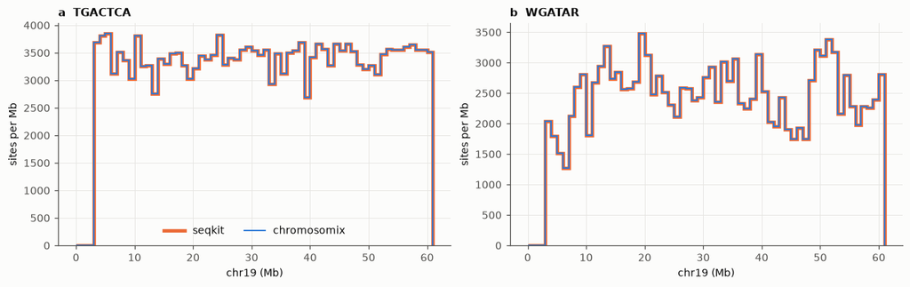

Figure 18: Sites per megabase along chr19, each motif, both strands.

```python
MOTIF_OK = motif_table['in one only'].eq(0).all()
TEXT['motif_sites'] = ' and '.join(f"{n:,}" for n in motif_table['the same site and strand'])
TEXT['motif_only'] = ('and none in one only' if MOTIF_OK
                      else f"and {motif_table['in one only'].sum():,} in one only")

fig, axes = plt.subplots(1, 2, figsize=(11, 3.4), layout='constrained')
edges = np.arange(0, 62e6, 1e6)
for ax, (letter, (pattern, v)) in zip(axes, zip('ab', found.items())):
    ax.stairs(np.histogram(v['ref']['start'], edges)[0], edges / 1e6, color=REF, lw=3, label='seqkit')
    ax.stairs(np.histogram(v['app']['start'], edges)[0], edges / 1e6, color=APP_COLOUR, lw=1.2, label='chromosomix')
    ax.set(xlabel='chr19 (Mb)', ylabel='sites per Mb', title=f'{letter}  {pattern}')
axes[0].legend(loc='lower center', ncols=2)
drawn('fig-motif')
```

The two find the same 199,858 and 145,681 sites, each on the same strand, and none in one only.

```python
record('Motif search', 'mm10 chr19, two motifs, both strands', f"seqkit {PROGRAMS['seqkit']}",
       f"the same {TEXT['motif_sites']} sites", 'Identical' if MOTIF_OK else 'Differs',
       apps=[f'motif-{p}' for p in MOTIFS], refs=[f'seqkit-{p}' for p in MOTIFS])
```

## 18 · Track correlation (deepTools)

How much every pair of three public mouse tracks agrees, over whole windows of 100 bp, 1 kb and 10 kb, by Pearson’s r and by Spearman’s ρ: the two ATAC-seq replicates of § 5, and the diamond insulation score 4DN computed from mouse ES-cell Hi-C (Bonev et al. 2017), one value every 5 kb and none where the map is too sparse to give one. All three are 4DN’s, on mm10, and every tool is given them cut to chr19, interval for interval, as § 5 cuts them. Genome-wide, the two replicates are 1.7 GB of bigWig, and one deepTools summary of them at 100 bp — 27 million windows — took 23 minutes and 4.8 GB here and wrote 1.5 GB of text: a cost the timings would pay at three window sizes, five times over. A window’s value is the mean over the bases a track has a value for, and a window any of the three lacks — here, where the insulation score has no value — is left out of every pair, as deepTools leaves it out. The reference for exactly that is pyBigWig’s own exact mean, `stats(..., exact=True)`, correlated by SciPy over the windows every track has (`notebooks/scripts/pybigwig_correlation.py`). Beside it is deepTools as it is usually run, `multiBigwigSummary bins` then `plotCorrelation`, which differs in one way, measured below: its window means are pyBigWig’s default, read from a zoom level wherever the file has one fine enough.

|  | chromosomix | pyBigWig and SciPy | deepTools |
| --- | --- | --- | --- |
| windows | `--binsize B`, whole windows | whole windows of B | `multiBigwigSummary bins --binSize B` |
| a window’s value | the mean over the bases with a value | `stats(..., exact=True)` | `stats(...)`, from a zoom level where one is fine enough |
| a missing window | left out of every pair | left out of every pair | left out of every pair |
| correlation | `--method pearson`, `spearman` | `scipy.stats.pearsonr`, `spearmanr` | `plotCorrelation -c pearson`, `spearman` |

```python
TC = WORK / 'trackcorr'
# § 5's two replicates as § 5 cut them, and the insulation score cut by the same hand.
INSULATION = DATA / f"{PATHS['4DNFIUJ5CJVN'].stem}.chr19.bw"
chr19(PATHS['4DNFIUJ5CJVN'], INSULATION)
TRACKS = [*REPS, INSULATION]
TRACK_NAMES = [path.name for path in TRACKS]
SHORT = dict(zip(TRACK_NAMES, ('ATAC, rep. 1', 'ATAC, rep. 2', 'insulation')))
SIZES, METHODS = (100, 1_000, 10_000), ('pearson', 'spearman')
CORR = script('pybigwig_correlation')
for size in SIZES:
    # Both methods of each tool in one group: chromosomix answers one per run, deepTools both from
    # one summary of the windows.
    group = f'{size:,} bp windows'
    for method in METHODS:
        mr('trackcorr', '--tracks', ','.join(rel(path) for path in TRACKS), '--binsize', size,
           '--method', method, out=TC / f'app-{size}-{method}', name=f'trackcorr-{size}-{method}',
           analysis='Track correlation', label=f'{size:,} bp, {method}', group=group)
        reference(f'pybigwig-correlation-{size}-{method}', 'Track correlation', 'pyBigWig, SciPy',
                  [PYTHON, CORR, OUT, size, method, *TRACKS], out=TC / f'exact-{size}-{method}.tsv',
                  label=f'{size:,} bp, {method}', group='exact means', bench=False)
    reference(f'multibigwigsummary-{size}', 'Track correlation', 'deepTools',
              [MULTIBIGWIGSUMMARY, 'bins', '-b', *TRACKS, '--binSize', size, '-p', THREADS,
               '-o', OUT + '.npz', '--outRawCounts', OUT + '.tab'],
              out=TC / f'deeptools-{size}', made=TC / f'deeptools-{size}.npz', label=f'{size:,} bp, the windows',
              group=group, threads=THREADS)
    for method in METHODS:
        reference(f'plotcorrelation-{size}-{method}', 'Track correlation', 'deepTools',
                  [PLOTCORRELATION, '-in', TC / f'deeptools-{size}.npz', '-c', method, '-p', 'heatmap',
                   '-o', OUT + '.png', '--outFileCorMatrix', OUT + '.tab'],
                  out=TC / f'deeptools-{size}-{method}', made=TC / f'deeptools-{size}-{method}.tab',
                  label=f'{size:,} bp, {method}', group=group)


def square_of(path):
    """A correlation matrix, its tracks put in one order whatever order the file wrote them in, each
    known by its file's name with or without the `.bw`: chromosomix names a track as the app names
    its row, without it, and the two references with it."""
    frame = pd.read_csv(path, sep='\t', comment='#', index_col=0)
    frame.index = [track_name(label) for label in frame.index]
    frame.columns = [track_name(label) for label in frame.columns]
    order = [track_name(label) for label in TRACK_NAMES]
    return frame.loc[order, order].to_numpy(float)


def exact_windows(size):
    """Every track's exact mean over each whole window, by pyBigWig itself: one column a track."""
    def compute():
        handles = [pyBigWig.open(str(path)) for path in TRACKS]
        chroms = handles[0].chroms()
        return np.stack([np.concatenate([np.array(h.stats(c, 0, (n := chroms[c] // size) * size, nBins=n, exact=True),
                                                  dtype=float) for c in chroms if chroms[c] // size > 0])
                         for h in handles], axis=1)
    return cached(TC / f'exact-windows-{size}.npy', compute)


def correlated(columns, method, together=True):
    """Every pair's coefficient: over the windows every track has, or over the pair's own windows."""
    measure = stats.pearsonr if method == 'pearson' else stats.spearmanr
    rows = np.isfinite(columns).all(axis=1) if together else None
    out = []
    for a, b in combinations(range(columns.shape[1]), 2):
        keep = rows if together else np.isfinite(columns[:, a]) & np.isfinite(columns[:, b])
        out.append(measure(columns[keep, a], columns[keep, b])[0])
    return np.array(out)


UPPER = np.triu_indices(len(TRACK_NAMES), 1)
tc_rows, tc = [], {}
for size in SIZES:
    exact_cols = exact_windows(size)
    raw = pd.read_csv(TC / f'deeptools-{size}.tab', sep='\t')
    raw.columns = [str(c).strip("#'") for c in raw.columns]
    deep_cols = raw.loc[(raw['end'] - raw['start']) == size, TRACK_NAMES].to_numpy(float)
    for method in METHODS:
        app = square_of(one(TC / f'app-{size}-{method}', '*.trackcorr.tsv'))[UPPER]
        exact = square_of(TC / f'exact-{size}-{method}.tsv')[UPPER]
        deep = square_of(TC / f'deeptools-{size}-{method}.tab')[UPPER]
        own = correlated(exact_cols, method, together=False)
        tc[size, method] = dict(app=app, exact=exact, deep=deep, own=own)
        tc_rows.append({'windows': f'{size:,} bp', 'method': method, 'pairs': len(app),
                        'left out': f'{(~np.isfinite(exact_cols).all(axis=1)).sum():,} of {len(exact_cols):,}',
                        'chromosomix vs exact, max |Δ|': np.abs(app - exact).max(),
                        'deepTools vs exact, max |Δ|': np.abs(deep - exact).max(),
                        'each pair over its own windows, max |Δ|': np.abs(own - exact).max()})
TC_TABLE = pd.DataFrame(tc_rows)
show(TC_TABLE, **{c: '{:.1e}' for c in TC_TABLE.columns if 'Δ' in c or '…' in c})
```

```
$ chromosomix trackcorr --tracks data/4DNFIIY4QW2D.chr19.bw,data/4DNFITBRHVZE.chr19.bw,data/4DNFIUJ5CJVN.chr19.bw --binsize 100 --method pearson --out trackcorr/app-100-pearson
$ python ../../scripts/pybigwig_correlation.py trackcorr/exact-100-pearson.tsv 100 pearson data/4DNFIIY4QW2D.chr19.bw data/4DNFITBRHVZE.chr19.bw data/4DNFIUJ5CJVN.chr19.bw
$ chromosomix trackcorr --tracks data/4DNFIIY4QW2D.chr19.bw,data/4DNFITBRHVZE.chr19.bw,data/4DNFIUJ5CJVN.chr19.bw --binsize 100 --method spearman --out trackcorr/app-100-spearman
$ python ../../scripts/pybigwig_correlation.py trackcorr/exact-100-spearman.tsv 100 spearman data/4DNFIIY4QW2D.chr19.bw data/4DNFITBRHVZE.chr19.bw data/4DNFIUJ5CJVN.chr19.bw
$ multiBigwigSummary bins -b data/4DNFIIY4QW2D.chr19.bw data/4DNFITBRHVZE.chr19.bw data/4DNFIUJ5CJVN.chr19.bw --binSize 100 -p 4 -o trackcorr/deeptools-100.npz --outRawCounts trackcorr/deeptools-100.tab
$ plotCorrelation -in trackcorr/deeptools-100.npz -c pearson -p heatmap -o trackcorr/deeptools-100-pearson.png --outFileCorMatrix trackcorr/deeptools-100-pearson.tab
$ plotCorrelation -in trackcorr/deeptools-100.npz -c spearman -p heatmap -o trackcorr/deeptools-100-spearman.png --outFileCorMatrix trackcorr/deeptools-100-spearman.tab
$ chromosomix trackcorr --tracks data/4DNFIIY4QW2D.chr19.bw,data/4DNFITBRHVZE.chr19.bw,data/4DNFIUJ5CJVN.chr19.bw --binsize 1000 --method pearson --out trackcorr/app-1000-pearson
$ python ../../scripts/pybigwig_correlation.py trackcorr/exact-1000-pearson.tsv 1000 pearson data/4DNFIIY4QW2D.chr19.bw data/4DNFITBRHVZE.chr19.bw data/4DNFIUJ5CJVN.chr19.bw
$ chromosomix trackcorr --tracks data/4DNFIIY4QW2D.chr19.bw,data/4DNFITBRHVZE.chr19.bw,data/4DNFIUJ5CJVN.chr19.bw --binsize 1000 --method spearman --out trackcorr/app-1000-spearman
$ python ../../scripts/pybigwig_correlation.py trackcorr/exact-1000-spearman.tsv 1000 spearman data/4DNFIIY4QW2D.chr19.bw data/4DNFITBRHVZE.chr19.bw data/4DNFIUJ5CJVN.chr19.bw
$ multiBigwigSummary bins -b data/4DNFIIY4QW2D.chr19.bw data/4DNFITBRHVZE.chr19.bw data/4DNFIUJ5CJVN.chr19.bw --binSize 1000 -p 4 -o trackcorr/deeptools-1000.npz --outRawCounts trackcorr/deeptools-1000.tab
$ plotCorrelation -in trackcorr/deeptools-1000.npz -c pearson -p heatmap -o trackcorr/deeptools-1000-pearson.png --outFileCorMatrix trackcorr/deeptools-1000-pearson.tab
$ plotCorrelation -in trackcorr/deeptools-1000.npz -c spearman -p heatmap -o trackcorr/deeptools-1000-spearman.png --outFileCorMatrix trackcorr/deeptools-1000-spearman.tab
$ chromosomix trackcorr --tracks data/4DNFIIY4QW2D.chr19.bw,data/4DNFITBRHVZE.chr19.bw,data/4DNFIUJ5CJVN.chr19.bw --binsize 10000 --method pearson --out trackcorr/app-10000-pearson
$ python ../../scripts/pybigwig_correlation.py trackcorr/exact-10000-pearson.tsv 10000 pearson data/4DNFIIY4QW2D.chr19.bw data/4DNFITBRHVZE.chr19.bw data/4DNFIUJ5CJVN.chr19.bw
$ chromosomix trackcorr --tracks data/4DNFIIY4QW2D.chr19.bw,data/4DNFITBRHVZE.chr19.bw,data/4DNFIUJ5CJVN.chr19.bw --binsize 10000 --method spearman --out trackcorr/app-10000-spearman
$ python ../../scripts/pybigwig_correlation.py trackcorr/exact-10000-spearman.tsv 10000 spearman data/4DNFIIY4QW2D.chr19.bw data/4DNFITBRHVZE.chr19.bw data/4DNFIUJ5CJVN.chr19.bw
$ multiBigwigSummary bins -b data/4DNFIIY4QW2D.chr19.bw data/4DNFITBRHVZE.chr19.bw data/4DNFIUJ5CJVN.chr19.bw --binSize 10000 -p 4 -o trackcorr/deeptools-10000.npz --outRawCounts trackcorr/deeptools-10000.tab
$ plotCorrelation -in trackcorr/deeptools-10000.npz -c pearson -p heatmap -o trackcorr/deeptools-10000-pearson.png --outFileCorMatrix trackcorr/deeptools-10000-pearson.tab
$ plotCorrelation -in trackcorr/deeptools-10000.npz -c spearman -p heatmap -o trackcorr/deeptools-10000-spearman.png --outFileCorMatrix trackcorr/deeptools-10000-spearman.tab
```

| windows | method | pairs | left out | chromosomix vs exact, max \|Δ\| | deepTools vs exact, max \|Δ\| | each pair over its own windows, max \|Δ\| |
| --- | --- | --- | --- | --- | --- | --- |
| 100 bp | pearson | 3 | 45,715 of 614,315 | 2.8e-07 | 2.9e-05 | 1.1e-03 |
| 100 bp | spearman | 3 | 45,715 of 614,315 | 4.5e-07 | 1.9e-05 | 5.5e-02 |
| 1,000 bp | pearson | 3 | 4,571 of 61,431 | 4.0e-07 | 2.0e-03 | 1.7e-03 |
| 1,000 bp | spearman | 3 | 4,571 of 61,431 | 1.1e-07 | 6.6e-03 | 4.9e-02 |
| 10,000 bp | pearson | 3 | 451 of 6,143 | 1.5e-07 | 2.7e-02 | 1.2e-02 |
| 10,000 bp | spearman | 3 | 451 of 6,143 | 3.9e-07 | 1.7e-02 | 2.4e-02 |

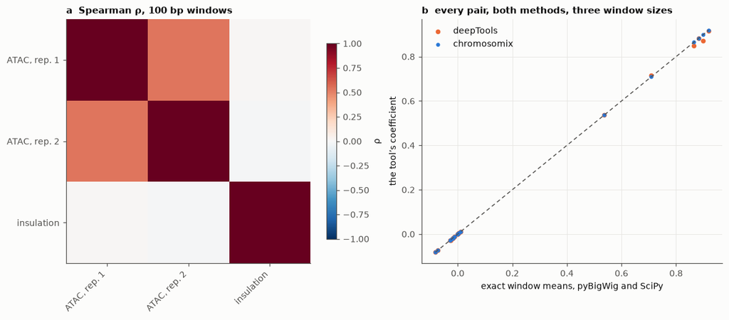

Figure 19: Three mouse tracks on chr19, correlated. a, Spearman’s ρ over 100 bp windows, as chromosomix draws it; b, every coefficient of both methods at all three window sizes against the exact reference — chromosomix in blue, deepTools in orange.

```python
TEXT['tc_n'] = f"{sum(len(v['app']) for v in tc.values())}"
TEXT['tc_app'] = f"{TC_TABLE['chromosomix vs exact, max |Δ|'].max():.1e}"
TEXT['tc_deep'] = f"{TC_TABLE['deepTools vs exact, max |Δ|'].max():.3f}"
TEXT['tc_deep_100'] = f"{TC_TABLE.loc[TC_TABLE['windows'] == '100 bp', 'deepTools vs exact, max |Δ|'].max():.1e}"
TEXT['tc_rule'] = f"{TC_TABLE['each pair over its own windows, max |Δ|'].max():.3f}"
TEXT['tc_left'] = TC_TABLE.loc[TC_TABLE['windows'] == '100 bp', 'left out'].iloc[0]
# The two replicates, Spearman at 100 bp: the pair the rule moves, over every track's windows and
# over their own.
REPLICATES = list(combinations(range(len(TRACK_NAMES)), 2)).index((0, 1))
TEXT['tc_reps'] = f"{tc[100, 'spearman']['exact'][REPLICATES]:.3f}"
TEXT['tc_reps_own'] = f"{tc[100, 'spearman']['own'][REPLICATES]:.3f}"
TC_EXACT = TC_TABLE['chromosomix vs exact, max |Δ|'].max() < 1e-5

fig, axes = plt.subplots(1, 2, figsize=(11, 4.6), layout='constrained', width_ratios=[1.05, 1])
ax = axes[0]
heat = square_of(one(TC / 'app-100-spearman', '*.trackcorr.tsv'))
image = ax.imshow(heat, cmap='RdBu_r', vmin=-1, vmax=1)
short = [SHORT[name] for name in TRACK_NAMES]
ax.set_xticks(range(len(short)), short, rotation=45, ha='right')
ax.set_yticks(range(len(short)), short)
ax.grid(False)
ax.set_title('a  Spearman ρ, 100 bp windows')
plt.colorbar(image, ax=ax, shrink=0.8, label='ρ')
ax = axes[1]
exact_all = np.concatenate([v['exact'] for v in tc.values()])
ax.scatter(exact_all, np.concatenate([v['deep'] for v in tc.values()]), s=16, color=REF, label='deepTools', zorder=2)
ax.scatter(exact_all, np.concatenate([v['app'] for v in tc.values()]), s=10, color=APP_COLOUR, label='chromosomix', zorder=3)
identity(ax, exact_all.min(), exact_all.max())
ax.set(xlabel='exact window means, pyBigWig and SciPy', ylabel='the tool’s coefficient',
       title='b  every pair, both methods, three window sizes')
ax.legend(loc='upper left')
drawn('fig-trackcorr')
```

All 18 coefficients from chromosomix agree with the exact reference within 4.5e-07, the six digits it writes, over the same windows: at 100 bp, 45,715 of 614,315 windows lack a value in at least one track and are left out of every pair. deepTools’ coefficients differ by up to 0.027, all of it its window means, read from a zoom level where a file has one fine enough; at 100 bp no file has, and deepTools is within 2.9e-05, the four digits it writes. Had each pair kept its own windows, as chromosomix once did, a coefficient would have moved by up to 0.055: the two replicates’ ρ at 100 bp would read 0.591 rather than 0.537.

```python
record('Track correlation', 'mouse ATAC-seq, two replicates, and insulation, chr19, 100 bp to 10 kb windows',
       f"pyBigWig {VERSIONS['pyBigWig']} and SciPy {VERSIONS['scipy']}; deepTools {VERSIONS['deeptools']}",
       f"{TEXT['tc_n']} coefficients within {TEXT['tc_app']} of the exact means, a window any track "
       f"lacks left out of every pair as deepTools leaves it; deepTools within {TEXT['tc_deep']}, from "
       f"its zoom-level means",
       'Identical to the exact means' if TC_EXACT else 'Differs from the exact means',
       apps=[f'trackcorr-{size}-{method}' for size in SIZES for method in METHODS],
       refs=[*[f'pybigwig-correlation-{size}-{method}' for size in SIZES for method in METHODS],
             *[f'multibigwigsummary-{size}' for size in SIZES],
             *[f'plotcorrelation-{size}-{method}' for size in SIZES for method in METHODS]])
```

## 19 · Loop calling (cooltools)

HiCCUPS as `cooltools.dots` computes it, with its Python API’s defaults in both, over every chromosome of the map: a pixel is tested against four neighbourhoods of its own, each pixel’s chunk of like local expected corrected on its own, and the pixels that pass are clustered and filtered. Calls matched by bin pair; the four locally adjusted expecteds and q-values of each compared to the digits chromosomix writes — four decimals, and six significant digits for a q below 10⁻⁴.

|  | chromosomix | cooltools |
| --- | --- | --- |
| kernel | the one for the map’s bins (w 5, p 2 at 10 kb) | `recommend_kernels(10_000)` |
| expected | the map’s own, the first two diagonals left out | `expected_cis(ignore_diags=2)` |
| furthest from the diagonal | 1,000 bins, 10 Mb (default) | `max_loci_separation=10_000_000` |
| λ-chunks, FDR | `--lambdaBins 40`, `--fdr 0.1` (defaults) | `n_lambda_bins=40`, `lambda_bin_fdr=0.1` |
| clusters | `--clusteringRadius` 2 bins, 20 kb, and the filter (defaults) | `clustering_radius=20_000`, `cluster_filtering=True` |

```python
LC = WORK / 'loopcalling'
mr('loops', MOUSE_10K, out=LC / 'app', name='loops', analysis='Loop calling')
reference('cooltools-dots', 'Loop calling', 'cooltools',
          [PYTHON, script('cooltools_dots'), MOUSE_10K, OUT, THREADS], out=LC / 'cooltools.tsv', threads=THREADS)

#: Each kernel by cooltools' name, with the word chromosomix's table spells its q-value column with.
KERNELS = {'donut': 'Donut', 'vertical': 'Vertical', 'horizontal': 'Horizontal', 'lowleft': 'Lowleft'}
#: And as the figures name it.
KERNEL_NAMES = {'donut': 'donut', 'vertical': 'vertical', 'horizontal': 'horizontal', 'lowleft': 'lower-left'}
ref_dots = pd.read_csv(LC / 'cooltools.tsv', sep='\t').rename(columns={'chrom1': 'sequence'})
app_dots = table(one(LC / 'app', '*.loops-table.tsv'))
dots = app_dots.merge(ref_dots, on=['sequence', 'start1', 'start2'], how='outer', indicator=True,
                      suffixes=('_app', '_ref'))
both_dots = dots[dots['_merge'] == 'both']
lam_app = np.concatenate([both_dots[k].to_numpy(float) for k in KERNELS])
lam_ref = np.concatenate([both_dots[f'la_exp.{k}.value'].to_numpy(float) for k in KERNELS])
q_app = np.concatenate([both_dots[f'q{K}'].to_numpy(float) for K in KERNELS.values()])
q_ref = np.concatenate([both_dots[f'la_exp.{k}.qval'].to_numpy(float) for k in KERNELS])
# chromosomix writes a q to four decimals, and one below 1e-4 to six significant digits.
fixed, small = q_ref >= 1e-4, (q_ref < 1e-4) & (q_ref > 0)
lc_lam = np.abs(lam_app - lam_ref).max()
lc_q = np.abs(q_app[fixed] - q_ref[fixed]).max()
lc_q_small = np.abs(q_app[small] / q_ref[small] - 1).max()
lc_zero = int((q_ref == 0).sum())
LC_EXACT = (len(both_dots) == len(app_dots) == len(ref_dots)
            and (both_dots['count_app'] == both_dots['count_ref']).all()
            and (both_dots['cluster'] == both_dots['c_size']).all()
            and lc_lam <= 5.0001e-5 and lc_q <= 5.0001e-5 and lc_q_small <= 5.0001e-6
            and (q_app[q_ref == 0] == 0).all())
measures({
    'loops, chromosomix / cooltools': f'{len(app_dots):,} / {len(ref_dots):,}',
    'same bin pair; in one only': f"{len(both_dots):,}; {int((dots['_merge'] != 'both').sum())}",
    'contacts, the same at every pair': f"{int((both_dots['count_app'] == both_dots['count_ref']).sum()):,}",
    'cluster size, the same at every pair': f"{int((both_dots['cluster'] == both_dots['c_size']).sum()):,}",
    f'λ, max |difference| ({len(lam_ref):,}, four to a loop)': f'{lc_lam:.1e}',
    f'q ≥ 1e-4, max |difference| ({int(fixed.sum()):,})': f'{lc_q:.1e}',
    f'q < 1e-4, max relative difference ({int(small.sum()):,})': f'{lc_q_small:.1e}',
    'q of 0 in cooltools, 0 in chromosomix': f"{int((q_app[q_ref == 0] == 0).sum())} of {lc_zero}",
    'chromosomix, as it noted': ' '.join(NOTES['loops'][2:]),
})
```

```
$ chromosomix loops data/4DNFIOZ1TRUS.mcool::/resolutions/10000 --out loopcalling/app
$ python ../../scripts/cooltools_dots.py data/4DNFIOZ1TRUS.mcool::/resolutions/10000 loopcalling/cooltools.tsv 4
```

| measure | value |
| --- | --- |
| loops, chromosomix / cooltools | 236 / 236 |
| same bin pair; in one only | 236; 0 |
| contacts, the same at every pair | 236 |
| cluster size, the same at every pair | 236 |
| λ, max \|difference\| (944, four to a loop) | 5.0e-05 |
| q ≥ 1e-4, max \|difference\| (758) | 5.0e-05 |
| q < 1e-4, max relative difference (183) | 3.2e-06 |
| q of 0 in cooltools, 0 in chromosomix | 3 of 3 |
| chromosomix, as it noted | 158,920,381 pixels scored over 21 sequences; 998 reached all four thresholds at an FDR of 0.1. 787 clusters at a 20 kb radius; 236 passed the enrichment filter. |

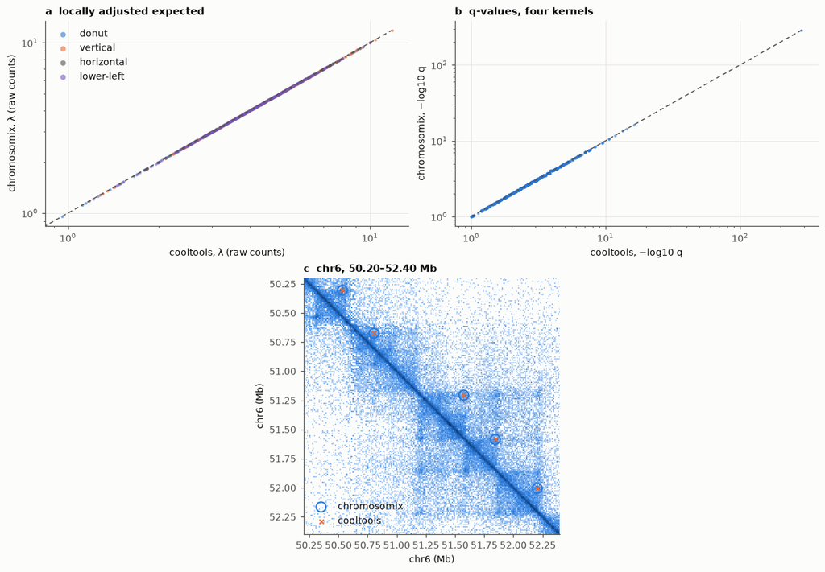

Figure 20: Loop calling, mouse Hi-C at 10 kb. a, the four locally adjusted expecteds of every loop both call; b, their q-values; c, the 2 Mb stretch that holds the most of them, with 100 kb either side, both call sets over the balanced map.

```python
TEXT['lc_n'] = f'{len(both_dots):,}'
TEXT['lc_only'] = f"{int((dots['_merge'] != 'both').sum())}"
TEXT['lc_lam'] = f'{lc_lam:.1e}'
TEXT['lc_q'] = f'{lc_q:.1e}'
TEXT['lc_q_small'] = f'{lc_q_small:.1e}'

fig = plt.figure(figsize=(11, 7.6), layout='constrained')
grid = fig.add_gridspec(2, 2, height_ratios=[1, 1.25])
ax = fig.add_subplot(grid[0, 0])
for k, colour in zip(KERNELS, (APP_COLOUR, REF, INK2, '#7c56c2')):
    ax.scatter(both_dots[f'la_exp.{k}.value'], both_dots[k], s=7, color=colour, alpha=0.6, lw=0,
               label=KERNEL_NAMES[k])
identity(ax, lam_ref.min(), lam_ref.max())
ax.set(xscale='log', yscale='log', xlabel='cooltools, λ (raw counts)', ylabel='chromosomix, λ (raw counts)',
       title='a  locally adjusted expected')
ax.legend(loc='upper left', markerscale=2)
ax = fig.add_subplot(grid[0, 1])
seen = q_ref > 0
ax.scatter(-np.log10(q_ref[seen]), -np.log10(q_app[seen]), s=7, color=APP_COLOUR, alpha=0.6, lw=0)
identity(ax, -np.log10(q_ref[seen].max()), -np.log10(q_ref[seen].min()))
ax.set(xscale='log', yscale='log', xlabel='cooltools, −log10 q', ylabel='chromosomix, −log10 q',
       title='b  q-values, four kernels')
# The 2 Mb that hold the most loops both call, from one of them.
LC_SPAN = 2_000_000
busiest = max(((chrom, start) for chrom, start in both_dots[['sequence', 'start1']].itertuples(index=False)),
              key=lambda at: ((both_dots['sequence'] == at[0]) & (both_dots['start1'] >= at[1])
                              & (both_dots['start2'] < at[1] + LC_SPAN)).sum())
chrom, first = busiest
# Drawn with 100 kb either side, so that no loop sits on the frame.
lo, hi = max(0, first - 100_000), min(int(clr10.chromsizes[chrom]), first + LC_SPAN + 100_000)
held = clr10.matrix(balance=True).fetch(f'{chrom}:{lo}-{hi}')
ax = fig.add_subplot(grid[1, :])
ax.imshow(np.where(held > 0, held, np.nan), cmap=DENSITY, norm=LogNorm(), interpolation='nearest',
          extent=(lo / 1e6, hi / 1e6, hi / 1e6, lo / 1e6))
ax.grid(False)
inside = lambda frame: frame[(frame['sequence'] == chrom) & (frame['start1'] >= lo) & (frame['start2'] < hi)]
mine, theirs = inside(app_dots), inside(ref_dots)
ax.scatter((mine['start2'] + 5_000) / 1e6, (mine['start1'] + 5_000) / 1e6, s=90, facecolors='none',
           edgecolors=APP_COLOUR, lw=1.4, label='chromosomix')
ax.scatter((theirs['start2'] + 5_000) / 1e6, (theirs['start1'] + 5_000) / 1e6, s=18, marker='x', color=REF,
           lw=1.2, label='cooltools')
ax.set(xlabel=f'{chrom} (Mb)', ylabel=f'{chrom} (Mb)', title=f'c  {chrom}, {lo / 1e6:.2f}–{hi / 1e6:.2f} Mb')
ax.set_aspect('equal')
ax.legend(loc='lower left')
drawn('fig-loopcalling')
```

236 loops at the same bin pairs (0 in one only), with the same contacts and the same cluster sizes; the locally adjusted expecteds within 5.0e-05 and the q-values within 5.0e-05 — and, below 10⁻⁴, within 3.2e-06 of their own size — which is the rounding of the digits chromosomix writes.

```python
record('Loop calling', 'mouse Hi-C, 10 kb, every chromosome', f"cooltools {VERSIONS['cooltools']}",
       f"{TEXT['lc_n']} loops, the same bin pairs, contacts and clusters; λ within {TEXT['lc_lam']}, q within "
       f"{TEXT['lc_q']}, the digits written",
       'Identical (to the digits written)' if LC_EXACT else 'Differs', apps=['loops'], refs=['cooltools-dots'])
```

## 20 · Cis and trans per sequence (cooltools)

Per sequence, its contacts with both ends on it (cis) and with one end elsewhere (trans), the cis fraction and the ratio of the two; between every pair of sequences, their contacts, and those over what indifference predicts from the two sequences’ own trans contacts, `T_a·T_b/2T`, scaled so that the expectation sums to the trans contacts there are (§18.8). cooltools has no such task, but its two summaries hold every one of those sums: `expected_cis`, added up over every diagonal of a sequence, the main one included, is the sequence’s cis contacts, and `expected_trans` the contacts between each pair; the ratio to indifference is NumPy’s, over cooltools’ sums. The first of § 7’s chicken maps at 100 kb, its 36 sequences running from the macrochromosomes to microchromosomes a few bins long, raw and balanced. The table per sequence is written to whole contacts and three decimals and the square between sequences to six digits, so the contacts between two sequences are compared in the square, drawn with `--normalise raw`, those within one in the table, and the ratio to indifference in the square the task draws by default.

|  | chromosomix | cooltools |
| --- | --- | --- |
| within a sequence | `cistrans`, its table | `expected_cis(ignore_diags=0)`, every diagonal of the sequence added up |
| between two | its square, `--normalise raw` | `expected_trans` |
| counts | raw (`--no-balance`) and balanced (the default) | `clr_weight_name=None`, and `'weight'` |
| against indifference | its square, `--normalise enrichment` (the default) | NumPy over `expected_trans`’s sums |

```python
CT = WORK / 'cistrans'
CHICKEN_100K = URIS[LABELS[0]]
clr_ch = cooler.Cooler(f'{CHICKEN[0]}::/resolutions/{RES}')
SEQUENCES = clr_ch.chromnames
#: name: (label, chromosomix's arguments).
CT_RUNS = {'raw': ('raw counts', ['--no-balance', '--normalise', 'raw']),
           'balanced': ('balanced', ['--normalise', 'raw']),
           'indifference': ('balanced, against indifference', [])}
for key, (label, extra) in CT_RUNS.items():
    mr('cistrans', CHICKEN_100K, *extra, out=CT / key, name=f'cistrans-{key}', analysis='Cis and trans per sequence',
       label=label, bench=False)
for kind, weight in (('raw', []), ('balanced', ['weight'])):
    reference(f'cooltools-cistrans-{kind}', 'Cis and trans per sequence', 'cooltools',
              [PYTHON, script('cooltools_cistrans'), CHICKEN_100K, OUT, THREADS, *weight],
              out=CT / f'cooltools-{kind}.tsv', label=kind, threads=THREADS, bench=False)


def sums(kind):
    """cooltools' sums as one square, the sequences in the file's order: cis on the diagonal, the pairs off it."""
    at = {name: i for i, name in enumerate(SEQUENCES)}
    held = np.zeros((len(SEQUENCES), len(SEQUENCES)))
    for a, b, contacts in pd.read_csv(CT / f'cooltools-{kind}.tsv', sep='\t').itertuples(index=False):
        held[at[a], at[b]] = held[at[b], at[a]] = 0 if np.isnan(contacts) else contacts
    return held


def against_indifference(held):
    """Each pair's contacts over `T_a·T_b/2T`, scaled to sum to the trans contacts there are (§18.8)."""
    between = held - np.diag(np.diag(held))
    trans = between.sum(axis=1)
    total = trans.sum() / 2
    expected = 4 * total ** 2 / (4 * total ** 2 - (trans ** 2).sum()) * np.outer(trans, trans) / (2 * total)
    with np.errstate(invalid='ignore', divide='ignore'):
        ratio = np.where(expected > 0, between / expected, np.nan)
    np.fill_diagonal(ratio, np.nan)
    return ratio


def drawn_square(key):
    """The square chromosomix wrote, in the file's order of sequences."""
    frame = table(one(CT / key, '*.cistrans-matrix.tsv'))
    return frame.set_index(frame.columns[0]).loc[SEQUENCES, SEQUENCES].to_numpy(float)


BINS_CH = np.array([np.diff(clr_ch.extent(name))[0] for name in SEQUENCES])
OFF = ~np.eye(len(SEQUENCES), dtype=bool)
ct = {}
for kind in ('raw', 'balanced'):
    held = sums(kind)
    cis = np.diag(held).copy()
    trans = (held - np.diag(cis)).sum(axis=1)
    rows = table(one(CT / kind, '*.cistrans.tsv')).set_index('sequence').loc[SEQUENCES]
    with np.errstate(invalid='ignore', divide='ignore'):
        shares = {'fraction': np.where(cis + trans > 0, cis / (cis + trans), np.nan),
                  'ratio': np.where(cis > 0, trans / cis, np.nan), 'perBin': (cis + trans) / BINS_CH}
    pairs = drawn_square(kind)
    ct[kind] = dict(held=held, cis=cis, trans=trans, rows=rows, pairs=pairs, fraction=shares['fraction'],
                    bins=bool((rows['bins'].to_numpy() == BINS_CH).all()),
                    sums=max(np.abs(rows[column].to_numpy(float) - value).max()
                             for column, value in (('cis', cis), ('trans', trans), ('total', cis + trans))),
                    shares={column: np.nanmax(np.abs(rows[column].to_numpy(float) - value))
                            for column, value in shares.items()},
                    shares_gaps=all((np.isfinite(rows[column].to_numpy(float)) == np.isfinite(value)).all()
                                    for column, value in shares.items()),
                    between=relative_difference(pairs[OFF], held[OFF]).max())
oe_app, oe_ref = drawn_square('indifference'), against_indifference(ct['balanced']['held'])
oe_both = np.isfinite(oe_app) & np.isfinite(oe_ref)
oe_rel = relative_difference(oe_app[oe_both], oe_ref[oe_both]).max()
OE_GAPS = bool((np.isfinite(oe_app) == np.isfinite(oe_ref)).all())
raw_, bal_ = ct['raw'], ct['balanced']
measures({
    'sequences; their bins as the file has them': f"{len(SEQUENCES)}; {'yes' if raw_['bins'] and bal_['bins'] else 'no'}",
    'raw: cis, trans and total of every sequence, max |difference|': f"{raw_['sums']:g}",
    'raw: contacts between two sequences, max relative difference': f"{raw_['between']:.1e}",
    'balanced: cis, trans and total, max |difference| (whole contacts written)': f"{bal_['sums']:.2f}",
    'balanced: contacts between two sequences, max relative difference': f"{bal_['between']:.1e}",
    'cis fraction, trans / cis, contacts per bin: max |difference| (3, 3 and 2 decimals written)':
        ', '.join(f"{max(raw_['shares'][c], bal_['shares'][c]):.1e}" for c in ('fraction', 'ratio', 'perBin')),
    'against indifference, max relative difference; the same pairs without a value':
        f"{oe_rel:.1e}; {'yes' if OE_GAPS else 'no'}",
})
```

```
$ chromosomix cistrans data/4DNFIH8L6WON.mcool::/resolutions/100000 --no-balance --normalise raw --out cistrans/raw
$ chromosomix cistrans data/4DNFIH8L6WON.mcool::/resolutions/100000 --normalise raw --out cistrans/balanced
$ chromosomix cistrans data/4DNFIH8L6WON.mcool::/resolutions/100000 --out cistrans/indifference
$ python ../../scripts/cooltools_cistrans.py data/4DNFIH8L6WON.mcool::/resolutions/100000 cistrans/cooltools-raw.tsv 4
$ python ../../scripts/cooltools_cistrans.py data/4DNFIH8L6WON.mcool::/resolutions/100000 cistrans/cooltools-balanced.tsv 4 weight
```

| measure | value |
| --- | --- |
| sequences; their bins as the file has them | 36; yes |
| raw: cis, trans and total of every sequence, max \|difference\| | 0 |
| raw: contacts between two sequences, max relative difference | 0.0e+00 |
| balanced: cis, trans and total, max \|difference\| (whole contacts written) | 0.50 |
| balanced: contacts between two sequences, max relative difference | 4.6e-06 |
| cis fraction, trans / cis, contacts per bin: max \|difference\| (3, 3 and 2 decimals written) | 5.0e-04, 5.0e-04, 5.0e-03 |
| against indifference, max relative difference; the same pairs without a value | 4.6e-06; yes |

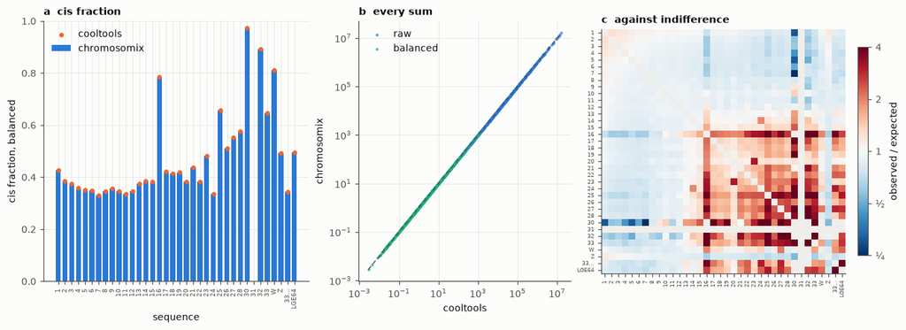

Figure 21: Cis and trans per sequence, chicken Hi-C at 100 kb, the sequences in the file’s order. a, the cis fraction of every sequence, balanced; b, every sum, raw and balanced — a sequence’s cis and trans contacts and the contacts between every pair — against cooltools’; c, every pair against indifference, as chromosomix draws it.

```python
TEXT['ct_n'] = f'{len(SEQUENCES)}'
TEXT['ct_pairs'] = f'{len(SEQUENCES) * (len(SEQUENCES) - 1) // 2:,}'
TEXT['ct_raw'] = 'the same' if raw_['sums'] == 0 and raw_['between'] == 0 else 'not the same'
TEXT['ct_bal_sums'] = f"{bal_['sums']:.2f}"
TEXT['ct_bal_pairs'] = f"{bal_['between']:.1e}"
TEXT['ct_oe'] = f'{oe_rel:.1e}'
TEXT['ct_oe_gaps'] = ('the same pairs left without one' if OE_GAPS else 'different pairs left without one')
CT_EXACT = (raw_['sums'] == 0 and raw_['between'] == 0 and bal_['sums'] <= rounded(0) and bal_['between'] < 6e-6
            and all(ct[k]['shares']['fraction'] <= rounded(3) and ct[k]['shares']['ratio'] <= rounded(3)
                    and ct[k]['shares']['perBin'] <= rounded(2) and ct[k]['shares_gaps'] and ct[k]['bins'] for k in ct)
            and oe_rel < 6e-6 and OE_GAPS)
#: A sequence's name on an axis: `chr` dropped, and an unplaced scaffold's long tail.
SHORT_SEQ = [name.removeprefix('chr').split('_')[0] + ('…' if '_' in name else '') for name in SEQUENCES]
# The microchromosomes, chr16 on, and the five largest, against indifference.
numbered = {int(name[3:]): i for i, name in enumerate(SEQUENCES) if name[3:].isdigit()}
MACRO, MICRO = [numbered[k] for k in range(1, 6)], [i for k, i in numbered.items() if k >= 16]
TEXT['ct_micro'] = f'{np.nanmedian(oe_app[np.ix_(MICRO, MICRO)]):.2f}'
TEXT['ct_macro_micro'] = f'{np.nanmedian(oe_app[np.ix_(MACRO, MICRO)]):.2f}'

fig, axes = plt.subplots(1, 3, figsize=(12, 4.3), layout='constrained', width_ratios=[1.25, 1, 1.15])
ax = axes[0]
x = np.arange(len(SEQUENCES))
ax.bar(x, bal_['rows']['fraction'].to_numpy(float), width=0.75, color=APP_COLOUR, label='chromosomix')
ax.scatter(x, bal_['fraction'], s=12, color=REF, zorder=3, label='cooltools')
ax.set_xticks(x, SHORT_SEQ, rotation=90, fontsize=6)
ax.set(ylim=(0, 1), xlabel='sequence', ylabel='cis fraction, balanced', title='a  cis fraction')
ax.legend(loc='upper left')
ax = axes[1]
upper = np.triu(OFF)
for kind, colour in (('raw', APP_COLOUR), ('balanced', '#1baf7a')):
    v = ct[kind]
    ref_all = np.r_[v['cis'], v['trans'], v['held'][upper]]
    app_all = np.r_[v['rows']['cis'].to_numpy(float), v['rows']['trans'].to_numpy(float), v['pairs'][upper]]
    seen = (ref_all > 0) & (app_all > 0)
    ax.scatter(ref_all[seen], app_all[seen], s=8, color=colour, alpha=0.7, lw=0, label=kind)
every_sum = np.concatenate([np.r_[ct[k]['cis'], ct[k]['trans'], ct[k]['held'][upper]] for k in ct])
identity(ax, every_sum[every_sum > 0].min(), every_sum.max())
ax.set(xscale='log', yscale='log', xlabel='cooltools', ylabel='chromosomix', title='b  every sum')
ax.legend(loc='upper left')
ax = axes[2]
diverging = plt.get_cmap('RdBu_r').copy()
diverging.set_bad(MISSING)
bar = square(ax, oe_app, 'c  against indifference', cmap=diverging, norm=LogNorm(1 / 4, 4),
             label='observed / expected')
bar.set_ticks([1 / 4, 1 / 2, 1, 2, 4], labels=['¼', '½', '1', '2', '4'])
bar.minorticks_off()
ax.set_xticks(x, SHORT_SEQ, rotation=90, fontsize=5)
ax.set_yticks(x, SHORT_SEQ, fontsize=5)
drawn('fig-cistrans')
```

Raw, the two tools count the same contacts on each of the 36 sequences and between each of their 630 pairs. Balanced, the table’s sums are within 0.50 of cooltools’, the whole contacts it writes, and the pairs within 4.6e-06, the six digits the square is written to; every cis fraction and ratio is within its three decimals; and against indifference every pair is within 4.6e-06 of NumPy’s over cooltools’ sums, with the same pairs left without one. The square is the karyotype’s: the microchromosomes, chr16 on, meet one another at a median of 1.92 times what indifference predicts, and the five largest chromosomes meet them at 0.81.

```python
record('Cis and trans per sequence', f'chicken Hi-C, 100 kb, {len(SEQUENCES)} sequences, raw and balanced',
       f"cooltools {VERSIONS['cooltools']}",
       f"raw: {TEXT['ct_raw']} contacts within and between every sequence; balanced: the pairs within "
       f"{TEXT['ct_bal_pairs']}; against indifference within {TEXT['ct_oe']} of NumPy over cooltools' sums",
       'Identical (to the digits written)' if CT_EXACT else 'Differs', apps=[f'cistrans-{key}' for key in CT_RUNS],
       refs=['cooltools-cistrans-raw', 'cooltools-cistrans-balanced'])
```

## 21 · Saddle (cooltools)

The saddle § 3’s compartment call draws for each chromosome: its bins in 50 groups at the quantiles of E1 over the chromosome, and the mean observed/expected of every pair of groups, the first two diagonals left out as the call leaves them out; and AA, BB and AB, the means of its corners over the fifth of the groups at each end (§18.8). cooltools’ `saddle`, over each chromosome alone, its expected `expected_cis`‘s unsmoothed `balanced.avg`, is handed chromosomix’s own E1 as its track, from the bigWig chromosomix writes, cut into its groups by cooltools’ `digitize`: what is compared is the saddle, the eigenvector being § 3’s to compare. AA, BB and AB are taken from cooltools’ saddle as chromosomix takes them from its own.

|  | chromosomix | cooltools |
| --- | --- | --- |
| groups | `--quantiles 50` (the default), E1’s quantiles over the chromosome | `digitize(n_bins=50, qrange=(0, 1))`, over the chromosome (`view_df`) |
| diagonals left out | 2 (the default) | `min_diag=2` |
| expected | the chromosome’s decay with distance | `expected_cis(ignore_diags=2, smooth=False)`, `balanced.avg` |
| track | its own E1 | chromosomix’s E1, from its bigWig |

```python
SD = WORK / 'saddle'
SD.mkdir(parents=True, exist_ok=True)
SADDLE_GROUPS = 50
# chromosomix's E1 from the bigWig it writes, a float32 a bin, where its table keeps six digits: two
# bins six digits cannot tell apart may lie either side of a group's edge. As cooltools reads a track,
# and under a name that changes with it, so that the reference runs again when the eigenvector does.
handle = pyBigWig.open(str(one(CMP / 'app', '*.compartment-e1.bw')))
e1_held = {(chrom, start): value
           for chrom in handle.chroms() for start, _, value in handle.intervals(chrom) or ()}
handle.close()
e1_bins = clr100.bins()[['chrom', 'start', 'end']][:]
e1_track = e1_bins.assign(E1=[e1_held.get(at, np.nan) for at in zip(e1_bins['chrom'], e1_bins['start'])]).to_csv(
    sep='\t', index=False)
E1_TRACK = SD / f"e1-{hashlib.sha256(e1_track.encode()).hexdigest()[:12]}.tsv"
if not E1_TRACK.exists():
    E1_TRACK.write_text(e1_track)
reference('cooltools-saddle', 'Saddle', 'cooltools',
          [PYTHON, script('cooltools_saddle'), MOUSE_100K, E1_TRACK, SADDLE_GROUPS, OUT, ','.join(COMPARED)],
          out=SD / 'cooltools.npz', bench=False)

saddles_ref = np.load(SD / 'cooltools.npz')
CORNER = max(1, round(SADDLE_GROUPS / 5))


def corners(cells):
    """AA, BB and AB as chromosomix takes them: each corner's mean over the cells that have a value."""
    k = CORNER
    return {'AA': np.nanmean(cells[-k:, -k:]), 'BB': np.nanmean(cells[:k, :k]), 'AB': np.nanmean(cells[:k, -k:])}


sd, rows = {}, []
for chrom in COMPARED:
    path = one(CMP / 'app', f'*.compartment-saddle-{chrom}.tsv')
    frame = table(path)
    app = frame.set_index(frame.columns[0]).to_numpy(float)
    stated = {k: float(v) for k, v in re.findall(r'^# (AA|BB|AB): (\S+)$', path.read_text(), flags=re.M)}
    ref = saddles_ref[chrom]
    both = np.isfinite(app) & np.isfinite(ref)
    expected_corners = corners(ref)
    sd[chrom] = dict(app=app, stated=stated, corners=expected_corners, rel=relative_difference(app, ref)[both])
    rows.append({'chromosome': chrom, 'the same cells without a value': bool((np.isfinite(app) == np.isfinite(ref)).all()),
                 'max relative difference': sd[chrom]['rel'].max(),
                 **{f'{k}, chromosomix / cooltools': f"{stated[k]:.2f} / {v:.4f}" for k, v in expected_corners.items()}})
saddle_table = pd.DataFrame(rows)
show(saddle_table, **{'max relative difference': '{:.1e}'})
```

```
$ python ../../scripts/cooltools_saddle.py data/4DNFIOZ1TRUS.mcool::/resolutions/100000 saddle/e1-244f1c3d27f2.tsv 50 saddle/cooltools.npz chr1,chr2,chr3,chr4,chr5,chr6,chr7,chr8,chr9,chr10,chr11,chr12,chr13,chr14,chr15,chr16,chr17,chr18,chr19,chrX
```

| chromosome | the same cells without a value | max relative difference | AA, chromosomix / cooltools | BB, chromosomix / cooltools | AB, chromosomix / cooltools |
| --- | --- | --- | --- | --- | --- |
| chr1 | True | 4.6e-06 | 1.90 / 1.9049 | 1.56 / 1.5606 | 0.48 / 0.4799 |
| chr2 | True | 4.9e-06 | 2.22 / 2.2234 | 1.60 / 1.5984 | 0.38 / 0.3793 |
| chr3 | True | 4.9e-06 | 1.71 / 1.7148 | 1.62 / 1.6219 | 0.51 / 0.5103 |
| chr4 | True | 4.7e-06 | 2.01 / 2.0108 | 1.57 / 1.5709 | 0.41 / 0.4106 |
| chr5 | True | 4.8e-06 | 1.84 / 1.8375 | 1.70 / 1.7039 | 0.38 / 0.3827 |
| chr6 | True | 5.0e-06 | 1.71 / 1.7088 | 1.63 / 1.6346 | 0.44 / 0.4353 |
| chr7 | True | 4.9e-06 | 2.02 / 2.0220 | 1.92 / 1.9166 | 0.42 / 0.4215 |
| chr8 | True | 4.8e-06 | 1.87 / 1.8711 | 1.71 / 1.7050 | 0.46 / 0.4623 |
| chr9 | True | 4.8e-06 | 1.67 / 1.6660 | 1.87 / 1.8708 | 0.47 / 0.4735 |
| chr10 | True | 4.8e-06 | 1.76 / 1.7573 | 1.73 / 1.7261 | 0.47 / 0.4679 |
| chr11 | True | 4.9e-06 | 1.89 / 1.8886 | 2.01 / 2.0092 | 0.39 / 0.3938 |
| chr12 | True | 5.0e-06 | 1.81 / 1.8119 | 1.63 / 1.6302 | 0.50 / 0.4965 |
| chr13 | True | 4.9e-06 | 1.47 / 1.4725 | 1.73 / 1.7276 | 0.48 / 0.4785 |
| chr14 | True | 4.9e-06 | 1.70 / 1.7015 | 1.68 / 1.6754 | 0.50 / 0.5018 |
| chr15 | True | 4.6e-06 | 1.50 / 1.4955 | 1.83 / 1.8259 | 0.38 / 0.3825 |
| chr16 | True | 4.8e-06 | 1.75 / 1.7492 | 1.58 / 1.5774 | 0.50 / 0.5044 |
| chr17 | True | 4.9e-06 | 1.65 / 1.6532 | 1.94 / 1.9435 | 0.38 / 0.3818 |
| chr18 | True | 4.9e-06 | 1.62 / 1.6153 | 1.74 / 1.7377 | 0.51 / 0.5117 |
| chr19 | True | 4.8e-06 | 1.49 / 1.4910 | 1.95 / 1.9511 | 0.42 / 0.4172 |
| chrX | True | 4.9e-06 | 1.58 / 1.5806 | 0.98 / 0.9808 | 0.75 / 0.7453 |

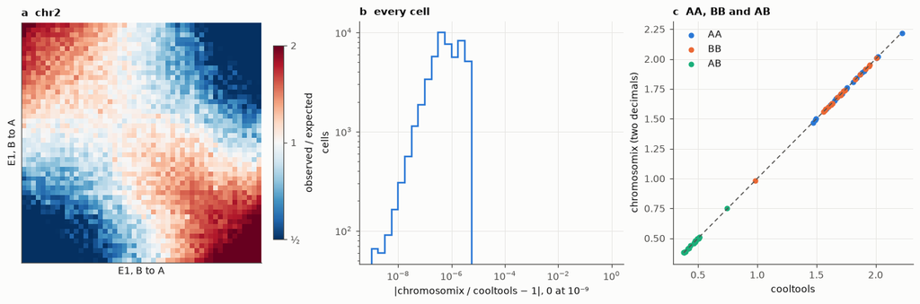

Figure 22: Saddles, mouse Hi-C at 100 kb, by chromosomix’s E1. a, chr2’s, as chromosomix draws it; b, every cell of every chromosome’s against cooltools’; c, the three corners of every chromosome.

```python
TEXT['sd_n'] = f'{len(COMPARED)}'
TEXT['sd_rel'] = f"{saddle_table['max relative difference'].max():.1e}"
corner_gap = max(abs(v['stated'][k] - v['corners'][k]) for v in sd.values() for k in ('AA', 'BB', 'AB'))
TEXT['sd_corners'] = f'{corner_gap:.1e}'
SADDLE_GAPS = saddle_table['the same cells without a value'].all()
TEXT['sd_gaps'] = 'the same cells' if SADDLE_GAPS else 'not the same cells'
SADDLE_EXACT = SADDLE_GAPS and saddle_table['max relative difference'].max() < 6e-6 and corner_gap <= rounded(2)

fig, axes = plt.subplots(1, 3, figsize=(12, 3.9), layout='constrained', width_ratios=[1, 1.1, 1])
diverging = plt.get_cmap('RdBu_r').copy()
diverging.set_bad(MISSING)
bar = square(axes[0], sd['chr2']['app'], 'a  chr2', cmap=diverging, norm=LogNorm(1 / 2, 2), label='observed / expected')
bar.set_ticks([1 / 2, 1, 2], labels=['½', '1', '2'])
bar.minorticks_off()
axes[0].set(xlabel='E1, B to A', ylabel='E1, B to A')
ax = axes[1]
ax.stairs(*differences(np.concatenate([v['rel'] for v in sd.values()])), color=APP_COLOUR, lw=1.6,
          label='every cell')
ax.set(xscale='log', yscale='log', xlabel='|chromosomix / cooltools − 1|, 0 at 10⁻⁹', ylabel='cells',
       title='b  every cell')
ax = axes[2]
for name, colour in (('AA', APP_COLOUR), ('BB', REF), ('AB', '#1baf7a')):
    ax.scatter([v['corners'][name] for v in sd.values()], [v['stated'][name] for v in sd.values()], s=18,
               color=colour, label=name, zorder=3)
every_corner = [v['corners'][k] for v in sd.values() for k in ('AA', 'BB', 'AB')]
identity(ax, min(every_corner), max(every_corner))
ax.set(xlabel='cooltools', ylabel='chromosomix (two decimals)', title='c  AA, BB and AB')
ax.legend(loc='upper left')
drawn('fig-saddle')
```

Every cell of the 20 chromosomes’ saddles agrees with cooltools’ within 5.0e-06, the six digits chromosomix writes, with the same cells left without a value, and AA, BB and AB within 5.0e-03, their two decimals.

```python
record('Saddle', f"mouse Hi-C, 100 kb, § 3's E1, {len(COMPARED)} chromosomes", f"cooltools {VERSIONS['cooltools']}",
       f"every cell within {TEXT['sd_rel']}, the corners within {TEXT['sd_corners']}",
       'Identical (float32)' if SADDLE_EXACT else 'Differs',
       apps=['compartments'], refs=['cooltools-saddle'])
```

## 22 · Fraction of signal in features (pyBigWig)

ChIP-seq’s FRiP, over a track: the signal inside a set of intervals over the whole of it, the signal being an area, value × bases, and the intervals merged first so that a base two of them share counts once; beside it, the share of the sequences’ bases the set covers, and the enrichment, their ratio (§18.8). The reference is pyBigWig’s exact sum over each interval, `stats(..., type='sum', exact=True)`, and NumPy. § 5’s two ATAC-seq replicates on chr19, over two sets: § 5’s peaks, yapc’s at IDR ≤ 0.05, and § 15’s promoters, which overlap wherever two transcripts start alike — and every feature of each on its own (`--perFeature`), its signal and its mean over the bases with a value. chromosomix reads the features finely, at a fiftieth of their median width, and the whole track coarsely, at a two hundred-thousandth of the assembly, from a zoom level where the file has one that fine: away from a boundary, a sum weighted by span is the same area at any resolution, and a whole sequence has almost no boundaries.

|  | chromosomix | pyBigWig and NumPy |
| --- | --- | --- |
| features | merged where they overlap or touch | merged likewise, as `bedtools merge` merges them |
| signal | Σ value × bases, read at a fiftieth of the features’ median width | `stats(..., type='sum', exact=True)` |
| the whole track | read at a two hundred-thousandth of the assembly | the same exact sum, over every sequence the header declares |
| each feature | `--perFeature`: its signal, and its mean over the bases with a value | `type='sum'`, `type='mean'`, exact |

```python
FR = WORK / 'frip'
#: name: (label, the feature set).
FRIP_SETS = {'peaks': ('ATAC-seq peaks', PEAKS_BED), 'promoters': ('promoters', PROMOTERS)}
for key, (label, bed) in FRIP_SETS.items():
    mr('frip', '--tracks', ','.join(rel(path) for path in REPS), '--features', bed, '--perFeature', out=FR / key,
       name=f'frip-{key}', analysis='Fraction of signal in features', label=label, bench=False)
    reference(f'pybigwig-frip-{key}', 'Fraction of signal in features', 'pyBigWig, NumPy',
              [PYTHON, script('pybigwig_frip'), bed, OUT, *REPS], out=FR / f'pybigwig-{key}',
              made=FR / f'pybigwig-{key}-frip.tsv', label=label, bench=False)

#: The columns of a FRiP chromosomix writes, and the places it writes each to.
FRIP_PLACES = {'frip': 4, 'covered': 4, 'enrichment': 2, 'inFeature': 3}
KEYS = ['track', 'contig', 'start', 'end']
REPLICATE = {track_name(path.name): f'rep. {k + 1}' for k, path in enumerate(REPS)}
fr, rows = {}, []
for key, (label, bed) in FRIP_SETS.items():
    app = table(one(FR / key, '*.frip.tsv')).set_index('track')
    ref = (pd.read_csv(FR / f'pybigwig-{key}-frip.tsv', sep='\t').assign(track=lambda f: f['track'].map(track_name))
           .set_index('track').loc[app.index])
    total = relative_difference(app['totalSignal'].to_numpy(float), ref['totalSignal'].to_numpy(float))
    # Every feature by its track and coordinates; one written twice is the same numbers twice.
    each = (table(one(FR / key, '*.frip-features.tsv')).drop_duplicates(KEYS)
            .merge(pd.read_csv(FR / f'pybigwig-{key}-features.tsv', sep='\t')
                   .assign(track=lambda f: f['track'].map(track_name)).drop_duplicates(KEYS), on=KEYS,
                   how='outer', suffixes=('_app', '_ref'), indicator=True))
    paired = each[each['_merge'] == 'both']
    signal_gap = np.abs(paired['signal_app'] - paired['signal_ref'])
    mean_gap = np.abs(paired['mean_app'] - paired['mean_ref'])
    gaps = {column: np.abs(app[column].to_numpy(float) - ref[column].to_numpy(float)) for column in FRIP_PLACES}
    fr[key] = dict(app=app, ref=ref, paired=paired, unpaired=int((each['_merge'] != 'both').sum()),
                   inside=np.abs(app['signal'] - ref['signal']).max(), total=total.max(),
                   places={column: gap.max() for column, gap in gaps.items()},
                   # Each within the places it is written to, once the whole track's own difference, which
                   # moves a FRiP and an enrichment in proportion, is allowed for.
                   within=all((gap <= rounded(FRIP_PLACES[c]) + np.abs(ref[c].to_numpy(float)) * total).all()
                              for c, gap in gaps.items()),
                   # Two decimals and four written, beside the float32 a bigWig holds its values in.
                   features=bool((signal_gap <= rounded(2) + 1e-6 * paired['signal_ref'].abs()).all()
                                 and (mean_gap <= rounded(4) + 1e-6 * paired['mean_ref'].abs()).all()
                                 and (np.isnan(paired['mean_app']) == np.isnan(paired['mean_ref'])).all()),
                   signal_gap=signal_gap.max(), mean_gap=mean_gap.max())
    for track in app.index:
        rows.append({'set': label, 'track': REPLICATE[track], 'FRiP, chromosomix / exact':
                     f"{app.loc[track, 'frip']:.4f} / {ref.loc[track, 'frip']:.6f}",
                     'covered': f"{app.loc[track, 'covered']:.4f} / {ref.loc[track, 'covered']:.6f}",
                     'enrichment': f"{app.loc[track, 'enrichment']:.2f} / {ref.loc[track, 'enrichment']:.4f}",
                     'signal inside, |difference|': abs(app.loc[track, 'signal'] - ref.loc[track, 'signal']),
                     'signal in all, relative difference': relative_difference(app.loc[track, 'totalSignal'],
                                                                               ref.loc[track, 'totalSignal'])})
display(show(pd.DataFrame(rows),
             **{'signal inside, |difference|': '{:.2f}', 'signal in all, relative difference': '{:.1e}'}))
measures({f'{FRIP_SETS[k][0]}: features; unpaired; signal, mean, max |difference| (2 and 4 decimals written)':
          f"{len(v['paired']) // len(REPS):,}; {v['unpaired']}; {v['signal_gap']:.4f}, {v['mean_gap']:.1e}"
          for k, v in fr.items()})
```

```
$ chromosomix frip --tracks data/4DNFIIY4QW2D.chr19.bw,data/4DNFITBRHVZE.chr19.bw --features yapc/seed0/yapc_0.05.bed --perFeature --out frip/peaks
$ python ../../scripts/pybigwig_frip.py yapc/seed0/yapc_0.05.bed frip/pybigwig-peaks data/4DNFIIY4QW2D.chr19.bw data/4DNFITBRHVZE.chr19.bw
$ chromosomix frip --tracks data/4DNFIIY4QW2D.chr19.bw,data/4DNFITBRHVZE.chr19.bw --features overlap/promoters.bed --perFeature --out frip/promoters
$ python ../../scripts/pybigwig_frip.py overlap/promoters.bed frip/pybigwig-promoters data/4DNFIIY4QW2D.chr19.bw data/4DNFITBRHVZE.chr19.bw
```

| set | track | FRiP, chromosomix / exact | covered | enrichment | signal inside, \|difference\| | signal in all, relative difference |
| --- | --- | --- | --- | --- | --- | --- |
| ATAC-seq peaks | rep. 1 | 0.2469 / 0.246876 | 0.0213 / 0.021287 | 11.60 / 11.5974 | 0.34 | 4.8e-05 |
| ATAC-seq peaks | rep. 2 | 0.1991 / 0.199055 | 0.0213 / 0.021287 | 9.35 / 9.3509 | 0.24 | 4.4e-05 |
| promoters | rep. 1 | 0.1136 / 0.113576 | 0.0257 / 0.025679 | 4.42 / 4.4229 | 0.08 | 4.8e-05 |
| promoters | rep. 2 | 0.0955 / 0.095458 | 0.0257 / 0.025679 | 3.72 / 3.7173 | 0.17 | 4.4e-05 |

| measure | value |
| --- | --- |
| ATAC-seq peaks: features; unpaired; signal, mean, max \|difference\| (2 and 4 decimals written) | 5,666; 0; 0.0050, 5.0e-05 |
| promoters: features; unpaired; signal, mean, max \|difference\| (2 and 4 decimals written) | 887; 0; 0.0050, 5.0e-05 |

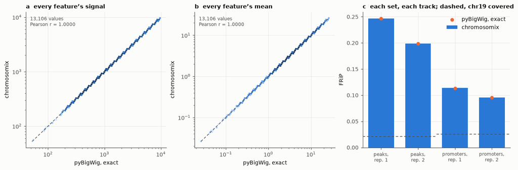

Figure 23: FRiP of two mouse ATAC-seq replicates on chr19. a, every feature’s signal, both sets and both tracks, against pyBigWig’s exact sum; b, every feature’s mean over the bases with a value; c, the FRiP of each track over each set, and the share of chr19 the set covers.

```python
TEXT['fr_features'] = f"{sum(len(v['paired']) for v in fr.values()) // len(REPS):,}"
TEXT['fr_inside'] = f"{max(v['inside'] for v in fr.values()):.2f}"
TEXT['fr_total'] = f"{max(v['total'] for v in fr.values()):.1e}"
TEXT['fr_frip'] = f"{max(v['places']['frip'] for v in fr.values()):.1e}"
FRIP_EXACT = all(v['inside'] <= rounded(0) and v['features'] and v['unpaired'] == 0 and v['within']
                 for v in fr.values())
TEXT['fr_places'] = 'every one' if FRIP_EXACT else 'not every one'

fig, axes = plt.subplots(1, 3, figsize=(12, 3.9), layout='constrained', width_ratios=[1, 1, 1.05])
every = pd.concat([v['paired'] for v in fr.values()])
agreement(axes[0], every['signal_ref'].to_numpy(float), every['signal_app'].to_numpy(float), 'pyBigWig, exact',
          'chromosomix', 'a  every feature’s signal', scale='log')
agreement(axes[1], every['mean_ref'].to_numpy(float), every['mean_app'].to_numpy(float), 'pyBigWig, exact',
          'chromosomix', 'b  every feature’s mean', scale='log')
ax = axes[2]
at = 0
ticks, names = [], []
for key, (label, _) in FRIP_SETS.items():
    v = fr[key]
    for track in v['app'].index:
        ax.bar(at, v['app'].loc[track, 'frip'], width=0.7, color=APP_COLOUR,
               label='chromosomix' if at == 0 else None, gid='chromosomix')
        ax.scatter(at, v['ref'].loc[track, 'frip'], s=26, color=REF, zorder=3,
                   label='pyBigWig, exact' if at == 0 else None, gid='pyBigWig, exact')
        ticks.append(at)
        names.append(f"{key},\n{REPLICATE[track]}")
        at += 1
    ax.axhline(v['app']['covered'].iloc[0], xmin=(at - 2) / 4, xmax=at / 4, color=INK2, lw=1, ls=(0, (4, 3)),
               gid=f'{label}: the share of chr19 covered')
ax.set_xticks(ticks, names, fontsize=8)
ax.set(xlim=(-0.5, at - 0.5), ylabel='FRiP', title='c  each set, each track; dashed, chr19 covered')
ax.legend(loc='upper right')
drawn('fig-frip')
```

Every one of the 6,553 features has its signal and its mean on both tracks within the rounding of the two and four decimals chromosomix writes them to, and inside the merged features the signal is pyBigWig’s exact sum within 0.34, the rounding of the whole number it is written as. The whole track, read from a zoom level, is within 4.8e-05 of its exact sum, which moves a FRiP by less than the last of its four decimals: every one of the FRiPs, the shares covered and the enrichments is within the rounding of the places it is written to, the FRiP within 4.5e-05.

```python
record('Fraction of signal in features', 'mouse ATAC-seq, 2 replicates, chr19; § 5’s peaks and § 15’s promoters',
       f"pyBigWig {VERSIONS['pyBigWig']}, NumPy {VERSIONS['numpy']}",
       f"every feature's signal and mean to the digits written; inside, the exact sum; the whole track, from a "
       f"zoom level, within {TEXT['fr_total']}; FRiP within {TEXT['fr_frip']}",
       'The same FRiP to its four decimals and every feature to the digits written, the whole track read from a '
       'zoom level' if FRIP_EXACT else 'Differs',
       apps=[f'frip-{key}' for key in FRIP_SETS], refs=[f'pybigwig-frip-{key}' for key in FRIP_SETS])
```

## 23 · Signal by group (pyBigWig and SciPy)

A track compared between groups of the genome (§18.8): the groups are a feature set’s names and the stretch of the genome it does not cover, each cut on the bin grid into stretches of at most a bin; a stretch’s value is the track’s exact mean over the bases it has a value for; and the groups are summarised and tested by ranks — Mann–Whitney pair by pair and Kruskal–Wallis over all of them, every P adjusted with every other (Benjamini–Hochberg). The groups are § 3’s compartment call on chr19, A and B, and the rest of chr19, which the call leaves out; the tracks are § 5’s two ATAC-seq replicates. The reference cuts the stretches by the same rule, reads each one’s mean with pyBigWig, and summarises and tests them with NumPy and SciPy. chromosomix writes every stretch’s mean, a group’s ascending, as the violin it draws, and those are compared with the reference’s rank for rank in each group; its summaries and tests are compared with NumPy’s and SciPy’s, each to the places it is written to.

|  | chromosomix | pyBigWig, NumPy and SciPy |
| --- | --- | --- |
| groups | `--features`, § 3’s call, `--split name`; the rest of chr19 (`--outside`, the default) | the BED’s names; what it does not cover |
| stretches | at most a bin, `--resolution 10000` | cut by the same rule |
| a stretch’s value | its mean, at the track’s own resolution | `stats(..., type='mean', exact=True)` |
| summaries | n, mean, SD, median, quartiles, the mean less the others’ | NumPy: `std(ddof=1)`, `quantile` |
| tests | Mann–Whitney, Kruskal–Wallis, tie-corrected; Benjamini–Hochberg | `mannwhitneyu` (asymptotic, continuity-corrected), `kruskal`; `false_discovery_control` |

```python
GS = WORK / 'groupsignal'
GS.mkdir(parents=True, exist_ok=True)
GS_BIN = 10_000
# § 3's compartment call, under a name that changes with it, so that the reference runs again when it does.
ab_call = one(CMP / 'app', '*.compartment-ab.bed').read_text()
AB_CALL = GS / f"ab-{hashlib.sha256(ab_call.encode()).hexdigest()[:12]}.bed"
if not AB_CALL.exists():
    AB_CALL.write_text(ab_call)
mr('groupsignal', '--tracks', ','.join(rel(path) for path in REPS), '--features', AB_CALL, '--split', 'name',
   '--resolution', GS_BIN, out=GS / 'app', name='groupsignal', analysis='Signal by group', bench=False)
reference('pybigwig-groupsignal', 'Signal by group', 'pyBigWig, SciPy',
          [PYTHON, script('pybigwig_groupsignal'), AB_CALL, GS_BIN, OUT, *REPS], out=GS / 'reference',
          made=GS / 'reference-tests.tsv', bench=False)

groups_app = table(one(GS / 'app', '*.groupsignal-groups.tsv'))
tests_app = table(one(GS / 'app', '*.groupsignal-tests.tsv')).fillna({'b': ''})
groups_ref = pd.read_csv(GS / 'reference-groups.tsv', sep='\t').assign(track=lambda f: f['track'].map(track_name))
tests_ref = (pd.read_csv(GS / 'reference-tests.tsv', sep='\t').fillna({'b': ''})
             .assign(track=lambda f: f['track'].map(track_name)))
exact = pd.read_csv(GS / 'reference-stretches.tsv', sep='\t').rename(columns=track_name)


def violin_values(path):
    """A violin as chromosomix writes it: its track, and every stretch's mean a group, ascending."""
    frame = table(path)
    track = re.search(r'^# output: (.+?) by ', path.read_text(), flags=re.M).group(1)
    return track, {name: frame[name].dropna().to_numpy(float) for name in frame.columns[1:]}


def significant(digits):
    """How far rounding to `digits` significant digits moves a number, relative to it, and a hair over."""
    return 0.5 * 10.0 ** (1 - digits) * (1 + 1e-6)


VALUES = dict(violin_values(path) for path in sorted((GS / 'app').glob('*.groupsignal-[0-9]*.tsv')))
#: Each column chromosomix writes and how near the reference has to be: the places it is written to, and P
#: and q, written in scientific notation, to their six significant digits.
GROUP_COLUMNS = {'mean': rounded(4), 'sd': rounded(4), 'median': rounded(4), 'q1': rounded(4), 'q3': rounded(4),
                 'vsRest': rounded(4)}
TEST_COLUMNS = {'difference': rounded(4), 'effect': rounded(3), 'statistic': rounded(2), 'p': significant(6),
                'q': significant(6)}


def against(app, other, key, columns):
    """Each column's largest difference — P and q relative, the others as written — and whether every one
    is near enough."""
    paired = app.merge(other, on=key, suffixes=('', '_other'))
    out = {}
    for column, near in columns.items():
        mine, theirs = paired[column].to_numpy(float), paired[f'{column}_other'].to_numpy(float)
        gap = relative_difference(mine, theirs) if column in ('p', 'q') else np.abs(mine - theirs)
        gap = np.nan_to_num(gap, nan=0.0)
        out[column] = (np.max(gap), bool((gap <= near).all()))
    return out, len(paired)


held_groups, n_groups = against(groups_app, groups_ref, ['track', 'group'], GROUP_COLUMNS)
held_tests, n_tests = against(tests_app, tests_ref, ['track', 'test', 'a', 'b'], TEST_COLUMNS)
HELD = held_groups | held_tests


def exact_sorted(track, name):
    """A group's exact stretch means on one track, ascending, as chromosomix's violins write its own."""
    return np.sort(exact.loc[(exact['group'] == name) & exact[track].notna(), track].to_numpy())


# The stretches, rank for rank in each group: chromosomix's means, its violins, against the exact ones.
rank_gap = np.concatenate([relative_difference(values, exact_sorted(track, name))
                           for track, by_group in VALUES.items() for name, values in by_group.items()])
same_counts = bool((groups_app.merge(groups_ref, on=['track', 'group'], suffixes=('', '_ref'))
                    .eval('n == n_ref and bases == bases_ref')).all())
NAMES = list(dict.fromkeys(groups_app['group']))
display(measures({
    'stretches; groups': f"{len(exact):,}; {', '.join(NAMES)}",
    'stretches and bases of each group, the same': 'yes' if same_counts else 'no',
    'stretch means, rank for rank: median, max relative difference': f'{np.median(rank_gap):.1e}, {rank_gap.max():.1e}',
}))
show(pd.DataFrame([{'column': column, 'measured': 'relative' if column in ('p', 'q') else 'as written',
                    'near enough': (GROUP_COLUMNS | TEST_COLUMNS)[column], 'max difference': HELD[column][0],
                    'near enough, every one': HELD[column][1]}
                   for column in [*GROUP_COLUMNS, *TEST_COLUMNS]]),
     **{c: '{:.1e}' for c in ('near enough', 'max difference')})
```

```
$ chromosomix groupsignal --tracks data/4DNFIIY4QW2D.chr19.bw,data/4DNFITBRHVZE.chr19.bw --features groupsignal/ab-57fc779d74e6.bed --split name --resolution 10000 --out groupsignal/app
$ python ../../scripts/pybigwig_groupsignal.py groupsignal/ab-57fc779d74e6.bed 10000 groupsignal/reference data/4DNFIIY4QW2D.chr19.bw data/4DNFITBRHVZE.chr19.bw
```

| measure | value |
| --- | --- |
| stretches; groups | 6,143; A, B, rest of the genome |
| stretches and bases of each group, the same | yes |
| stretch means, rank for rank: median, max relative difference | 5.5e-07, 5.0e-06 |

| column | measured | near enough | max difference | near enough, every one |
| --- | --- | --- | --- | --- |
| mean | as written | 5.0e-05 | 4.2e-05 | True |
| sd | as written | 5.0e-05 | 3.8e-05 | True |
| median | as written | 5.0e-05 | 4.0e-05 | True |
| q1 | as written | 5.0e-05 | 2.8e-05 | True |
| q3 | as written | 5.0e-05 | 4.1e-05 | True |
| vsRest | as written | 5.0e-05 | 4.0e-05 | True |
| difference | as written | 5.0e-05 | 4.1e-05 | True |
| effect | as written | 5.0e-04 | 3.4e-04 | True |
| statistic | as written | 5.0e-03 | 3.3e-03 | True |
| p | relative | 5.0e-06 | 2.9e-06 | True |
| q | relative | 5.0e-06 | 2.8e-06 | True |

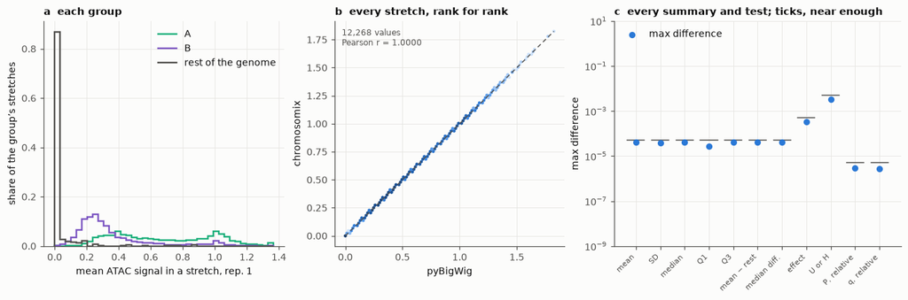

Figure 24: ATAC-seq on chr19 by § 3’s compartments, in stretches of at most 10 kb. a, each group’s stretch means as chromosomix measures them, replicate 1; b, every stretch’s mean, rank for rank in its group, both replicates, against pyBigWig’s; c, every summary and test against NumPy’s and SciPy’s — P and q relative, the others as they are written.

```python
TEXT['gs_n'] = f'{len(exact):,}'
TEXT['gs_rank'] = f'{rank_gap.max():.1e}'
GS_HELD = all(ok for _, ok in HELD.values()) and n_groups == len(groups_app) and n_tests == len(tests_app)
TEXT['gs_held'] = 'every one' if GS_HELD else 'not every one'
GS_EXACT = GS_HELD and same_counts and rank_gap.max() <= significant(6)

fig, axes = plt.subplots(1, 3, figsize=(12, 3.9), layout='constrained', width_ratios=[1.05, 1, 1.25])
ax = axes[0]
first_track = next(iter(VALUES))
edges = np.linspace(0, np.percentile(np.concatenate(list(VALUES[first_track].values())), 99.5), 41)
for name, colour in zip(NAMES, ('#1baf7a', '#7c56c2', INK2)):
    counts, _ = np.histogram(np.clip(VALUES[first_track][name], 0, edges[-1]), edges)
    ax.stairs(counts / counts.sum(), edges, color=colour, lw=1.6, label=name)
ax.set(xlabel=f'mean ATAC signal in a stretch, {REPLICATE[first_track]}', ylabel='share of the group’s stretches',
       title='a  each group')
ax.legend(loc='upper right')
agreement(axes[1], np.concatenate([exact_sorted(track, name) for track, by_group in VALUES.items() for name in by_group]),
          np.concatenate([values for by_group in VALUES.values() for values in by_group.values()]), 'pyBigWig',
          'chromosomix', 'b  every stretch, rank for rank')
ax = axes[2]
columns = [*GROUP_COLUMNS, *TEST_COLUMNS]
for k, column in enumerate(columns):
    ax.scatter(k, max(HELD[column][0], 1e-9), s=26, color=APP_COLOUR, zorder=3,
               label='max difference' if k == 0 else None, gid='max difference')
    near = (GROUP_COLUMNS | TEST_COLUMNS)[column]
    ax.plot([k - 0.35, k + 0.35], [near, near], color=INK2, lw=1, gid='near enough')
ax.set_xticks(range(len(columns)), ['mean', 'SD', 'median', 'Q1', 'Q3', 'mean − rest', 'median diff.', 'effect',
                                    'U or H', 'P, relative', 'q, relative'], fontsize=7, rotation=45, ha='right')
ax.set(yscale='log', ylim=(1e-9, 10), ylabel='max difference', title='c  every summary and test; ticks, near enough')
ax.legend(loc='upper left')
drawn('fig-groupsignal')
```

The two tools cut chr19 into the same 6,143 stretches, the same number in each group and of the same bases, and read the same means from them: rank for rank in each group, chromosomix’s are pyBigWig’s within 5.0e-06, the six digits it writes. NumPy and SciPy give every one of its summaries and tests to the places it writes them — U and H to two decimals, P and q, far below anything a reader acts on, to six significant digits.

```python
record('Signal by group', "mouse ATAC-seq, 2 replicates, chr19, by § 3's compartments; 10 kb stretches",
       f"pyBigWig {VERSIONS['pyBigWig']}, NumPy {VERSIONS['numpy']}, SciPy {VERSIONS['scipy']}",
       f"the same stretches, their means within {TEXT['gs_rank']}; {TEXT['gs_held']} of the summaries and tests "
       "as written",
       'Identical (to the digits written)' if GS_EXACT else 'Differs',
       apps=['groupsignal'], refs=['pybigwig-groupsignal'])
```